# Visualization of Genotyping Results

```r
# Plot A: minor allele rate per strand
sbo_points <- sbo_hm_pairs_ordered %>% # one point per sample and strand
  select(barcode, locus, rate_fwd, rate_rev) %>%
  pivot_longer(c(rate_fwd, rate_rev), names_to = "strand", values_to = "rate") %>%
  mutate(strand = ifelse(strand == "rate_fwd", "FWD", "RV"),
         x = ifelse(strand == "RV", -rate, rate),
         beyond = x < -sbo_axis_rv | x > sbo_axis_fwd,
         x = pmin(pmax(x, -sbo_axis_rv), sbo_axis_fwd))

p_sbo_rates <- ggplot(sbo_loci, aes(y = locus)) +
  geom_vline(xintercept = 0, colour = "grey55") +
  geom_point(data = filter(sbo_points, !beyond), aes(x = x, colour = strand), alpha = 0.5, size = 1.2,
             position = position_jitter(height = 0.15, width = 0, seed = 1)) +
  geom_point(data = filter(sbo_points, beyond), aes(x = x, colour = strand), shape = 2, size = 1.8) +
  geom_segment(aes(x = -rate_rev, xend = rate_fwd, yend = locus), colour = "grey45", linewidth = 0.8) +
  geom_point(aes(x = -rate_rev), shape = 21, size = 3.2, fill = sbo_rev_colour, colour = "white", stroke = 0.8) +
  geom_point(aes(x = rate_fwd), shape = 21, size = 3.2, fill = sbo_fwd_colour, colour = "white", stroke = 0.8) +
  geom_text(aes(x = sbo_axis_fwd + 1, label = or_label, colour = label_colour), hjust = 0, size = 3.1) + # locus OR (95 % CI)
  annotate("text", x = sbo_axis_fwd + 1, y = nrow(sbo_loci) + 0.75, label = "Odds ratio (95% CI)", hjust = 0, vjust = 0, size = 3.1, fontface = "bold") +
  scale_colour_manual(values = c(FWD = sbo_fwd_colour, RV = sbo_rev_colour, ns = "grey60"), guide = "none") +
  scale_x_continuous(breaks = seq(-sbo_axis_rv, sbo_axis_fwd, 5), labels = function(x) paste0(abs(x), "%")) +
  coord_cartesian(xlim = c(-sbo_axis_rv, sbo_axis_fwd), ylim = c(1, nrow(sbo_loci)), clip = "off") +
  labs(title = "A  Minor allele rate on reverse and forward reads",
       subtitle = sprintf("Small points represent the %% of minor allele reads on the FWD (red) and RV (blue) strand of one sample,\nlarge points all HM reads pooled per locus. Right: Mantel-Haenszel odds ratio (95%% CI) of minor allele reads on FWD vs RV;\ncoloured = strand bias significant after Bonferroni (CMH p < 0.05/%d: %d of %d loci), grey = not significant.",
                          nrow(sbo_loci), sum(sbo_loci$significant), nrow(sbo_loci)),
       x = "% of minor allele reads per strand", y = NULL) +
  sb_theme +
  theme(plot.margin = margin(5.5, 120, 5.5, 5.5))

# Plot B: each sample's OR, one line per sample down the loci on a log2 scale, each line connect the loci
sbo_line_steps <- sbo_hm_pairs_ordered %>%
  mutate(y = as.integer(locus)) %>%
  arrange(barcode, y) %>%
  group_by(barcode) %>%
  mutate(x_end = lead(log2_or), y_end = lead(y)) %>%
  ungroup() %>%
  filter(!is.na(x_end)) %>%
  transmute(barcode, x = log2_or, y, x_end, y_end,
            y_cross = ifelse(sign(x) != sign(x_end) & x != 0 & x_end != 0, y + (y_end - y) * x / (x - x_end), NA_real_)) # where it crosses OR = 1

sbo_line_segments <- bind_rows(
  filter(sbo_line_steps, is.na(y_cross)) %>% select(barcode, x, y, x_end, y_end), # segments on one side of OR = 1
  filter(sbo_line_steps, !is.na(y_cross)) %>% transmute(barcode, x, y, x_end = 0, y_end = y_cross), # crossing: first part
  filter(sbo_line_steps, !is.na(y_cross)) %>% transmute(barcode, x = 0, y = y_cross, x_end, y_end)) %>% # crossing: second part
  mutate(side = ifelse(x + x_end >= 0, "FWD", "RV"))

sbo_or_breaks <- seq(-6, 6, 2) # log2 OR: 1x, 4x, 16x, 64x more on either strand

p_sbo_lines <- ggplot(sbo_line_segments) +
  geom_vline(xintercept = 0, colour = "grey55", linetype = "dashed") +
  geom_segment(aes(x = x, xend = x_end, y = y, yend = y_end, colour = side), alpha = 0.6, linewidth = 0.5) +
  geom_path(data = arrange(sbo_loci, locus), aes(x = log2(or), y = as.integer(locus)), colour = "black", linewidth = 1.1) +
  scale_colour_manual(values = c(FWD = sbo_fwd_colour, RV = sbo_rev_colour), guide = "none") +
  scale_x_continuous(breaks = sbo_or_breaks, labels = function(x) paste0(2^abs(x), "x")) +
  scale_y_continuous(breaks = seq_len(nrow(sbo_loci)), labels = NULL, expand = expansion(add = 0.6)) +
  coord_cartesian(ylim = c(1, nrow(sbo_loci))) +
  labs(title = "B  Minor allele strand odds ratio per sample",
       subtitle = sprintf("One line per sample (OR with +0.5 Haldane correction;\nred = more on FWD, blue = more on RV), black line = Mantel-Haenszel OR of all samples.\nWoolf test: samples differ at %d of %d loci (smallest p = %.2f).",
                          sum(sbo_loci$homogeneity_p < 0.05), nrow(sbo_loci), min(sbo_loci$homogeneity_p)),
       x = "OR (log scale)", y = NULL) +
  sb_theme +
  theme(panel.grid.minor.y = element_blank())

### GLMM, mixed model for the strand bias on minor allele reads in hM pairs with more than 10 reads. MH and Woolf treat reads as independent pieces of evidence, that is not true with PCR and earlier errors that can happen during this step (pcr copies of one molecule, strnad bias amplification). So the p values can be a bit optimistic. Each pair becomes two rows FWD and RV, minor reads out of all reads on that strand.
# strand_c: +0.5 = forward, -0.5 = reverse, so its coefficient is the log OR forward vs reverse.

sbm_data <- sbo_hm_pairs %>%
  select(barcode, locus, minor_fwd, major_fwd, minor_rev, major_rev) %>%
  pivot_longer(-c(barcode, locus), names_to = c(".value", "strand"), names_sep = "_") %>% # columns minor, major; strand = fwd / rev
  mutate(strand_c = ifelse(strand == "fwd", 0.5, -0.5), # intercept is halfway between the strands
         obs = factor(row_number()))

# full model: every locus and every sample gets its own error level and its own strand bias (1 + strand_c || ...),
# (1 | obs) gives every row its own extra noise, which absorbs the PCR copies (reads not independent)
# a "singular fit" message means a variance is estimated as 0 - that is a result, not an error
sbm_full <- glmer(cbind(minor, major) ~ strand_c + (1 + strand_c || locus) + (1 + strand_c || barcode) + (1 | obs),
                  data = sbm_data, family = binomial, control = glmerControl(optimizer = "bobyqa"))

# the same model, but all loci share one strand bias
sbm_no_locus_bias <- glmer(cbind(minor, major) ~ strand_c + (1 | locus) + (1 + strand_c || barcode) + (1 | obs),
                           data = sbm_data, family = binomial, control = glmerControl(optimizer = "bobyqa"))

# the same model, but all samples share one strand bias
sbm_no_sample_bias <- glmer(cbind(minor, major) ~ strand_c + (1 + strand_c || locus) + (1 | barcode) + (1 | obs),
                            data = sbm_data, family = binomial, control = glmerControl(optimizer = "bobyqa"))

# how much the strand bias (log OR) varies between loci and between samples (standard deviations)
sbm_bias_sd <- as.data.frame(VarCorr(sbm_full)) %>% filter(var1 == "strand_c")
sbm_bias_sd_locus <- sbm_bias_sd$sdcor[startsWith(sbm_bias_sd$grp, "locus")]
sbm_bias_sd_sample <- sbm_bias_sd$sdcor[startsWith(sbm_bias_sd$grp, "barcode")]

# likelihood ratio tests: does the model get worse without that variation? p is halved because a variance cannot be below 0
sbm_p_locus <- anova(sbm_no_locus_bias, sbm_full)$`Pr(>Chisq)`[2] / 2
sbm_p_sample <- anova(sbm_no_sample_bias, sbm_full)$`Pr(>Chisq)`[2] / 2
cat(sprintf("Strand bias SD between loci: %.2f (p = %.2g), between samples: %.2f (p = %.2g)\n",
            sbm_bias_sd_locus, sbm_p_locus, sbm_bias_sd_sample, sbm_p_sample))
```

```
Strand bias SD between loci: 1.37 (p = 1e-135), between samples: 0.00 (p = 0.5)
```

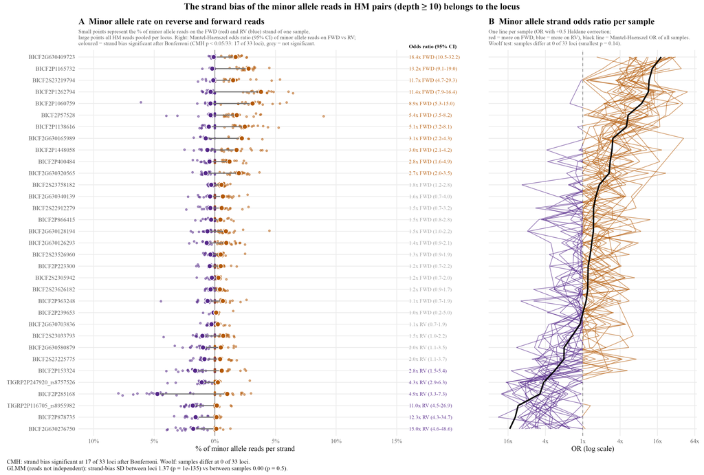

```r
# The odds-ratio figure (A + B) with the findings of all three analyses as its caption
sbo_findings <- sprintf("CMH: strand bias significant at %d of %d loci after Bonferroni. Woolf: samples differ at %d of %d loci.\nGLMM (reads not independent): strand-bias SD between loci %.2f (p = %.2g) vs between samples %.2f (p = %.2g).",
                        sum(sbo_loci$significant), nrow(sbo_loci), sum(sbo_loci$homogeneity_p < 0.05), nrow(sbo_loci),
                        sbm_bias_sd_locus, sbm_p_locus, sbm_bias_sd_sample, sbm_p_sample)

p_sbo_figure <- wrap_plots(p_sbo_rates, p_sbo_lines, widths = c(1.6, 1)) +
  plot_annotation(title = "The strand bias of the minor allele reads in HM pairs (depth \u2265 10) belongs to the locus",
                  caption = sbo_findings,
                  theme = theme(plot.title = element_text(size = 15, face = "bold", hjust = 0.5),
                                plot.caption = element_text(size = 10, hjust = 0)))

sbo_figure_png <- file.path(out_dir_FS, "strand_bias_odds_ratio.png")
ggsave(sbo_figure_png, p_sbo_figure, width = 16, height = 10.8, dpi = 300, bg = "white")
ggsave(file.path(out_dir_FS, "strand_bias_odds_ratio.pdf"), p_sbo_figure, width = 16, height = 10.8, device = cairo_pdf)
include_graphics(normalizePath(sbo_figure_png), rel_path = FALSE)
```

## 8 Amplicon rank analysis and visualization

This chunk contains data prep and plots for amplicon rank analysis. Amplicons form longer ligated concatemers which are separated into sample specific .fastq files by first Dorado demultiplexing with STA and LSP primers. The actual amplicon rank is determined by ObiTools4 demultiplexing (for example 1/2, 2/2, 1/1, 4/9,…) which split the read into chunks of sequence (amplicon). Those amplicons are then used for SNP and allele calling with ASP1 and ASP2 primers. Main idea behind this chunk is how the amplicon rank effects the quality and confidence for allele calling, it searches for pattern betwen amplicon position in a read and its allele calling success rate and SNP calling. How trusting are those ranks, can one really say a singleton is a singleton and not just a longer sequence of ligated amplicon which couldnt be assigned to a specific locus just by pure coincidence or because of higher number of mismatches allowed when aligning the primers. The amplicons are therefor checked for flanking sequences, where those are, how long are those sequence and divides it by median length of an ampicon (116). this gives an estimation of how many “amplicon” are left untouched. This is the idea behind adjusted concatemer of 6 found amplicon has a flanking sequences after first amplicon the ranks are adjusted (1 -> 1, 2 -> 3, 3 -> 4) and the whole concatemer is pushed to 6 -> 7.

It also plots some basic bar plots with patchworked pie plots showing number of amplicons by concatemer size and share of singletons and other panels of basic information.

```r
stopifnot("run the setup chunk first" = exists("graphics_dir") && exists("asp_reads_path") && exists("dataset_name"),
          "run the FS chunk first (ref, fs_calls)" = exists("ref") && exists("fs_calls"),
          "run the QD chunk first (margin_fate_colours, margin_min_snp_quality)" = exists("margin_fate_colours") && exists("margin_min_snp_quality"))

# Output paths and editable variables
concat_out_dir <- file.path(graphics_dir, "Genotype_filtration_parameters/Amplicon_rank_analysis")
dir.create(concat_out_dir, showWarnings = FALSE, recursive = TRUE)
concat_raw_fastq_dir <- sprintf("Data/Processed_data/%s/Demultiplexed_sequence_data/Dorado_demultiplexed_by_sample", dataset_name)
concat_identified_fastq_dir <- sprintf("Data/Processed_data/%s/Demultiplexed_sequence_data/Identified_sample_sequences_Obi4", dataset_name)
concat_barcodes <- sprintf("barcode%02d", seq_len(n_barcodes))
concat_largest_size_shown <- 15 # heatmap shows concatemers to this size
concat_pool_sizes_from <- 12 # in statistics, from those upwards are pooled, each on their won dont contain enough data
concat_min_amplicons <- 30 # heatmap tiles a regrey with fewer than this number of reads

# Colours for the plots
concat_brown <- "#8B775F"; concat_sage <- "#9AA582"; concat_dark_green <- "#657359"; concat_beige <- "#D7C9BE"; concat_cream <- "#F1E4DB"
concat_darken_f <- function(colours) setNames(rgb(t(col2rgb(colours) * 0.7), maxColorValue = 255), names(colours))
concat_theme <- theme_minimal(base_family = plot_font, base_size = 10) +
  theme(plot.title = element_text(face = "bold", size = 11),
        plot.title.position = "plot",
        plot.subtitle = element_text(size = 8, colour = "grey30"),
        panel.grid.major.x = element_blank(),
        panel.grid.minor = element_blank())

# Data prep
concat_amplicons <- read_tsv(asp_reads_path, col_select = c(barcode, locus, read_id, amplicon_rank, called_allele, relative_margin,
                            snp_position_quality, tie_flag, below_threshold_flag, forward_error, reverse_error),
                            col_types = cols(.default = "c", relative_margin = "d", snp_position_quality = "i", tie_flag = "l",
                            below_threshold_flag = "l", forward_error = "i", reverse_error = "i"))

# Positions of each amplicons inside the read
concat_amplicons <- concat_amplicons %>%
  separate(amplicon_rank, into = c("concatemer_rank", "concatemer_size"), sep = "/", convert = TRUE) %>% # separates the ranks
  mutate(raw_read_id = sub("_sub\\[.*\\]$", "", read_id), # parent read
         read_type = ifelse(concatemer_size == 1, "Singleton", "In concatemer"),
         position_type = factor(case_when(concatemer_size == 1 ~ "Singleton",
                                          concatemer_rank == 1 ~ "First",
                                          concatemer_rank == concatemer_size ~ "Last",
                                          TRUE ~ "Middle"), levels = c("Singleton", "First", "Middle", "Last")))

# Table with reasons why the reads weren't used
concat_amplicons <- concat_amplicons %>%
  mutate(fate = factor(case_when(!is.na(called_allele) ~ "Used for genotyping",
                                 tie_flag ~ "No allele signal (tie)",
                                 below_threshold_flag ~ "Poor alignment",
                                 TRUE ~ "Failed a SNP check"), levels = names(margin_fate_colours)))

# Comparison with reference
concat_amplicons <- concat_amplicons %>%
  left_join(select(ref, barcode = sample, locus, reference_genotype = genotype), by = c("barcode", "locus")) %>%
  mutate(outcome = factor(case_when(is.na(reference_genotype) ~ NA_character_,
                                    is.na(called_allele) ~ "Failed to call",
                                    called_allele == substr(reference_genotype, 1, 1) | called_allele == substr(reference_genotype, 2, 2) ~ "Called - correct", TRUE ~ "Called - wrong"), levels = c("Failed to call", "Called - wrong", "Called - correct")))

concat_group_colours <- c(Singleton = concat_brown, "In concatemer" = concat_sage,
                          First = concat_dark_green, Middle = concat_sage, Last = concat_beige)
concat_outcome_colours <- c("Failed to call" = concat_beige, "Called - wrong" = error_colour, "Called - correct" = correct_colour)

# 1. Plot,  concatemer size distribution with barplot and patchworked pie chart showing share of singletons
# Counts of amplicons per concatemer size
concat_amplicons_per_size <- count(concat_amplicons, concatemer_size, read_type, name = "n_amplicons")
concat_singleton_share <- concat_amplicons %>%
  count(read_type) %>%
  mutate(pct = 100 * n / sum(n))

kable(concat_amplicons_per_size)
```

| concatemer_size | read_type | n_amplicons |
| --- | --- | --- |
| 1 | Singleton | 28429 |
| 2 | In concatemer | 76343 |
| 3 | In concatemer | 101001 |
| 4 | In concatemer | 105182 |
| 5 | In concatemer | 99864 |
| 6 | In concatemer | 86482 |
| 7 | In concatemer | 68915 |
| 8 | In concatemer | 54786 |
| 9 | In concatemer | 44259 |
| 10 | In concatemer | 35591 |
| 11 | In concatemer | 28855 |
| 12 | In concatemer | 20086 |
| 13 | In concatemer | 14628 |
| 14 | In concatemer | 10429 |
| 15 | In concatemer | 4935 |
| 16 | In concatemer | 16 |
| 18 | In concatemer | 18 |

```r
kable(concat_singleton_share, digits = 1)
```

| read_type | n | pct |
| --- | --- | --- |
| In concatemer | 751390 | 96.4 |
| Singleton | 28429 | 3.6 |

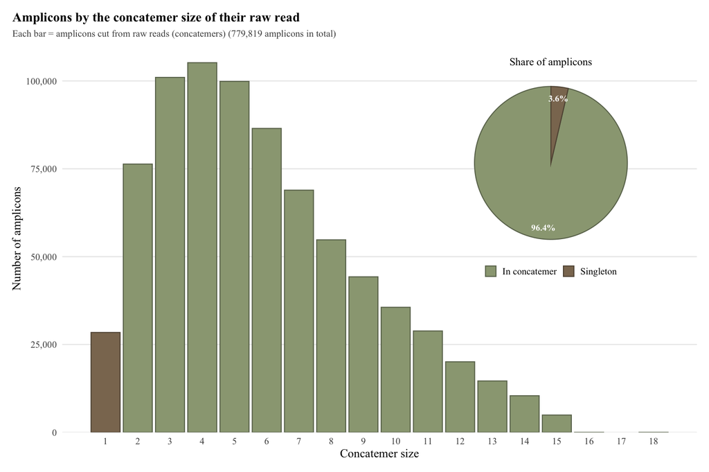

```r
p_concat_size_bars <- ggplot(concat_amplicons_per_size, aes(x = concatemer_size, y = n_amplicons, fill = read_type, colour = read_type)) +
  geom_col(linewidth = 0.4) +
  scale_fill_manual(values = concat_group_colours, guide = "none") +
  scale_colour_manual(values = concat_darken_f(concat_group_colours), guide = "none") +
  scale_x_continuous(breaks = seq_len(max(concat_amplicons_per_size$concatemer_size))) +
  scale_y_continuous(labels = label_comma(), expand = expansion(mult = c(0, 0.05))) +
  labs(title = "Amplicons by the concatemer size of their raw read",
       subtitle = sprintf("Each bar = amplicons cut from raw reads (concatemers) (%s amplicons in total)", comma(nrow(concat_amplicons))),
       x = "Concatemer size", y = "Number of amplicons") +
  concat_theme

# Pie plot
p_concat_singleton_pie <- ggplot(concat_singleton_share, aes(x = 1, y = n, fill = read_type, colour = read_type)) +
  geom_col(width = 1, linewidth = 0.4) +
  geom_text(aes(x = 1.35, label = sprintf("%.1f%%", pct)), position = position_stack(vjust = 0.5), size = 2.6, colour = "white", fontface = "bold") +
  coord_polar(theta = "y") +
  scale_x_continuous(limits = c(0.5, 1.5)) +
  scale_fill_manual(values = concat_group_colours, name = NULL) +
  scale_colour_manual(values = concat_darken_f(concat_group_colours), name = NULL) +
  labs(title = "Share of amplicons") +
  theme_void(base_family = plot_font, base_size = 10) +
  theme(plot.title = element_text(size = 9, hjust = 0.5), legend.position = "bottom",
        legend.key.size = unit(0.35, "cm"), legend.text = element_text(size = 8))

p_concat_size_with_pie <- p_concat_size_bars +
  inset_element(p_concat_singleton_pie, left = 0.55, bottom = 0.4, right = 0.99, top = 0.98)

print(p_concat_size_with_pie)
```

```r
ggsave(file.path(concat_out_dir, "concatemer_size_distribution_with_pie.png"), p_concat_size_with_pie, width = 8.27, height = 5.5, dpi = 300, bg = "white")
ggsave(file.path(concat_out_dir, "concatemer_size_distribution_with_pie.pdf"), p_concat_size_with_pie, width = 8.27, height = 5.5, device = cairo_pdf)

# 2. Plot, vote outcome by position of amplicon inside the concatemer

#Checks how many concatemers are missing an amplicon
concat_incomplete_concatemers <- concat_amplicons %>%
  filter(concatemer_size > 1) %>%
  group_by(raw_read_id, concatemer_size) %>%
  summarise(n_observed = n(), has_first = any(concatemer_rank == 1), has_last = any(concatemer_rank == concatemer_size), .groups = "drop") %>%
  summarise(n_concatemers = n(), n_incomplete = sum(n_observed < concatemer_size), n_missing_first = sum(!has_first), n_missing_last = sum(!has_last))
kable(concat_incomplete_concatemers)
```

| n_concatemers | n_incomplete | n_missing_first | n_missing_last |
| --- | --- | --- | --- |
| 165058 | 3731 | 871 | 878 |

```r
# What was the outcome base on position, are middle amplicons better at calling reads or not?
concat_outcome_by_position <- concat_amplicons %>%
  filter(!is.na(outcome)) %>%
  count(position_type, outcome, name = "n_reads") %>%
  group_by(position_type) %>%
  mutate(total = sum(n_reads), pct = 100 * n_reads / total) %>%
  ungroup()
kable(concat_outcome_by_position, digits = 1, col.names = c("Position", "Outcome", "Reads", "Total", "%"), format.args = list(big.mark = ","))
```

| Position | Outcome | Reads | Total | % |
| --- | --- | --- | --- | --- |
| Singleton | Failed to call | 10,296 | 28,422 | 36.2 |
| Singleton | Called - wrong | 141 | 28,422 | 0.5 |
| Singleton | Called - correct | 17,985 | 28,422 | 63.3 |
| First | Failed to call | 53,234 | 164,163 | 32.4 |
| First | Called - wrong | 822 | 164,163 | 0.5 |
| First | Called - correct | 110,107 | 164,163 | 67.1 |
| Middle | Failed to call | 132,409 | 422,953 | 31.3 |
| Middle | Called - wrong | 2,174 | 422,953 | 0.5 |
| Middle | Called - correct | 288,370 | 422,953 | 68.2 |
| Last | Failed to call | 53,199 | 164,154 | 32.4 |
| Last | Called - wrong | 872 | 164,154 | 0.5 |
| Last | Called - correct | 110,083 | 164,154 | 67.1 |

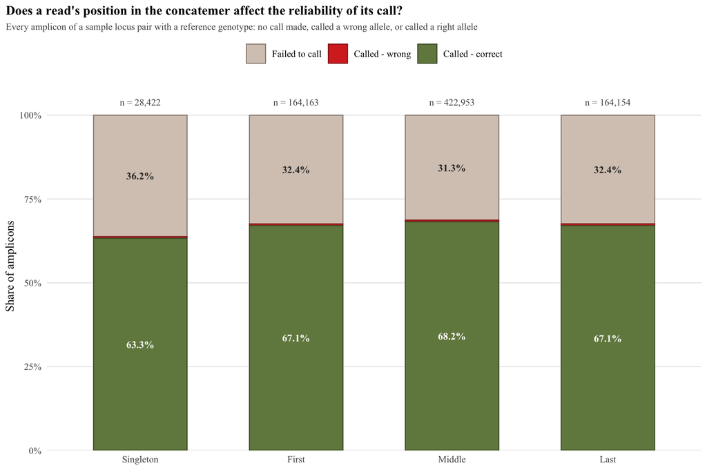

```r
p_concat_outcome <- ggplot(concat_outcome_by_position, aes(x = position_type, y = pct, fill = outcome)) +
  geom_col(aes(colour = outcome), width = 0.6, linewidth = 0.4) +
  geom_text(aes(label = ifelse(pct > 3, sprintf("%.1f%%", pct), ""), colour = paste(outcome, "label"), group = outcome),
            position = position_stack(vjust = 0.5), size = 3, fontface = "bold", show.legend = FALSE) +
  geom_text(data = distinct(concat_outcome_by_position, position_type, total), aes(x = position_type, y = 103, label = paste0("n = ", comma(total))),
            inherit.aes = FALSE, size = 2.8, vjust = 0, colour = "grey30") +
  scale_fill_manual(values = concat_outcome_colours, name = NULL) +
  scale_colour_manual(values = c(concat_darken_f(concat_outcome_colours),
                                "Failed to call label" = "grey20", "Called - wrong label" = "white", "Called - correct label" = "white"),
                     breaks = names(concat_outcome_colours), name = NULL) +
  scale_y_continuous(limits = c(0, 110), breaks = seq(0, 100, 25), labels = label_percent(scale = 1), expand = c(0, 0)) +
  labs(title = "Does a read's position in the concatemer affect the reliability of its call?",
       subtitle = "Every amplicon of a sample locus pair with a reference genotype: no call made, called a wrong allele, or called a right allele",
       x = NULL, y = "Share of amplicons") +
  concat_theme +
  theme(legend.position = "top")

print(p_concat_outcome)
```

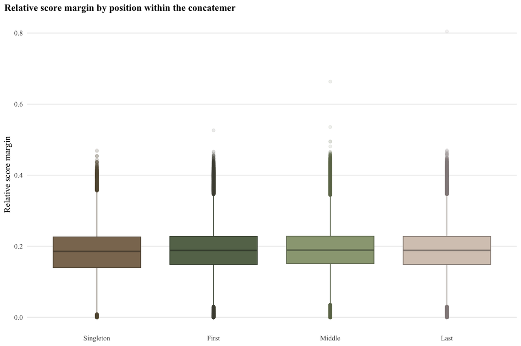

```r
ggsave(file.path(concat_out_dir, "outcome_by_position_type.png"), p_concat_outcome, width = 8.27, height = 5.5, dpi = 300, bg = "white")
ggsave(file.path(concat_out_dir, "outcome_by_position_type.pdf"), p_concat_outcome, width = 8.27, height = 5.5, device = cairo_pdf)



# 3. Plot, relative score margin by position
p_concat_margin <- ggplot(concat_amplicons, aes(x = position_type, y = relative_margin, fill = position_type, colour = position_type)) +
  geom_boxplot(outlier.alpha = 0.1, linewidth = 0.4) +
  scale_fill_manual(values = concat_group_colours, guide = "none") +
  scale_colour_manual(values = concat_darken_f(concat_group_colours), guide = "none") +
  labs(title = "Relative score margin by position within the concatemer", x = NULL, y = "Relative score margin") +
  concat_theme

print(p_concat_margin)
```

```r
ggsave(file.path(concat_out_dir, "relative_margin_by_position_type.png"), p_concat_margin, width = 8.27, height = 5.5, dpi = 300, bg = "white")
ggsave(file.path(concat_out_dir, "relative_margin_by_position_type.pdf"), p_concat_margin, width = 8.27, height = 5.5, device = cairo_pdf)



# 4. data prep, where do the reads from miscalled genotypes come from?
# Filters for miscalls only
concat_miscalled_votes <- concat_amplicons %>%
  semi_join(fs_calls %>% filter(call_status == "Miscalled") %>% select(barcode = sample, locus), by = c("barcode", "locus")) %>%
  filter(outcome != "Failed to call")

cat(sprintf("%d miscalled pairs, %d votes\n", n_distinct(paste(concat_miscalled_votes$barcode, concat_miscalled_votes$locus)), nrow(concat_miscalled_votes)))
```

```
5 miscalled pairs, 42 votes
```

```r
# Amplicons outcome by position within miscalls
concat_miscalled_votes %>% #
  count(position_type, outcome) %>%
  mutate(pct = 100 * n / sum(n), .by = position_type) %>%
  kable(digits = 1)
```

| position_type | outcome | n | pct |
| --- | --- | --- | --- |
| Singleton | Called - wrong | 3 | 100.0 |
| First | Called - wrong | 2 | 40.0 |
| First | Called - correct | 3 | 60.0 |
| Middle | Called - wrong | 8 | 28.6 |
| Middle | Called - correct | 20 | 71.4 |
| Last | Called - wrong | 3 | 50.0 |
| Last | Called - correct | 3 | 50.0 |

```r
# One row per miscall, reads from each position
concat_miscalled_votes %>%
  count(barcode, locus, position_type) %>%
  pivot_wider(names_from = position_type, values_from = n, values_fill = 0) %>%
  mutate(total_reads = rowSums(across(where(is.numeric)))) %>%
  arrange(desc(total_reads)) %>%
  kable()
```

| barcode | locus | First | Middle | Last | Singleton | total_reads |
| --- | --- | --- | --- | --- | --- | --- |
| W215214 | BICF2P57528 | 2 | 9 | 2 | 0 | 13 |
| W215208.r1 | BICF2P223300 | 1 | 6 | 0 | 3 | 10 |
| W215214.r1 | BICF2S2305942 | 1 | 6 | 2 | 0 | 9 |
| W215207.r1 | BICF2P223300 | 1 | 4 | 2 | 0 | 7 |
| W215220 | BICF2P878735 | 0 | 3 | 0 | 0 | 3 |

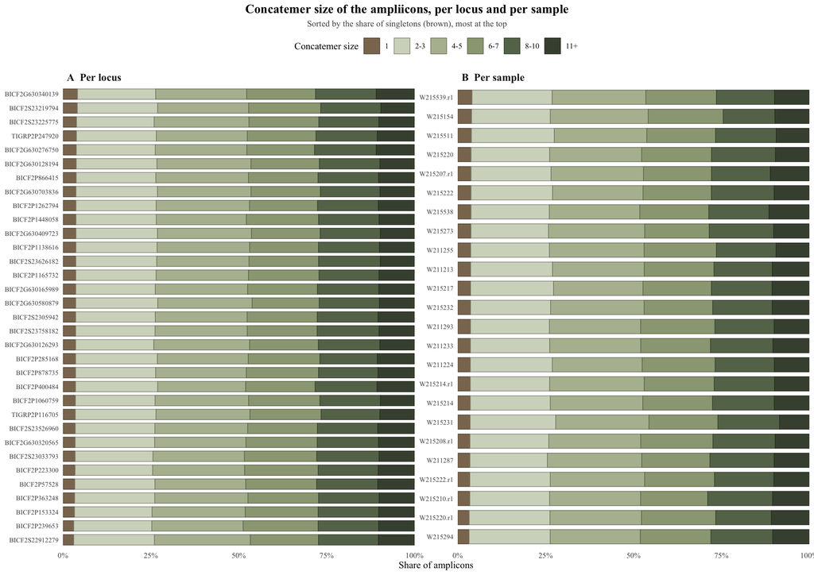

```r
# 5. Plot, concatemer size per locus and per sample
concat_short_locus_name_f <- function(locus) sub("_rs[0-9]+$", "", locus) # Shortens longer names, too white space for example TIGRP2P116705_rs8955982

# function calculates what share of each locus or sample amplicon come different raw read sizes
concat_size_shares_f <- function(group_column) {
  concat_amplicons %>%
mutate(size_group = cut(concatemer_size, breaks = c(0, 1, 3, 5, 7, 10, Inf), labels = c("1", "2-3", "4-5", "6-7", "8-10", "11+")), # concatemers sizes
           group = .data[[group_column]]) %>%
    count(group, size_group) %>%
    group_by(group) %>%
    mutate(pct = 100 * n / sum(n), singleton_pct = sum(pct[size_group == "1"])) %>%
    ungroup() %>%
    mutate(group = reorder(group, singleton_pct))
}
concat_size_shares_by_locus <- concat_size_shares_f("locus") %>%
  mutate(group = factor(concat_short_locus_name_f(as.character(group)), levels = concat_short_locus_name_f(levels(group))))
concat_size_shares_by_sample <- concat_size_shares_f("barcode")


concat_size_group_colours <- c("1" = concat_brown, "2-3" = "#D3D8C5", "4-5" = "#B4BC9F", "6-7" = concat_sage, "8-10" = concat_dark_green, "11+" = "#46503E")
concat_size_shares <- bind_rows("A  Per locus" = concat_size_shares_by_locus, "B  Per sample" = concat_size_shares_by_sample, .id = "panel")

p_concat_size_shares <- ggplot(concat_size_shares, aes(x = pct, y = group, fill = size_group, colour = size_group)) +
  geom_col(width = 0.75, linewidth = 0.3, position = position_stack(reverse = TRUE)) +
  facet_wrap(~ panel, scales = "free_y") +
  scale_fill_manual(values = concat_size_group_colours, name = "Concatemer size") +
  scale_colour_manual(values = concat_darken_f(concat_size_group_colours), name = "Concatemer size") +
  guides(fill = guide_legend(nrow = 1), colour = guide_legend(nrow = 1)) +
  scale_x_continuous(labels = label_percent(scale = 1), expand = c(0, 0)) +
  labs(title = "Concatemer size of the ampliicons, per locus and per sample",
       subtitle = "Sorted by the share of singletons (brown), most at the top",
       x = "Share of amplicons", y = NULL) +
  concat_theme +
  theme(plot.title = element_text(size = 13, hjust = 0.5), plot.subtitle = element_text(size = 9, hjust = 0.5),
        strip.text = element_text(face = "bold", size = 11, hjust = 0),
        axis.text.y = element_text(size = 7), panel.grid.major.y = element_blank(),
        legend.position = "top")

print(p_concat_size_shares)
```

```r
ggsave(file.path(concat_out_dir, "concatemer_size_per_locus_and_sample.png"), p_concat_size_shares, width = 11.69, height = 8.27, dpi = 300, bg = "white")
ggsave(file.path(concat_out_dir, "concatemer_size_per_locus_and_sample.pdf"), p_concat_size_shares, width = 11.69, height = 8.27, device = cairo_pdf)

# 6. Plot, Read quality by position and size, SNP base quality, reads outcome, primer errors

concat_amplicons_with_snp_quality <- filter(concat_amplicons, !is.na(snp_position_quality))
concat_size_class_levels <- c(as.character(seq_len(concat_pool_sizes_from - 1)), paste0(concat_pool_sizes_from, "+"))

# Groups by positions, for chekcing if first, short or last amplicon could have lower base quality
concat_snp_quality_by_position <- concat_amplicons_with_snp_quality %>%
  group_by(position_type) %>%
  summarise(n = n(), median_q = median(snp_position_quality), pct_below = 100 * mean(snp_position_quality < margin_min_snp_quality), .groups = "drop")
kable(concat_snp_quality_by_position, digits = 1)
```

| position_type | n | median_q | pct_below |
| --- | --- | --- | --- |
| Singleton | 27714 | 29 | 14.6 |
| First | 160313 | 30 | 13.1 |
| Middle | 413304 | 30 | 12.8 |
| Last | 160276 | 30 | 13.1 |

```r
# Same idea here, could quality depend on the length of the concatemer
concat_snp_quality_by_size <- concat_amplicons_with_snp_quality %>%
  mutate(size_class = factor(concat_size_class_levels[pmin(concatemer_size, concat_pool_sizes_from)], levels = concat_size_class_levels)) %>%
  group_by(size_class) %>%
  summarise(n = n(), median_q = median(snp_position_quality), q25 = quantile(snp_position_quality, 0.25), q75 = quantile(snp_position_quality, 0.75),
            pct_below = 100 * mean(snp_position_quality < margin_min_snp_quality), .groups = "drop")
kable(concat_snp_quality_by_size, digits = 1)
```

| size_class | n | median_q | q25 | q75 | pct_below |
| --- | --- | --- | --- | --- | --- |
| 1 | 27714 | 29 | 15 | 37 | 14.6 |
| 2 | 74487 | 30 | 16 | 37 | 13.6 |
| 3 | 98530 | 30 | 16 | 37 | 13.4 |
| 4 | 102685 | 30 | 16 | 38 | 13.0 |
| 5 | 97460 | 30 | 16 | 38 | 13.1 |
| 6 | 84444 | 30 | 16 | 38 | 13.0 |
| 7 | 67410 | 30 | 16 | 38 | 13.0 |
| 8 | 53576 | 30 | 17 | 38 | 12.6 |
| 9 | 43269 | 30 | 17 | 38 | 12.2 |
| 10 | 34791 | 30 | 17 | 38 | 12.4 |
| 11 | 28231 | 31 | 17 | 38 | 11.9 |
| 12+ | 49010 | 31 | 18 | 38 | 11.9 |

```r
concat_fate_by_position <- concat_amplicons %>%
  count(position_type, fate) %>%
  group_by(position_type) %>%
  mutate(pct = 100 * n / sum(n)) %>%
  ungroup()
kable(concat_fate_by_position, digits = 1, col.names = c("Position", "Fate", "Reads", "%"), format.args = list(big.mark = ","))
```

| Position | Fate | Reads | % |
| --- | --- | --- | --- |
| Singleton | Used for genotyping | 18,129 | 63.8 |
| Singleton | Failed a SNP check | 2,850 | 10.0 |
| Singleton | No allele signal (tie) | 1,544 | 5.4 |
| Singleton | Poor alignment | 5,906 | 20.8 |
| First | Used for genotyping | 110,946 | 67.6 |
| First | Failed a SNP check | 15,615 | 9.5 |
| First | No allele signal (tie) | 8,065 | 4.9 |
| First | Poor alignment | 29,561 | 18.0 |
| Middle | Used for genotyping | 290,598 | 68.7 |
| Middle | Failed a SNP check | 40,093 | 9.5 |
| Middle | No allele signal (tie) | 20,335 | 4.8 |
| Middle | Poor alignment | 71,997 | 17.0 |
| Last | Used for genotyping | 110,975 | 67.6 |
| Last | Failed a SNP check | 15,625 | 9.5 |
| Last | No allele signal (tie) | 8,146 | 5.0 |
| Last | Poor alignment | 29,434 | 17.9 |

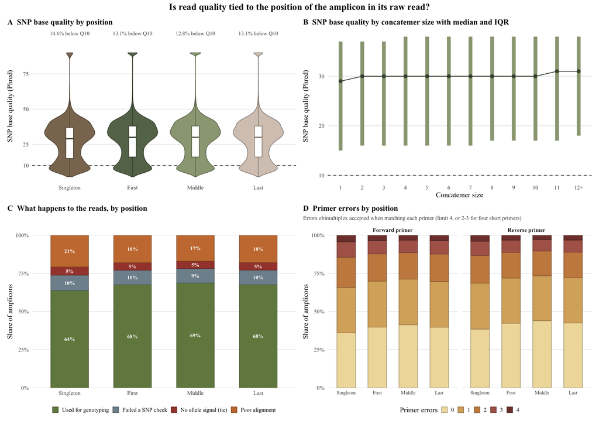

```r
# Primers errors reported by Obimulitplex inside the FWD and RV primers
concat_primer_errors_by_position <- concat_amplicons %>%
  select(position_type, Forward = forward_error, Reverse = reverse_error) %>%
  pivot_longer(c(Forward, Reverse), names_to = "primer", values_to = "errors") %>%
  filter(!is.na(errors)) %>%
  count(primer, position_type, errors = factor(errors)) %>%
  group_by(primer, position_type) %>%
  mutate(pct = 100 * n / sum(n)) %>%
  ungroup()

# Plot for quality based on position
p_concat_snp_quality_position <- ggplot(concat_amplicons_with_snp_quality, aes(x = position_type, y = snp_position_quality, fill = position_type, colour = position_type)) +
  geom_hline(yintercept = margin_min_snp_quality, linetype = "dashed", colour = "grey30", linewidth = 0.4) +
  geom_violin(linewidth = 0.4, width = 0.8, scale = "width") +
  geom_boxplot(width = 0.12, outlier.shape = NA, fill = "white", linewidth = 0.4) +
  geom_text(data = concat_snp_quality_by_position, aes(x = position_type, y = Inf, label = sprintf("%.1f%% below Q%d", pct_below, margin_min_snp_quality)),
            inherit.aes = FALSE, vjust = 1.5, size = 2.7, colour = "grey30") +
  scale_fill_manual(values = concat_group_colours, guide = "none") +
  scale_colour_manual(values = concat_darken_f(concat_group_colours), guide = "none") +
  scale_y_continuous(breaks = c(margin_min_snp_quality, 25, 50, 75), expand = expansion(mult = c(0.02, 0.12))) +
  coord_cartesian(ylim = c(0, 95)) +
  labs(title = "A  SNP base quality by position",
       x = NULL, y = "SNP base quality (Phred)") +
  concat_theme

# Plot for quality based on length
p_concat_snp_quality_size <- ggplot(concat_snp_quality_by_size, aes(x = size_class, y = median_q, group = 1)) +
  geom_hline(yintercept = margin_min_snp_quality, linetype = "dashed", colour = "grey30", linewidth = 0.4) +
  geom_linerange(aes(ymin = q25, ymax = q75), colour = concat_sage, linewidth = 2.5) +
  geom_line(colour = "#47513E", linewidth = 0.5) +
  geom_point(colour = "#47513E", size = 2) +
  labs(title = "B  SNP base quality by concatemer size with median and IQR",
       x = "Concatemer size", y = "SNP base quality (Phred)") +
  concat_theme

# PLot for outcomes based on position
p_concat_fates <- ggplot(concat_fate_by_position, aes(x = position_type, y = pct, fill = fate, colour = fate)) +
  geom_col(width = 0.6, linewidth = 0.3, position = position_stack(reverse = TRUE)) +
  geom_text(aes(label = ifelse(pct >= 4, sprintf("%.0f%%", pct), ""), group = fate), position = position_stack(vjust = 0.5, reverse = TRUE),
            size = 2.6, colour = "white", fontface = "bold") +
  scale_fill_manual(values = margin_fate_colours, name = NULL) +
  scale_colour_manual(values = concat_darken_f(margin_fate_colours), name = NULL) +
  scale_y_continuous(labels = function(x) paste0(x, "%"), expand = c(0, 0)) +
  guides(fill = guide_legend(nrow = 1), colour = guide_legend(nrow = 1)) +
  labs(title = "C  What happens to the reads, by position", x = NULL, y = "Share of amplicons") +
  concat_theme +
  theme(legend.position = "bottom", legend.text = element_text(size = 8), legend.key.size = unit(9, "pt"))

concat_error_colours <- c("0" = "#EFDCA8", "1" = "#D9AF6B", "2" = "#C98A4E", "3" = "#AF6458", "4" = "#7E4038")
p_concat_primer_errors <- ggplot(concat_primer_errors_by_position, aes(x = position_type, y = pct, fill = errors, colour = errors)) +
  geom_col(width = 0.6, linewidth = 0.3, position = position_stack(reverse = TRUE)) +
  facet_wrap(~ primer, nrow = 1, labeller = labeller(primer = function(x) paste(x, "primer"))) +
  scale_fill_manual(values = concat_error_colours, name = "Primer errors") +
  scale_colour_manual(values = concat_darken_f(concat_error_colours), name = "Primer errors") +
  scale_y_continuous(labels = label_percent(scale = 1), expand = c(0, 0)) +
  labs(title = "D  Primer errors by position", subtitle = "Errors obimultiplex accepted when matching each primer (limit 4, or 2-3 for four short primers)",
       x = NULL, y = "Share of amplicons") +
  concat_theme +
  theme(legend.position = "bottom", legend.text = element_text(size = 8), legend.key.size = unit(9, "pt"),
        strip.text = element_text(face = "bold"), axis.text.x = element_text(size = 7))

p_concat_read_quality <- wrap_plots(p_concat_snp_quality_position, p_concat_snp_quality_size, p_concat_fates, p_concat_primer_errors, ncol = 2) +
  plot_annotation(title = "Is read quality tied to the position of the amplicon in its raw read?",
                             theme = theme(plot.title = element_text(face = "bold", size = 13, hjust = 0.5)))

print(p_concat_read_quality)
```

```r
ggsave(file.path(concat_out_dir, "read_quality_by_position.png"), p_concat_read_quality, width = 11.69, height = 8.27, dpi = 300, bg = "white")
ggsave(file.path(concat_out_dir, "read_quality_by_position.pdf"), p_concat_read_quality, width = 11.69, height = 8.27, device = cairo_pdf)


# 7. Plot, raw reads vs the the amplicons found inside, are those really singletons or just longer reads with no matched primers?
# Reads fastq files, parses the reads from headers to sequence
concat_read_fastq_f <- function(path) {
  fastq_lines <- readLines(path)
  list(header = fastq_lines[seq(1, length(fastq_lines), 4)], sequence = fastq_lines[seq(2, length(fastq_lines), 4)])
}
# Finds sample files
concat_find_file_f <- function(folder, pattern) {
  matches <- Sys.glob(file.path(folder, pattern))
  if (length(matches) > 1) stop("more than one file matches ", pattern, " in ", folder)
  if (length(matches) == 0) NA_character_ else matches
}

concat_raw_read_list <- list()
concat_found_amplicon_list <- list()

# Loops over the barcodes and build two tables, one for raw read and one for the amplicons found inside.
for (concat_barcode in concat_barcodes) {
  concat_raw_path <- concat_find_file_f(concat_raw_fastq_dir, sprintf("%s.fastq*", concat_barcode))
  concat_identified_path <- concat_find_file_f(concat_identified_fastq_dir, sprintf("%s_identified.fastq*", concat_barcode))
  if (is.na(concat_raw_path) || is.na(concat_identified_path)) {
    message(concat_barcode, ": file missing, skipped")
    next
  }
  concat_raw_fastq <- concat_read_fastq_f(concat_raw_path)
  concat_raw_read_list[[concat_barcode]] <- tibble(barcode = concat_barcode,
                                                   raw_read_id = sub("^@(\\S+).*", "\\1", concat_raw_fastq$header),
                                                   raw_length = nchar(concat_raw_fastq$sequence),
                                                   read_qs = as.numeric(sub(".*\\bqs:f:([0-9.]+).*", "\\1", concat_raw_fastq$header)))
  concat_identified_fastq <- concat_read_fastq_f(concat_identified_path)
  concat_amplicon_ids <- sub("^@(\\S+).*", "\\1", concat_identified_fastq$header)
  concat_found_amplicon_list[[concat_barcode]] <- tibble(barcode = concat_barcode,
                                                         read_id = concat_amplicon_ids,
                                                         raw_read_id = sub("_sub\\[.*$", "", concat_amplicon_ids),
                                                         insert_start = as.integer(sub(".*_sub\\[([0-9]+)\\.\\..*", "\\1", concat_amplicon_ids)),
                                                         insert_end = as.integer(sub(".*\\.\\.([0-9]+)\\]$", "\\1", concat_amplicon_ids)))
  cat(sprintf("%s: %s raw reads, %s amplicons\n", concat_barcode, comma(length(concat_raw_fastq$sequence)), comma(length(concat_amplicon_ids))))
}
```

```
barcode01: 6,401 raw reads, 25,099 amplicons
barcode02: 8,107 raw reads, 32,068 amplicons
barcode03: 15,149 raw reads, 60,576 amplicons
barcode04: 5,819 raw reads, 23,134 amplicons
barcode05: 8,785 raw reads, 35,216 amplicons
barcode06: 9,517 raw reads, 37,795 amplicons
barcode07: 6,449 raw reads, 25,213 amplicons
barcode08: 9,931 raw reads, 39,265 amplicons
barcode09: 13,574 raw reads, 54,325 amplicons
barcode10: 7,240 raw reads, 29,166 amplicons
barcode11: 13,792 raw reads, 54,868 amplicons
barcode12: 6,842 raw reads, 27,189 amplicons
barcode13: 7,305 raw reads, 28,891 amplicons
barcode14: 7,862 raw reads, 31,145 amplicons
barcode15: 5,486 raw reads, 21,908 amplicons
barcode16: 6,226 raw reads, 24,662 amplicons
barcode17: 12,758 raw reads, 50,877 amplicons
barcode18: 5,493 raw reads, 21,431 amplicons
barcode19: 7,711 raw reads, 30,578 amplicons
barcode20: 5,492 raw reads, 21,771 amplicons
barcode21: 5,020 raw reads, 20,224 amplicons
barcode22: 9,048 raw reads, 35,077 amplicons
barcode23: 7,873 raw reads, 31,255 amplicons
barcode24: 4,657 raw reads, 18,086 amplicons
```

```r
# Combines the per barcode results, arranges by starting position of amplicons and calculates gaps length from previosu found amplicon
concat_raw_reads <- bind_rows(concat_raw_read_list)
concat_found_amplicons <- bind_rows(concat_found_amplicon_list) %>%
  arrange(barcode, raw_read_id, insert_start) %>%
  group_by(barcode, raw_read_id) %>%
  mutate(found_rank = row_number(), found_size = n(),
         gap_to_previous = insert_start - lag(insert_start)) %>%
  ungroup()

stopifnot("no barcode had both files" = nrow(concat_raw_reads) > 0,
          "could not read the read quality (qs:f:) from the raw headers" = !anyNA(concat_raw_reads$read_qs),
          "the same amplicon read_id occurs twice in the FASTQ files (a file copied under two barcodes?)" = !anyDuplicated(concat_found_amplicons$read_id))

# one row per raw read with concatemer size and checks how long are the flanking position, for figuring out if its really the right size concatemer or there were just no primers found
concat_raw_read_summary <- concat_raw_reads %>%
  left_join(concat_found_amplicons %>%
              group_by(barcode, raw_read_id) %>%
              summarise(found_size = n(), lead = min(insert_start), last_end = max(insert_end), .groups = "drop"),
            by = c("barcode", "raw_read_id")) %>%
  mutate(tail = raw_length - last_end,
         size_group = factor(case_when(is.na(found_size) ~ "none",
                                       found_size >= 10 ~ "10+",
                                       TRUE ~ as.character(found_size)), levels = c("none", 1:9, "10+")))

# Median length of one amplicon
concat_amplicon_unit <- median(concat_found_amplicons$gap_to_previous, na.rm = TRUE)
# Median length of flank before the first amplicon
concat_typical_lead <- median(concat_raw_read_summary$lead[concat_raw_read_summary$found_size > 1], na.rm = TRUE)
# Median length of flank after the last amplicon
concat_typical_tail <- median(concat_raw_read_summary$tail[concat_raw_read_summary$found_size > 1], na.rm = TRUE)
cat(sprintf("typical flanks: %.0f bases before the first amplicon, %.0f after the last; neighbouring amplicons %.0f bases apart\n",
            concat_typical_lead, concat_typical_tail, concat_amplicon_unit))
```

```
typical flanks: 109 bases before the first amplicon, 108 after the last; neighbouring amplicons 116 bases apart
```

```r
# Calcualtes cutoffs if median lead is 90 and median length of amplicon 120, cutoff is at 150. if Flanks are lonegr than that there is probably one missed amplicon
concat_lead_cutoff <- concat_typical_lead + concat_amplicon_unit / 2
concat_tail_cutoff <- concat_typical_tail + concat_amplicon_unit / 2

concat_flanks <- concat_raw_read_summary %>%
  filter(!is.na(found_size)) %>%
  mutate(read_type = ifelse(found_size == 1, "Singleton", "In concatemer"),
         missed_amplicon = lead > concat_lead_cutoff | tail > concat_tail_cutoff)
concat_missed_share <- concat_flanks %>%
  group_by(read_type) %>%
  summarise(n = n(), pct_missed = 100 * mean(missed_amplicon), .groups = "drop")
kable(concat_missed_share, digits = 1)
```

| read_type | n | pct_missed |
| --- | --- | --- |
| In concatemer | 164610 | 8.3 |
| Singleton | 28877 | 15.9 |

```r
concat_raw_read_summary %>%
  summarise(n = n(), median_length = median(raw_length), median_qs = median(read_qs), .by = size_group) %>%
  arrange(size_group) %>%
  kable(digits = 1)
```

| size_group | n | median_length | median_qs |
| --- | --- | --- | --- |
| none | 3050 | 245 | 12.8 |
| 1 | 28877 | 252 | 14.0 |
| 2 | 38495 | 369 | 14.2 |
| 3 | 33870 | 487 | 14.3 |
| 4 | 26385 | 606 | 14.4 |
| 5 | 19978 | 724 | 14.4 |
| 6 | 14385 | 842 | 14.5 |
| 7 | 9849 | 961 | 14.6 |
| 8 | 6823 | 1080 | 14.5 |
| 9 | 4889 | 1201 | 14.6 |
| 10+ | 9936 | 1465 | 14.7 |

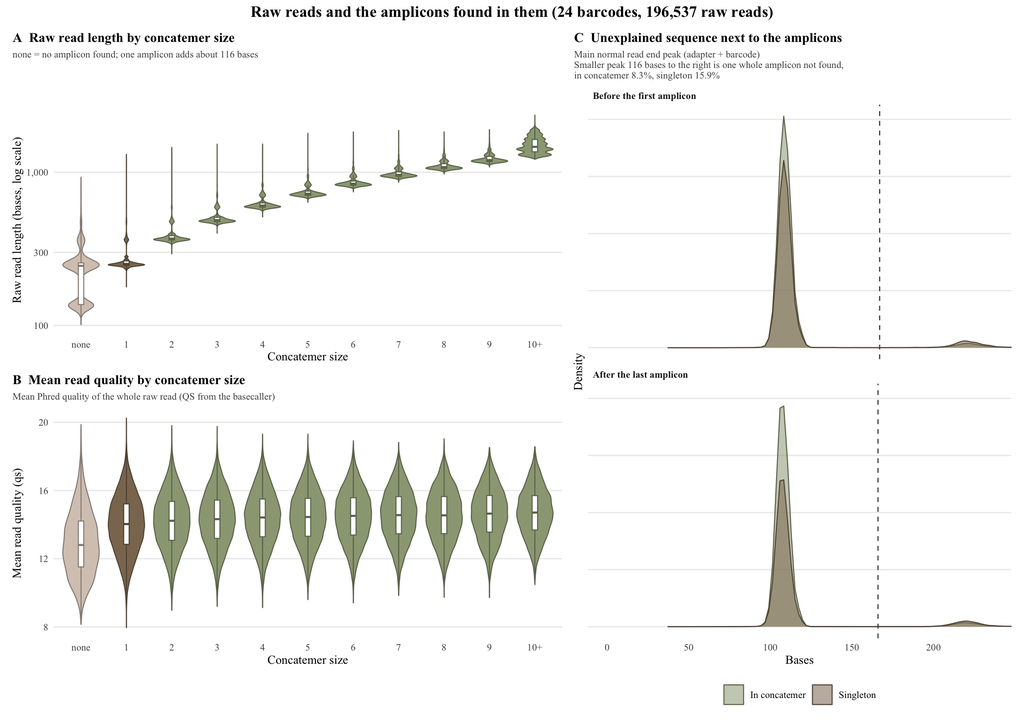

```r
concat_flanks_long <- concat_flanks %>%
  select(read_type, "Before the first amplicon" = lead, "After the last amplicon" = tail) %>%
  pivot_longer(-read_type, names_to = "flank", values_to = "bases") %>%
  mutate(flank = factor(flank, levels = unique(flank)))

concat_flank_cutoffs <- tibble(flank = unique(concat_flanks_long$flank), cutoff = c(concat_lead_cutoff, concat_tail_cutoff))
concat_flank_axis_end <- quantile(concat_flanks_long$bases, 0.99, na.rm = TRUE)

# Plots using this data
concat_size_group_fill <- c(none = concat_beige, "1" = concat_brown, setNames(rep(concat_sage, 9), c(2:9, "10+")))

p_concat_raw_length <- ggplot(concat_raw_read_summary, aes(x = size_group, y = raw_length, fill = size_group, colour = size_group)) +
  geom_violin(linewidth = 0.4, width = 0.8, scale = "width") +
  geom_boxplot(width = 0.12, outlier.shape = NA, fill = "white", linewidth = 0.4) +
  scale_fill_manual(values = concat_size_group_fill, guide = "none") +
  scale_colour_manual(values = concat_darken_f(concat_size_group_fill), guide = "none") +
  scale_y_log10(labels = label_comma()) +
  labs(title = "A  Raw read length by concatemer size",
       subtitle = sprintf("none = no amplicon found; one amplicon adds about %.0f bases", concat_amplicon_unit),
       x = "Concatemer size", y = "Raw read length (bases, log scale)") +
  concat_theme

p_concat_raw_quality <- ggplot(concat_raw_read_summary, aes(x = size_group, y = read_qs, fill = size_group, colour = size_group)) +
  geom_violin(linewidth = 0.4, width = 0.8, scale = "width") +
  geom_boxplot(width = 0.12, outlier.shape = NA, fill = "white", linewidth = 0.4) +
  scale_fill_manual(values = concat_size_group_fill, guide = "none") +
  scale_colour_manual(values = concat_darken_f(concat_size_group_fill), guide = "none") +
  labs(title = "B  Mean read quality by concatemer size", subtitle = "Mean Phred quality of the whole raw read (QS from the basecaller)",
       x = "Concatemer size", y = "Mean read quality (qs)") +
  concat_theme

p_concat_flanks <- ggplot(concat_flanks_long, aes(x = bases, fill = read_type, colour = read_type)) +
  geom_density(alpha = 0.55, linewidth = 0.4, adjust = 0.6, na.rm = TRUE) +
  geom_vline(data = concat_flank_cutoffs, aes(xintercept = cutoff), linetype = "dashed", colour = "grey30") +
  facet_wrap(~ flank, ncol = 1) +
  scale_fill_manual(values = concat_group_colours, name = NULL) +
  scale_colour_manual(values = concat_darken_f(concat_group_colours), name = NULL) +
  coord_cartesian(xlim = c(0, concat_flank_axis_end)) +
  labs(title = "C  Unexplained sequence next to the amplicons",
       subtitle = sprintf("Main normal read end peak (adapter + barcode)\nSmaller peak %.0f bases to the right is one whole amplicon not found,\n%s",
                  concat_amplicon_unit, paste(sprintf("%s %.1f%%", tolower(concat_missed_share$read_type), concat_missed_share$pct_missed), collapse = ", ")),
       x = "Bases", y = "Density") +
  concat_theme +
  theme(legend.position = "bottom", strip.text = element_text(face = "bold", hjust = 0), axis.text.y = element_blank())

p_concat_raw_reads <- wrap_plots(wrap_plots(p_concat_raw_length, p_concat_raw_quality, ncol = 1), p_concat_flanks,
                                            ncol = 2, widths = c(1.2, 1)) +
  plot_annotation(title = sprintf("Raw reads and the amplicons found in them (%d barcodes, %s raw reads)",
                                             n_distinct(concat_raw_reads$barcode), comma(nrow(concat_raw_reads))),
                             theme = theme(plot.title = element_text(face = "bold", size = 13, hjust = 0.5)))
print(p_concat_raw_reads)
```

```r
ggsave(file.path(concat_out_dir, "raw_reads_length_quality_flanks.png"), p_concat_raw_reads, width = 11.69, height = 8.27, dpi = 300, bg = "white")
ggsave(file.path(concat_out_dir, "raw_reads_length_quality_flanks.pdf"), p_concat_raw_reads, width = 11.69, height = 8.27, device = cairo_pdf)
```

```r
# 8. Plot, triangle rank heatmaps for original ranks and adjusted ranks
# computes the corrections for amplicon ranks
concat_fastq_rank_corrections <- concat_found_amplicons %>%
  left_join(select(concat_raw_read_summary, barcode, raw_read_id, lead, tail), by = c("barcode", "raw_read_id")) %>%
  mutate(missed_before = pmax(0, round((lead - concat_typical_lead) / concat_amplicon_unit)),
         missed_gap = pmax(0, round(coalesce(gap_to_previous, concat_amplicon_unit) / concat_amplicon_unit) - 1),
         missed_after = pmax(0, round((tail - concat_typical_tail) / concat_amplicon_unit)),
         adjusted_rank = found_rank + missed_before + cumsum(missed_gap),
         adjusted_size = found_size + missed_before + sum(missed_gap) + missed_after,
         .by = c(barcode, raw_read_id))

# number of missed amplicons added per row
concat_extra <- distinct(concat_fastq_rank_corrections, barcode, raw_read_id, found_size, adjusted_size) %>%
  mutate(extra = adjusted_size - found_size)
cat(sprintf("%s raw reads: adjusted size = found size for %.1f%%, one higher for %.1f%%, two or more higher for %.1f%%\n",
            comma(nrow(concat_extra)), 100 * mean(concat_extra$extra == 0), 100 * mean(concat_extra$extra == 1), 100 * mean(concat_extra$extra >= 2)))
```

```
193,487 raw reads: adjusted size = found size for 81.8%, one higher for 14.3%, two or more higher for 4.0%
```

```r
# the reads table rows with their adjusted rank and size from previous concat_fastq_rank_corrections
concat_amplicons_with_adjusted_rank <- concat_amplicons %>%
  inner_join(select(concat_fastq_rank_corrections, read_id, adjusted_rank, adjusted_size), by = "read_id")
cat(sprintf("%s of %s reads table rows matched a FASTQ amplicon (%.1f%%)\n", comma(nrow(concat_amplicons_with_adjusted_rank)),
            comma(nrow(concat_amplicons)), 100 * nrow(concat_amplicons_with_adjusted_rank) / nrow(concat_amplicons)))
```

```
779,819 of 779,819 reads table rows matched a FASTQ amplicon (100.0%)
```

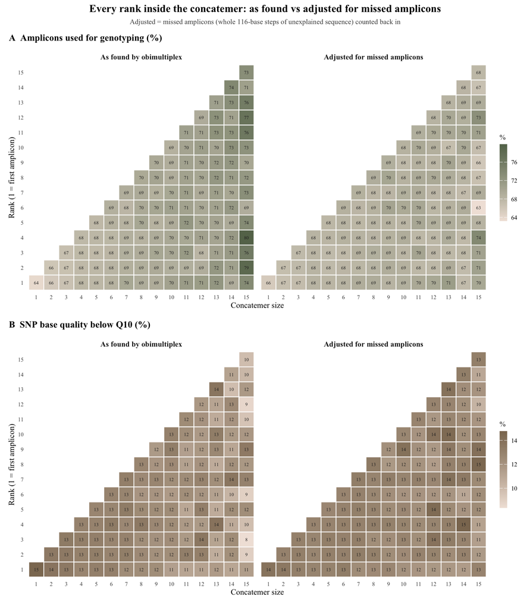

```r
stopifnot("almost no reads table row matched the FASTQ files: are they from the same sequencing run?" =
            nrow(concat_amplicons_with_adjusted_rank) >= 0.5 * nrow(concat_amplicons))

# one cell per version, size and rank: the same reads twice, once with the ranks as found and once with the adjusted ranks
concat_rank_cells <- bind_rows(
  "As found by obimultiplex" = select(concat_amplicons_with_adjusted_rank, concatemer_size, concatemer_rank, fate, snp_position_quality),
  "Adjusted for missed amplicons" = select(concat_amplicons_with_adjusted_rank, concatemer_size = adjusted_size, concatemer_rank = adjusted_rank, fate, snp_position_quality), .id = "version") %>%
  filter(concatemer_size <= concat_largest_size_shown) %>%
  summarise(n = n(),
            pct_used = 100 * mean(fate == "Used for genotyping"),
            pct_below_q = 100 * mean(snp_position_quality < margin_min_snp_quality, na.rm = TRUE),
            .by = c(version, concatemer_size, concatemer_rank)) %>%
  mutate(enough_reads = n >= concat_min_amplicons,
         version = factor(version, levels = unique(version)))

# Plots
concat_heatmap_theme <- theme_minimal(base_family = plot_font, base_size = 9) +
  theme(plot.title = element_text(face = "bold", size = 10.5), plot.title.position = "plot",
        strip.text = element_text(face = "bold", size = 8.5), axis.text = element_text(size = 6.5),
        panel.grid = element_blank(), legend.title = element_text(size = 8), legend.text = element_text(size = 7),
        legend.key.width = unit(3, "mm"))

# Share of amplicons used for genotyping per rank and concatemer size
p_concat_rank_used <- ggplot(concat_rank_cells, aes(x = factor(concatemer_size), y = factor(concatemer_rank))) +
  geom_tile(aes(fill = ifelse(enough_reads, pct_used, NA)), colour = "white", linewidth = 0.4) +
  geom_text(aes(label = ifelse(enough_reads, sprintf("%.0f", pct_used), "")), size = 1.9, colour = "grey15") +
  facet_wrap(~ version, nrow = 1) +
  scale_fill_gradient(low = concat_cream, high = concat_dark_green, na.value = "grey90", name = "%") +
  coord_equal() +
  labs(title = "A  Amplicons used for genotyping (%)", x = "Concatemer size", y = "Rank (1 = first amplicon)") +
  concat_heatmap_theme

# # Share of amplicons with SNP base quality below threshold per rank and concatemer size
p_concat_rank_low_quality <- ggplot(concat_rank_cells, aes(x = factor(concatemer_size), y = factor(concatemer_rank))) +
  geom_tile(aes(fill = ifelse(enough_reads, pct_below_q, NA)), colour = "white", linewidth = 0.4) +
  geom_text(aes(label = ifelse(enough_reads, sprintf("%.0f", pct_below_q), "")), size = 1.9, colour = "grey15") +
  facet_wrap(~ version, nrow = 1) +
  scale_fill_gradient(low = concat_cream, high = concat_brown, na.value = "grey90", name = "%") +
  coord_equal() +
  labs(title = sprintf("B  SNP base quality below Q%d (%%)", margin_min_snp_quality), x = "Concatemer size", y = "Rank (1 = first amplicon)") +
  concat_heatmap_theme

p_concat_rank_heatmaps <- wrap_plots(p_concat_rank_used, p_concat_rank_low_quality, ncol = 1) +
  plot_annotation(title = "Every rank inside the concatemer: as found vs adjusted for missed amplicons",
                  subtitle = sprintf("Adjusted = missed amplicons (whole %.0f-base steps of unexplained sequence) counted back in", concat_amplicon_unit),
                  theme = theme(plot.title = element_text(face = "bold", size = 12, hjust = 0.5),
                                plot.subtitle = element_text(size = 8, colour = "grey30", hjust = 0.5)))
print(p_concat_rank_heatmaps)
```

```r
ggsave(file.path(concat_out_dir, "quality_by_rank_and_size_adjusted.png"), p_concat_rank_heatmaps, width = 8.27, height = 9.5, dpi = 300, bg = "white")
ggsave(file.path(concat_out_dir, "quality_by_rank_and_size_adjusted.pdf"), p_concat_rank_heatmaps, width = 8.27, height = 9.5, device = cairo_pdf)
```

## 9 SNP quality analysis - split violin and ECDF

This chunk contains data prep and plots for SNP quality analysis. First plot is ECDF (Empirical Cumulative Distribution Function), it plots % of reads up to each specific SNP Quality for called vs not called reads. No calls is split by reason - SNP low quality filter. It shows it separately, because one could assume reads accumulate faster at low SNP quality for no call reads, it shows that is not the case. No call reads accumulate faster at lower Q even without the filter. Second plot shows a split violin plot for SNP Quality of the major and minor allele reads for HM and HT final genotype pairs. It also contains a paired test per pair and two checks for robustness.

```r
stopifnot("run the setup chunk first (dataset_name, min_snp_quality)" = exists("dataset_name") && exists("min_snp_quality"),
          "run the FS chunk first (fs_calls)" = exists("fs_calls"),
          "install the lme4 package: install.packages('lme4')" = requireNamespace("lme4", quietly = TRUE))

# Output paths
out_dir_snpq <- file.path(graphics_dir, "SNP_Quality_by_Locus")
dir.create(out_dir_snpq, showWarnings = FALSE, recursive = TRUE)

snpq_threshold <- 20 # reference threshold for the % labels on the ECDF
snpq_quality_ceiling <- 90 # limit for base Q scores

# Importing reads and filtering for those with found SNP base quality
snpq_reads <- read_tsv(asp_reads_path,
                       col_select = c(barcode, locus, called_allele, snp_position_quality, snp_low_quality),
                       col_types = cols(barcode = "c", locus = "c", called_allele = "c", snp_position_quality = "d", snp_low_quality = "l")) %>%
  filter(!is.na(snp_position_quality))

# 1. Plot ECDF
# No calls are split by reason because one of the filter arelardy filter for low SNP quality
snpq_call_group_colours <- c("Called" = correct_colour, "No call: other reasons" = "#7F919B", "No call: low SNP quality" = "#D9B44A")

snpq_reads_by_call_group <- snpq_reads %>%
  mutate(call_group = factor(case_when(!is.na(called_allele) ~ "Called",
                                       snp_low_quality ~ "No call: low SNP quality",
                                       TRUE ~ "No call: other reasons"),
                                       levels = names(snpq_call_group_colours)))

# % of below the theresohld reads by call group
snpq_pct_below_threshold <- snpq_reads_by_call_group %>%
  group_by(call_group) %>%
  summarise(n = n(), pct_below = 100 * mean(snp_position_quality < snpq_threshold), .groups = "drop") %>%
  mutate(label = sprintf("%.0f%%", pct_below))

kable(snpq_pct_below_threshold, digits = 1)
```

| call_group | n | pct_below | label |
| --- | --- | --- | --- |
| Called | 530648 | 14.9 | 15% |
| No call: other reasons | 176829 | 52.8 | 53% |
| No call: low SNP quality | 54130 | 100.0 | 100% |

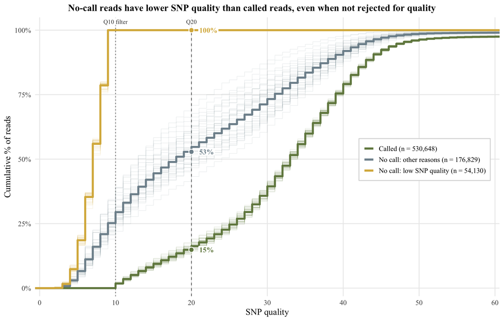

```r
# Labels for the plot
snpq_legend_labels <- setNames(sprintf("%s (n = %s)", snpq_pct_below_threshold$call_group, comma(snpq_pct_below_threshold$n)),
                               snpq_pct_below_threshold$call_group)
p_snpq_ecdf <- ggplot() +
  annotate("segment", x = c(min_snp_quality, snpq_threshold), xend = c(min_snp_quality, snpq_threshold), y = -Inf, yend = 102,
           linetype = c("dotted", "dashed"), colour = "grey40", linewidth = c(0.6, 0.5)) +
  annotate("label", x = c(min_snp_quality, snpq_threshold), y = 103.3, label = c(paste0("Q", min_snp_quality, " filter"), paste0("Q", snpq_threshold)),
           size = 3.4, colour = "grey25", fill = "white", linewidth = 0, label.padding = unit(0.15, "lines")) +
  stat_ecdf(data = snpq_reads_by_call_group, aes(x = snp_position_quality, y = after_stat(ecdf * 100), group = interaction(locus, call_group), colour = call_group),
            geom = "step", alpha = 0.15, linewidth = 0.35) +
  stat_ecdf(data = snpq_reads_by_call_group, aes(x = snp_position_quality, y = after_stat(ecdf * 100), colour = call_group),
            geom = "step", linewidth = 1.5) + # pooled curve
  geom_point(data = snpq_pct_below_threshold, aes(x = snpq_threshold, y = pct_below, fill = call_group),
             shape = 21, size = 3.2, colour = "white", stroke = 0.9, show.legend = FALSE) +
  geom_label(data = snpq_pct_below_threshold, aes(x = snpq_threshold, y = pct_below, label = label, colour = call_group), hjust = 0, nudge_x = 0.9,
             size = 4, fontface = "bold", fill = "white", linewidth = 0, label.padding = unit(0.12, "lines"), show.legend = FALSE) +
  scale_colour_manual(values = snpq_call_group_colours, labels = snpq_legend_labels, name = NULL) +
  scale_fill_manual(values = snpq_call_group_colours, guide = "none") +
  guides(colour = guide_legend(ncol = 1, override.aes = list(alpha = 1, linewidth = 1.5))) +
  scale_x_continuous(breaks = seq(0, 60, 10), expand = expansion(mult = c(0.01, 0.01))) +
  scale_y_continuous(breaks = seq(0, 100, 25), labels = label_percent(scale = 1),
                     limits = c(0, 105), expand = expansion(mult = c(0.03, 0))) +
  coord_cartesian(xlim = c(0, 60)) +
  labs(title = "No-call reads have lower SNP quality than called reads, even when not rejected for quality",
       x = "SNP quality", y = "Cumulative % of reads") +
  theme_minimal(base_family = plot_font, base_size = 14) +
  theme(plot.title = element_text(face = "bold", size = 15, hjust = 0.5), plot.title.position = "plot",
        legend.position = "inside", legend.position.inside = c(0.98, 0.49), legend.justification = c(1, 0.5), # centred on the 50 % line
        legend.background = element_rect(fill = "white", colour = "grey85"),
        legend.text = element_text(size = 11),
        panel.grid.minor = element_blank())

print(p_snpq_ecdf)
```

```r
ggsave(file.path(out_dir_snpq, "snp_quality_ecdf_by_locus_with_pooled.png"), p_snpq_ecdf, width = 11, height = 7, dpi = 300, bg = "white")
ggsave(file.path(out_dir_snpq, "snp_quality_ecdf_by_locus_with_pooled.pdf"), p_snpq_ecdf, width = 11, height = 7, device = cairo_pdf)
```

```r
### Split violin plots showing SNP quality of called reads from major and minor reads split by HM and HT

snpq_allele_colours <- c("HM major" = hm_dark, "HM minor" = hm_light, "HT major" = ht_dark, "HT minor" = ht_light)

# Data prep, every votings read with the paris zygosity and call status
snpq_voting_reads <- snpq_reads %>%
  filter(!is.na(called_allele)) %>%
  inner_join(fs_calls %>% select(barcode = sample, locus, zygosity_call, call_status), by = c("barcode", "locus")) %>%
  add_count(barcode, locus, called_allele, name = "allele_reads") %>%
  group_by(barcode, locus) %>%
  mutate(allele_role = ifelse(called_allele == called_allele[which.max(allele_reads)], "major", "minor")) %>%
  ungroup() %>%
  mutate(zygosity = factor(ifelse(zygosity_call == "Heterozygous", "Heterozygous (HT)", "Homozygous (HM)"),
                           levels = c("Homozygous (HM)", "Heterozygous (HT)")), #level order for plot
         allele_group = factor(paste(ifelse(zygosity_call == "Heterozygous", "HT", "HM"), allele_role), levels = names(snpq_allele_colours)))

# Medians and read counts for labels
snpq_allele_summary <- snpq_voting_reads %>%
  group_by(zygosity, allele_role) %>%
  summarise(n = n(), median_q = median(snp_position_quality), .groups = "drop")
kable(snpq_allele_summary, digits = 1)
```

| zygosity | allele_role | n | median_q |
| --- | --- | --- | --- |
| Homozygous (HM) | major | 453853 | 33 |
| Homozygous (HM) | minor | 3996 | 14 |
| Heterozygous (HT) | major | 41737 | 33 |
| Heterozygous (HT) | minor | 31046 | 33 |

```r
# paired test: per pair, median SNP quality of its major vs its minor allele reads. Reads within each pair are not independent so each pair counts once (paired Wilcoxon signed-rank test per zygosity)
snpq_pair_medians <- snpq_voting_reads %>%
  group_by(zygosity, barcode, locus, allele_role) %>%
  summarise(median_q = median(snp_position_quality), .groups = "drop") %>%
  pivot_wider(names_from = allele_role, values_from = median_q) %>%
  filter(!is.na(major), !is.na(minor)) %>% # only for pairs with reads for both minor and major
  mutate(difference = major - minor)

snpq_paired_tests <- snpq_pair_medians %>%
  group_by(zygosity) %>%
  summarise(pairs = n(),
            median_difference = median(difference),
            p = wilcox.test(major, minor, paired = TRUE, exact = FALSE)$p.value,
            .groups = "drop") %>%
  mutate(label = sprintf("major - minor: %+.0f Q, %s\n(paired Wilcoxon, %d pairs)", median_difference,
                         ifelse(p < 0.001, "p < 0.001", sprintf("p = %.3f", p)), pairs))
kable(select(snpq_paired_tests, -label), digits = 3, col.names = c("Zygosity", "Pairs", "Median difference (Q)", "p"))
```

| Zygosity | Pairs | Median difference (Q) | p |
| --- | --- | --- | --- |
| Homozygous (HM) | 601 | 19 | 0.000 |
| Heterozygous (HT) | 90 | 0 | 0.722 |

```r
# It asks whether major allele reads still have a higher SNP quality than minor reads when each locus counts only once. Pairs from the same locus aren't reallt independent, they share the same sequence, primers, probably errors
snpq_locus_tests <- snpq_pair_medians %>%
  group_by(zygosity, locus) %>%
  summarise(difference = median(difference), .groups = "drop") %>% # one value per locus
  group_by(zygosity) %>%
  summarise(loci = n(), median_difference = median(difference),
            p = wilcox.test(difference, mu = 0, exact = FALSE)$p.value, .groups = "drop")
kable(snpq_locus_tests, digits = 3, col.names = c("Zygosity", "Loci", "Median difference (Q)", "p"))
```

| Zygosity | Loci | Median difference (Q) | p |
| --- | --- | --- | --- |
| Homozygous (HM) | 33 | 19 | 0.000 |
| Heterozygous (HT) | 32 | 0 | 0.702 |

```r
# Mixed model on the pair differences, it handles locus and sample at the same time. Interecpt is average major - minor difference after accounting for pairs sharing a sample or a locus. p-value is the likelihood-ratio test, the same model with and without the intercept (anova refits both with ML, needed to compare fixed effects)
snpq_mixed_model_tests <- snpq_pair_medians %>%
  group_by(zygosity) %>%
  group_modify(function(pairs, key) {
    full_model <- lmer(difference ~ 1 + (1 | barcode) + (1 | locus), data = pairs)
    no_intercept_model <- lmer(difference ~ 0 + (1 | barcode) + (1 | locus), data = pairs) # same model, average difference fixed at 0
    intercept <- summary(full_model)$coefficients[1, ]
    tibble(estimate = intercept[["Estimate"]], standard_error = intercept[["Std. Error"]],
           p = anova(no_intercept_model, full_model)[["Pr(>Chisq)"]][2])
  }) %>%
  ungroup()
kable(snpq_mixed_model_tests, digits = 3, col.names = c("Zygosity", "Estimate (Q)", "SE", "p"))
```

| Zygosity | Estimate (Q) | SE | p |
| --- | --- | --- | --- |
| Homozygous (HM) | 16.193 | 0.688 | 0.000 |
| Heterozygous (HT) | 0.251 | 0.506 | 0.611 |

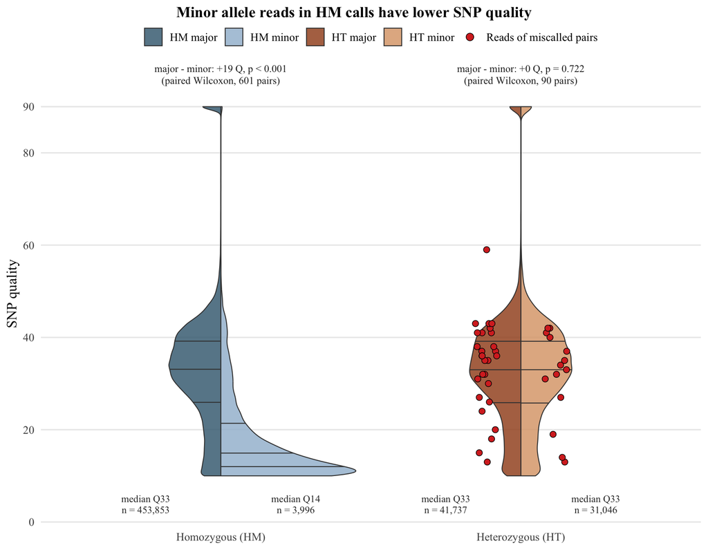

```r
# miscall reads as points, shifted onto the half of their allele role (left = major, right = minor)
snpq_miscall_points <- snpq_voting_reads %>%
  filter(call_status == "Miscalled") %>%
  mutate(x = as.numeric(zygosity) + ifelse(allele_role == "major", -0.12, 0.12))


# 2. Plot, split violin plots with split violin geom, odd groups are drawn as the left half, even groups as the right half.

GeomSplitViolin <- ggproto("GeomSplitViolin", GeomViolin,
  draw_group = function(self, data, ..., quantile_lines = NULL) {
    if ("quantile" %in% names(data)) data <- data[is.na(data$quantile), ]
    left_half <- data$group[1] %% 2 == 1
    centre_x <- data$x[1]
    data$edge_x <- if (left_half) data$x - data$violinwidth * (data$x - data$xmin) else data$x + data$violinwidth * (data$xmax - data$x)
    outline <- data[order(if (left_half) data$y else -data$y), ] # down one side, closed back at the centre line
    outline$x <- outline$edge_x
    outline <- rbind(transform(outline[1, ], x = centre_x), outline, transform(outline[nrow(outline), ], x = centre_x))
    violin_grob <- GeomPolygon$draw_panel(outline, ...)
    if (length(quantile_lines) == 0 || zero_range(range(data$y))) return(violin_grob)
    # quantile y = where the cumulative density reaches each quantile; each line runs from the centre to this half's edge only
    quantile_y <- approx(cumsum(data$density) / sum(data$density), data$y, xout = quantile_lines, ties = "ordered")$y
    quantile_edge <- approx(data$y, data$edge_x, xout = quantile_y, ties = "ordered")$y
    lines <- data[rep(1, 2 * length(quantile_y)), setdiff(names(data), c("x", "y", "group")), drop = FALSE]
    lines$x <- as.vector(rbind(centre_x, quantile_edge))
    lines$y <- rep(quantile_y, each = 2)
    lines$group <- rep(seq_along(quantile_y), each = 2)
    lines$alpha <- 1
    grobTree(violin_grob, GeomPath$draw_panel(lines, ...), name = grobName(prefix = "geom_split_violin"))
  })

geom_split_violin <- function(mapping = NULL, data = NULL, stat = "ydensity", position = "identity", ...,
                              quantile_lines = NULL, trim = TRUE, scale = "area", na.rm = FALSE, show.legend = NA, inherit.aes = TRUE) {
  layer(data = data, mapping = mapping, stat = stat, geom = GeomSplitViolin, position = position,
        show.legend = show.legend, inherit.aes = inherit.aes,
        params = list(trim = trim, scale = scale, quantile_lines = quantile_lines, na.rm = na.rm, ...))
}

p_snpq_split_violin <- ggplot(snpq_voting_reads, aes(x = zygosity, y = snp_position_quality, fill = allele_group)) +
  geom_split_violin(colour = "grey25", linewidth = 0.4, alpha = 0.85, quantile_lines = c(0.25, 0.5, 0.75)) +
  geom_point(data = snpq_miscall_points, aes(x = x, y = snp_position_quality, shape = "Reads of miscalled pairs"), inherit.aes = FALSE,
             position = position_jitter(width = 0.04, height = 0, seed = 1),
             size = 2.4, fill = error_colour, colour = "black", stroke = 0.4) +
  geom_text(data = snpq_allele_summary, aes(x = as.numeric(zygosity) + ifelse(allele_role == "major", -0.25, 0.25), y = 2,
                                            label = sprintf("median Q%.0f\nn = %s", median_q, comma(n))),
            inherit.aes = FALSE, size = 3.2, colour = "grey20", lineheight = 0.9, vjust = 0) +
  geom_text(data = snpq_paired_tests, aes(x = as.numeric(zygosity), y = 97, label = label),
            inherit.aes = FALSE, size = 3.3, colour = "grey15", lineheight = 0.95) +
  scale_fill_manual(values = snpq_allele_colours, name = NULL) +
  scale_shape_manual(values = c("Reads of miscalled pairs" = 21), name = NULL) +
  guides(fill = guide_legend(order = 1),
         shape = guide_legend(order = 2, override.aes = list(fill = error_colour, colour = "black", size = 3))) +
  # 90 is the highest value in the data: quality scores above it are written as 90
  scale_y_continuous(breaks = c(0, 20, 40, 60, 80, snpq_quality_ceiling), limits = c(0, 100), expand = expansion(mult = c(0.01, 0))) +
  labs(title = "Minor allele reads in HM calls have lower SNP quality", x = NULL, y = "SNP quality") +
  theme_minimal(base_family = plot_font, base_size = 13) +
  theme(plot.title = element_text(face = "bold", size = 14, hjust = 0.5), plot.title.position = "plot",
        legend.position = "top",
        legend.margin = margin(0, 0, 0, 0),
        legend.spacing.x = unit(5.5, "pt"),
        panel.grid.major.x = element_blank(),
        panel.grid.minor = element_blank())

print(p_snpq_split_violin)
```

```r
ggsave(file.path(out_dir_snpq, "snp_quality_major_minor_split_violin.png"), p_snpq_split_violin, width = 9, height = 7, dpi = 300, bg = "white")
ggsave(file.path(out_dir_snpq, "snp_quality_major_minor_split_violin.pdf"), p_snpq_split_violin, width = 9, height = 7, device = cairo_pdf)
```

## 10 MAF: confirmed HT vs confirmed HM

This plot shows minor allele fraction (MAF) for every locus sample pair with depth > 10 and HT threshold hard coded in the master pipeline at 0.2. Pairs are grouped by their reference genotype, the two groups are clearly separated. HM pairs are gathered near zero, which is basically the pairs error rate and HT center at around 0.4 -0.5 which is also expected for true HT.

```r
# Output path
maf_out <- file.path(graphics_dir, "Minor_Allele_Fraction")
dir.create(maf_out, recursive = TRUE, showWarnings = FALSE)

maf_min_reads <- 10 # minimum depth per pair

# Reference genotypes for comparison
maf_truth <- ref %>%
  filter(grepl("^[ACGT]{2}$", genotype)) %>%
  transmute(barcode = sample, locus, reference_genotype = genotype,
            true_class = ifelse(substr(genotype, 1, 1) == substr(genotype, 2, 2), "Confirmed homozygous", "Confirmed heterozygous"))
kable(count(maf_truth, true_class))
```

| true_class | n |
| --- | --- |
| Confirmed heterozygous | 84 |
| Confirmed homozygous | 691 |

```r
# MAF per pair for called reads only
maf_check <- read_tsv(asp_reads_path, col_select = c(barcode, locus, called_allele),
                      col_types = cols(.default = "c")) %>% # T doesn't count as TRUE
  filter(!is.na(called_allele)) %>%
  count(barcode, locus, called_allele, name = "n_allele") %>%
  summarise(n_total = sum(n_allele), top_count = max(n_allele), .by = c(barcode, locus)) %>%
  mutate(minor_fraction = (n_total - top_count) / n_total) %>%
  inner_join(maf_truth, by = c("barcode", "locus")) %>%
  left_join(select(asp_results, barcode, locus, asp_genotype = genotype), by = c("barcode", "locus")) %>%
  filter(n_total >= maf_min_reads)

maf_het <- filter(maf_check, true_class == "Confirmed heterozygous")
maf_hom <- filter(maf_check, true_class == "Confirmed homozygous")
stopifnot(nrow(maf_het) > 1, nrow(maf_hom) > 1)

# Summaries
maf_summary <- maf_check %>%
  group_by(true_class) %>%
  summarise(n = n(), mean = mean(minor_fraction), median = median(minor_fraction),
            p05 = quantile(minor_fraction, 0.05), p95 = quantile(minor_fraction, 0.95), .groups = "drop")
kable(maf_summary, digits = 3, col.names = c("Reference class", "Pairs", "Mean MAF", "Median MAF", "5th pct", "95th pct"))
```

| Reference class | Pairs | Mean MAF | Median MAF | 5th pct | 95th pct |
| --- | --- | --- | --- | --- | --- |
| Confirmed heterozygous | 83 | 0.426 | 0.442 | 0.32 | 0.489 |
| Confirmed homozygous | 671 | 0.010 | 0.007 | 0.00 | 0.024 |

```r
# Checking for overalap with MAF between confirmed HM and HT
maf_het_median <- median(maf_het$minor_fraction)
maf_hom_overlap <- sum(maf_hom$minor_fraction >= maf_het_median)
cat(sprintf("Confirmed heterozygotes: median minor fraction %.3f\n", maf_het_median))
```

```
Confirmed heterozygotes: median minor fraction 0.442
```

```r
cat(sprintf("Confirmed homozygotes with minor fraction >= that value: %d / %d (%.1f %%)\n",
            maf_hom_overlap, nrow(maf_hom), 100 * maf_hom_overlap / nrow(maf_hom)))
```

```
Confirmed homozygotes with minor fraction >= that value: 0 / 671 (0.0 %)
```

```r
cat(sprintf("Highest homozygote minor fraction: %.3f | lowest heterozygote minor fraction: %.3f\n",
            max(maf_hom$minor_fraction), min(maf_het$minor_fraction)))
```

```
Highest homozygote minor fraction: 0.400 | lowest heterozygote minor fraction: 0.267
```

```r
# Miscall only
maf_miscalls <- maf_check %>%
  filter(!is.na(asp_genotype), asp_genotype != reference_genotype) %>%
  mutate(label = sprintf("%s %s\ncalled %s (true %s), %d reads", barcode, sub("_rs[0-9]+$", "", locus),
                         asp_genotype, reference_genotype, n_total))
kable(select(maf_miscalls, barcode, locus, reference_genotype, asp_genotype, n_total, minor_fraction), digits = 3)
```

| barcode | locus | reference_genotype | asp_genotype | n_total | minor_fraction |
| --- | --- | --- | --- | --- | --- |
| W215208.r1 | BICF2P223300 | CC | CT | 10 | 0.400 |
| W215214 | BICF2P57528 | CC | CT | 13 | 0.231 |

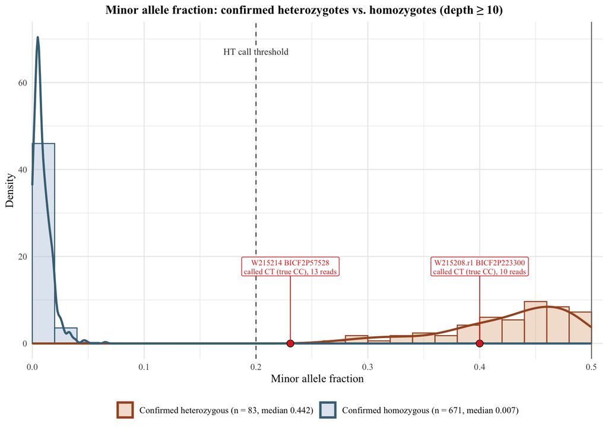

```r
# MAF plot
maf_cols <- c("Confirmed heterozygous" = ht_light, "Confirmed homozygous" = hm_light)
maf_edge_cols <- c("Confirmed heterozygous" = ht_dark, "Confirmed homozygous" = hm_dark)

maf_legend_labels <- setNames(sprintf("%s (n = %d, median %.3f)", maf_summary$true_class, maf_summary$n, maf_summary$median),
                              maf_summary$true_class)

maf_y_top <- max(density(maf_hom$minor_fraction)$y) # height of the HM for label position

p_maf <- ggplot(maf_check, aes(x = minor_fraction, fill = true_class, colour = true_class)) +
  geom_histogram(aes(y = after_stat(density)), binwidth = 0.02, boundary = 0, alpha = 0.35, position = "identity") +
  geom_density(linewidth = 1, fill = NA) +
  geom_vline(xintercept = 0.5, colour = "grey40", linewidth = 0.4) +
  geom_vline(xintercept = HT_min_frequence, colour = "grey30", linetype = "dashed", linewidth = 0.5) +
  annotate("label", x = HT_min_frequence, y = 0.95 * maf_y_top, label = "HT call threshold",
           size = 3.2, colour = "grey20", fill = "white", linewidth = 0) +
  geom_point(data = maf_miscalls, aes(x = minor_fraction, y = 0), inherit.aes = FALSE,
             shape = 21, size = 3, fill = error_colour, colour = "black", stroke = 0.4) +
  geom_segment(data = maf_miscalls, aes(x = minor_fraction, xend = minor_fraction, y = 0.6, yend = 0.22 * maf_y_top), inherit.aes = FALSE,
               colour = error_colour, linewidth = 0.4) +
  geom_label(data = maf_miscalls, aes(x = minor_fraction, y = 0.22 * maf_y_top, label = label), inherit.aes = FALSE,
             vjust = 0, size = 2.7, colour = error_colour, fill = "white", linewidth = 0.3, lineheight = 0.95) +
  scale_x_continuous(expand = expansion(mult = c(0, 0.02))) +
  coord_cartesian(xlim = c(0, 0.5), clip = "off") + # minor fraction is 0 to 0.5 by definition
  scale_fill_manual(values = maf_cols, labels = maf_legend_labels, name = NULL) +
  scale_colour_manual(values = maf_edge_cols, labels = maf_legend_labels, name = NULL) +
  labs(title = sprintf("Minor allele fraction: confirmed heterozygotes vs. homozygotes (depth \u2265 %d)", maf_min_reads),
       x = "Minor allele fraction", y = "Density") +
  theme_minimal(base_family = plot_font, base_size = 11) +
  theme(legend.position = "bottom",
        plot.title = element_text(face = "bold", size = 12, hjust = 0.5),
        plot.title.position = "plot") # centred over the whole figure, not only the panel

print(p_maf)
```

```r
ggsave(file.path(maf_out, "het_vs_hom_overlay.png"), p_maf, width = 8.27, height = 5.85, dpi = 300, bg = "white")
ggsave(file.path(maf_out, "het_vs_hom_overlay.pdf"), p_maf, width = 8.27, height = 5.85, device = cairo_pdf)
```

## 11 Changes in scoring threshold visualized and difference in perfect score calculation

This chunk contains visualization of at the start of the pipeline creation process arbitrarily picked 0.65 fraction of perfect score threshold and how the new updated changed the scoring and allowance of mismatches and indels per read. the first naive threshold was picked even before the master pipeline was quality aware, which means the alignment was calculated based on the same uniform quality of amplicons and ASP primers (Q22). What that means in practice, each read was scored with the same per base score, the length of the primer was the only deciding factor on how big the perfect score was. Setting the threshold to sit at 0.65 * perfect score of each primer was sensible choice as it sat somewhere in between one and two mismatches. After the introduction of read quality things changed, but the same threshold was kept for quite a long time because ti still kinda worked. Now that the read base qualities are in play and different possibilities of how to penalize indels things have to get a bit more sophisticated. Each read now get its own perfect quality score calculated based on actual base qualities, this perfect score is then again the basis of the threshold. Indel penalty has now been lowered to 6 indel insertion and 2 for adding gaps, which is in line with other software for analysing Nanopore data. Indels are abundant and penalizing them even more and not taking into consideration the artifacts of Nanopore sequencing would be counter intuitive. But we still dont want that many indels because reads get noisy then, that is why they are capped at 1 indel per read (can be changed). The number of mismatches each read is allowed is now based on (error rate (0.08) * length of the primer * cost of one average quality (Q20) mismatch). All of this parameters can be changed. This makes the updated threshold now: perfect primer score - max(one indel cost, error rate * length * cost of one mismatch). Given the length of the primers, maximum is usually at around two mismatches. Additional option for master pipeline is ability to cap mismatches at certain values, i have it set on 2 mismatches.

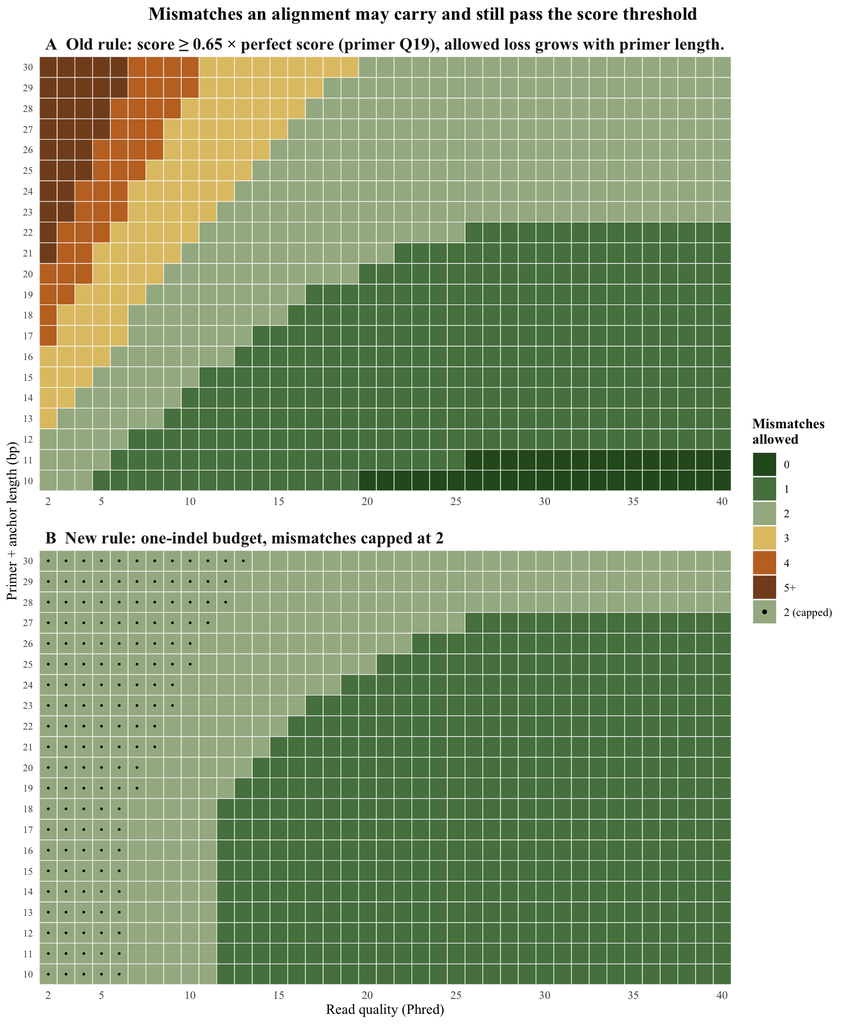

```r
stopifnot("run the setup chunk first" = exists("graphics_dir") && exists("max_mismatches"),
          "run the panel chunk first (panel, identified_file_names_f)" = exists("panel") && exists("identified_file_names_f"),
          "run the scorer chunk first (v8, match_lookup, mismatch_cost_lookup)" =
            exists("score_reads_against_primers_2pwalign_v8") && exists("match_lookup") && exists("mismatch_cost_lookup"))

# Output paths
qsim_out_dir <- file.path(graphics_dir, "Quality_Scoring_Simulation")
dir.create(qsim_out_dir, showWarnings = FALSE, recursive = TRUE)

# Variables of the new threshold calculation
qsim_error_quality <- 20 # Quality of the mismatch base used for new threshold
qsim_error_cost <- mismatch_cost_lookup[qsim_error_quality + 1] # cost of one Q20 mismatch
qsim_indel_budget <- min_errors * (gap_opening + gap_extension + max(match_lookup)) # new updated budget
qsim_shortest_primer <- min(nchar(panel$asp1_seq) + nchar(panel$anchor)) # shortest primer + anchor of the panel

# 1. Plot Heatmap, number of mismatches allowed with the old rule and new updated

# Model read with the same quality at every base. Dots shows the mismatch cap which sets the limit
qsim_read_qualities <- 2:40
qsim_primer_lengths <- qsim_shortest_primer:30 # primer lentgh from the shortest primer
qsim_count_colours <- c("0" = "#2C5724", "1" = "#55804D", "2" = "#A4B591", "3" = "#E1C473", "4" = "#C3722A", "5+" = "#834D24") #mismatches allowed
qsim_count_levels <- names(qsim_count_colours)
qsim_most_shown <- 5 # mismatches only to 5+

# Creates extra legend entry for capped values
qsim_has_cap <- is.finite(max_mismatches) # if it has a cap for example 2, this is TRUE
qsim_capped_label <- paste0(max_mismatches, " (capped)")
qsim_fill_levels <- if (qsim_has_cap) c(qsim_count_levels, qsim_capped_label) else qsim_count_levels
qsim_fill_colours <- if (qsim_has_cap) c(qsim_count_colours, setNames(qsim_count_colours[[min(max_mismatches, qsim_most_shown) + 1]], qsim_capped_label)) else qsim_count_colours # if it has a cap it joins them
qsim_legend_dot_sizes <- ifelse(qsim_fill_levels == qsim_capped_label, 1.6, 0) # dot for the capped key

# Data prep for heatmap, one row pwer tile for each rule
qsim_heatmap_tiles <- expand_grid(rule = c("fraction", "errors"), q_read = qsim_read_qualities, primer_len = qsim_primer_lengths) %>% #makes every combo
  mutate(perfect = primer_len * match_lookup[q_read + 1],
         allowed_loss = ifelse(rule == "fraction", (1 - min_score_fraction) * perfect, pmax(qsim_indel_budget, error_rate * primer_len * qsim_error_cost)),
         allowed_by_score = pmin(primer_len, floor(allowed_loss / mismatch_cost_lookup[q_read + 1] + 1e-9)), # New rule
         mismatch_cap = ifelse(rule == "errors", max_mismatches, Inf), # the old rule had no cap
         capped = allowed_by_score > mismatch_cap, # the cap, not the score budget, sets the limit here
         allowed = pmin(allowed_by_score, mismatch_cap),
         allowed_shown = factor(case_when(capped ~ qsim_capped_label,
                                          allowed >= qsim_most_shown ~ paste0(qsim_most_shown, "+"),
                                          TRUE ~ as.character(allowed)), levels = qsim_fill_levels))

# Panel titles
qsim_panel_titles <- c(fraction = sprintf("A  Old rule: score \u2265 %.2f \u00d7 perfect score (primer Q%d), allowed loss grows with primer length.", min_score_fraction, primer_quality),
                       errors = sprintf("B  New rule: one-indel budget, mismatches capped at %g", max_mismatches))
qsim_heatmap_tiles <- mutate(qsim_heatmap_tiles, panel = factor(qsim_panel_titles[rule], levels = qsim_panel_titles))

p_qsim_heatmap <- ggplot(qsim_heatmap_tiles, aes(q_read, primer_len, fill = allowed_shown)) +
  geom_tile(colour = "white", linewidth = 0.2, show.legend = TRUE) +
  geom_point(data = filter(qsim_heatmap_tiles, capped), shape = 16, stroke = 0, size = 0.9, colour = "black", show.legend = TRUE) +
  facet_wrap(~ panel, ncol = 1, axes = "all") + # vertical
  scale_fill_manual(values = qsim_fill_colours, limits = qsim_fill_levels, drop = FALSE, name = "Mismatches\nallowed") +
  guides(fill = guide_legend(override.aes = list(size = qsim_legend_dot_sizes))) + # dots shown only for capped tiles
  scale_x_continuous(breaks = c(2, 5, 10, 15, 20, 25, 30, 35, 40), expand = c(0, 0)) +
  scale_y_continuous(breaks = qsim_primer_lengths, expand = c(0, 0)) +
  labs(title = "Mismatches an alignment may carry and still pass the score threshold",
       x = "Read quality (Phred)", y = "Primer + anchor length (bp)") +
  theme_minimal(base_family = plot_font, base_size = 10) +
  theme(plot.title = element_text(size = 13, face = "bold", hjust = 0.5), plot.title.position = "plot",
        strip.text = element_text(size = 12, hjust = 0, lineheight = 1.1, face = "bold"),
        legend.title = element_text(face = "bold"),
        panel.grid = element_blank(), axis.text.y = element_text(size = 7),
        panel.spacing.y = unit(12, "pt"))

print(p_qsim_heatmap)
```

```r
ggsave(file.path(qsim_out_dir, sprintf("mismatches_allowed_old_vs_new_primer_Q%d.png", primer_quality)), p_qsim_heatmap,
       width = 8.27, height = 10, dpi = 300, bg = "white")
ggsave(file.path(qsim_out_dir, sprintf("mismatches_allowed_old_vs_new_primer_Q%d.pdf", primer_quality)), p_qsim_heatmap,
       width = 8.27, height = 10, device = cairo_pdf)
```

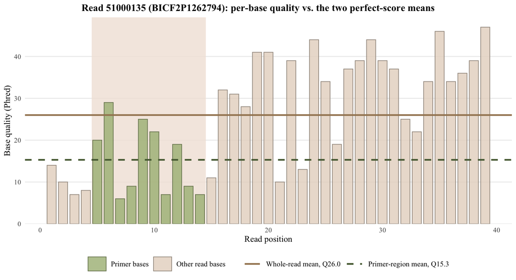

```r
stopifnot("run the heatmap chunk first (qsim_out_dir)" = exists("qsim_out_dir"))
# 2. Plot showing difference between real per base quality perfect score calculation vs mean of the whole read. Old perfect score calculation used per red means, now i use actual per base qualities


qsim_example_barcode <- "01" # example
qsim_reads_per_locus <- 500 # number of reads scored (i just need to find one good example)
qsim_phred_f <- function(quality_string) utf8ToInt(quality_string) - 33

# the sample's identified FASTQ, same parsing
qsim_fastq_lines <- readLines(identified_file_names_f(qsim_example_barcode))
qsim_fastq_headers <- qsim_fastq_lines[seq(1, length(qsim_fastq_lines), 4)]
qsim_sample_reads <- tibble(read_id = sub("^@(\\S+).*", "\\1", qsim_fastq_headers),
                            locus = sub('.*"experiment":"([^"]*)".*', "\\1", qsim_fastq_headers),
                            direction = sub('.*"obimultiplex_direction":"([^"]*)".*', "\\1", qsim_fastq_headers),
                            seq = qsim_fastq_lines[seq(2, length(qsim_fastq_lines), 4)],
                            qual = qsim_fastq_lines[seq(4, length(qsim_fastq_lines), 4)])

# every locus scored with the scorer function, for finding where primer sits on the read
qsim_scored_reads <- bind_rows(lapply(seq_len(nrow(panel)), function(panel_row) {
  locus_row <- panel[panel_row, ]
  locus_reads <- head(filter(qsim_sample_reads, locus == locus_row$locus), qsim_reads_per_locus)
  if (nrow(locus_reads) == 0) return(NULL)
  scored <- score_reads_against_primers_2pwalign_v8(DNAStringSet(locus_reads$seq), locus_reads$qual, locus_reads$direction,
                                                    locus_row$asp1_seq, locus_row$asp2_seq, locus_row$allele1, locus_row$allele2,
                                                    min_score_fraction, primer_quality = primer_quality, match_lookup = match_lookup,
                                                    gap_opening = gap_opening, gap_extension = gap_extension,
                                                    anchor = locus_row$anchor, input_type = input_type,
                                                    threshold_type = threshold_type, error_rate = error_rate,
                                                    min_errors = min_errors, min_snp_quality = min_snp_quality,
                                                    max_mismatches = max_mismatches, mismatch_cost_lookup = mismatch_cost_lookup,
                                                    probe_type = probe_type)
  asp1_wins <- scored$score1 >= scored$score2
  winning_primer <- paste0(ifelse(asp1_wins, locus_row$asp1_seq, locus_row$asp2_seq), locus_row$anchor)
  scored_length <- nchar(winning_primer)
  flip <- grepl("_rc$", scored$winning_orientation) # the direction the scorer used (ASP: header direction on padded reads, reference: the better of the two alignments)
  winning_primer[flip] <- as.character(reverseComplement(DNAStringSet(winning_primer[flip])))
  winning_alignment <- pairwiseAlignment(DNAStringSet(locus_reads$seq), DNAStringSet(winning_primer), type = "local-global",
                                                  patternQuality = PhredQuality(locus_reads$qual),
                                                  subjectQuality = PhredQuality(as.integer(primer_quality)),
                                                  gapOpening = gap_opening, gapExtension = gap_extension)
  tibble(locus = locus_row$locus, read_id = locus_reads$read_id, qual = locus_reads$qual, scored_length = scored_length,
         whole_mean_q = vapply(locus_reads$qual, function(q) mean(qsim_phred_f(q)), numeric(1), USE.NAMES = FALSE),
         mismatches = scored$winning_nmismatch,
         indels = scored$winning_indel_events,
         primer_start = start(pattern(winning_alignment)))
}))

# Hghest base quality of the read and the mean quality under the primer region
qsim_scored_reads <- qsim_scored_reads %>%
  mutate(region_quality = substr(qual, primer_start, primer_start + scored_length - 1),
         region_mean_q = vapply(region_quality, function(q) mean(qsim_phred_f(q)), numeric(1), USE.NAMES = FALSE),
         max_q = vapply(qual, function(q) max(qsim_phred_f(q)), numeric(1), USE.NAMES = FALSE),
         mean_gap = whole_mean_q - region_mean_q) # difference in means, actual errors when calculating perfect score

# Finding a clean read with primer alignment showing a clear difference with some filters to keep it clear
qsim_example_max_q <- 50 # base quality cap, for better looking plot
qsim_clean_reads <- filter(qsim_scored_reads, mismatches == 0, indels == 0, max_q <= qsim_example_max_q) # no mismatches or indels
stopifnot("no clean read in the searched reads: raise qsim_reads_per_locus or pick another qsim_example_barcode" = nrow(qsim_clean_reads) > 0)
qsim_example_read <- slice_max(qsim_clean_reads, mean_gap, n = 1, with_ties = FALSE) # Finding a clean read with most difference between the means

# Preparing data for th bar chart, one bar per base with qualities as height
qsim_example_q <- qsim_phred_f(qsim_example_read$qual)
qsim_example_start <- qsim_example_read$primer_start
qsim_base_levels <- c("Primer bases", "Other read bases")
qsim_example_bases <- tibble(position = seq_along(qsim_example_q), q = qsim_example_q,
                             base_group = factor(ifelse(position >= qsim_example_start & position < qsim_example_start + qsim_example_read$scored_length,
                                                        qsim_base_levels[1], qsim_base_levels[2]), levels = qsim_base_levels))

# Legend entry prep for the two means
qsim_mean_levels <- c(sprintf("Whole-read mean, Q%.1f", qsim_example_read$whole_mean_q),
                      sprintf("Primer-region mean, Q%.1f", qsim_example_read$region_mean_q))
qsim_mean_lines <- tibble(mean_type = factor(qsim_mean_levels, levels = qsim_mean_levels),
                          q = c(qsim_example_read$whole_mean_q, qsim_example_read$region_mean_q))

# Colours
qsim_base_fills <- setNames(c("#A9BA84", "#E6D6C8"), qsim_base_levels)
qsim_base_edges <- setNames(c("#76825C", "#A1968C"), qsim_base_levels)
qsim_mean_colours <- setNames(c("#A3845F", "#55693F"), qsim_mean_levels)

# Plot
p_qsim_example_read <- ggplot(qsim_example_bases, aes(position, q)) +
  annotate("rect", xmin = qsim_example_start - 0.5, xmax = qsim_example_start + qsim_example_read$scored_length - 0.5,
           ymin = -Inf, ymax = Inf, fill = "#F1E4DB", alpha = 0.8) +
  geom_col(aes(fill = base_group, colour = base_group), width = 0.8, alpha = 0.8, linewidth = 0.35) +
  geom_hline(data = qsim_mean_lines, aes(yintercept = q, linetype = mean_type, colour = mean_type), linewidth = 0.9, key_glyph = "path") +
  scale_fill_manual(values = qsim_base_fills, name = NULL) +
  scale_colour_manual(values = c(qsim_base_edges, qsim_mean_colours), breaks = qsim_mean_levels, name = NULL) +
  scale_linetype_manual(values = setNames(c("solid", "dashed"), qsim_mean_levels), name = NULL) +
  guides(fill = guide_legend(order = 1, override.aes = list(colour = unname(qsim_base_edges), alpha = 0.8)),
         colour = guide_legend(order = 2, nrow = 1), linetype = guide_legend(order = 2, nrow = 1)) +
  scale_y_continuous(expand = expansion(mult = c(0, 0.05))) +
  labs(title = sprintf("Read %s (%s): per-base quality vs. the two perfect-score means", substr(qsim_example_read$read_id, 1, 8), qsim_example_read$locus),
       x = "Read position", y = "Base quality (Phred)") +
  theme_minimal(base_family = plot_font, base_size = 10) +
  theme(plot.title = element_text(face = "bold", size = 11.5, hjust = 0.5),
        plot.title.position = "plot",
        panel.grid.minor = element_blank(),
        panel.grid.major.x = element_blank(),
        legend.position = "bottom",
        legend.box = "horizontal",
        legend.key.width = unit(22, "pt"),
        legend.text = element_text(size = 8.5))

print(p_qsim_example_read)
```

```r
ggsave(file.path(qsim_out_dir, "real_read_quality.png"), p_qsim_example_read, width = 8.27, height = 4.5, dpi = 300, bg = "white")
ggsave(file.path(qsim_out_dir, "real_read_quality.pdf"), p_qsim_example_read, width = 8.27, height = 4.5, device = cairo_pdf)
```

## 12 Speed optimization analysis - basic bar plots

These three plots show progress of speed optimization analysis from naive v1 to last v11 with all the updates. Plots both for small and big dataset and comparison of reads per second for the big data set.

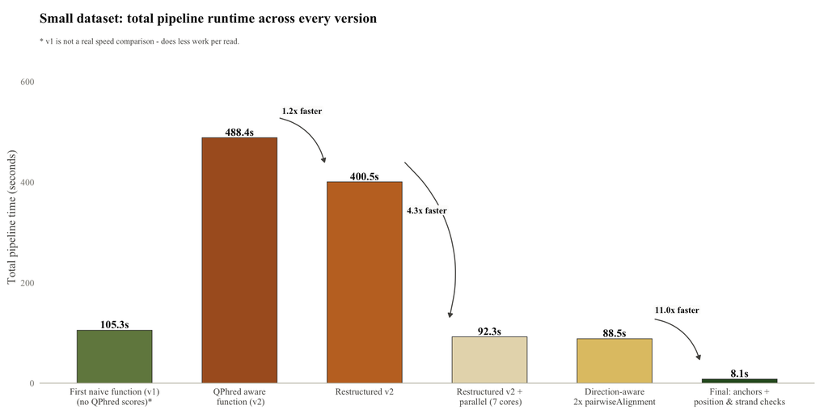

```r
# Shared editable variables and helper functions. This chunk always compares both data sets, small and big.
# Folders for timing logs and output paths
speed_logs_small <- "Results/small/Genotypes_results/old/Identified_ASP_genotypes"
speed_logs_big <- "Results/big/Genotypes_results/old/Identified_ASP_genotypes"
out_dir_speed_opt_small <- "Results/small/Graphics/Speed_Optimization_Analysis"
out_dir_speed_opt <- "Results/big/Graphics/Speed_Optimization_Analysis"
dir.create(out_dir_speed_opt_small, recursive = TRUE, showWarnings = FALSE)
dir.create(out_dir_speed_opt, recursive = TRUE, showWarnings = FALSE)

locus_row_regex <- "^\\[locus \\d+/\\d+\\] (\\S+) \\((\\d+) reads" #[locus 3/33] BICF2G630340139, group 1 for loci, group 2 for reads

#labels
speed_label <- function(before, after) {
  ifelse(after <= before, sprintf("%.1fx faster", before / after), sprintf("%.1fx slower", after / before))
}

# Plot function for both dataset using total time and added arrows
plot_total_time_f <- function(totals, palette, from_bar, to_bar, title, show_minutes) {
  y_max <- max(totals$total_seconds)
  label_gap <- y_max * 0.08 # space between a bar and the start of its arrow
  x_inset <- 0.32 # keeps the arrows off the bars

  bars <- totals %>%
    mutate(label = if (show_minutes) sprintf("%.0fs\n(%.1f min)", total_seconds, total_seconds / 60) else sprintf("%.1fs", total_seconds))

  # Arrows spacing and positioning
  arrows <- tibble(x = from_bar + x_inset,
                   xend = to_bar - x_inset,
                   y = totals$total_seconds[from_bar] + label_gap,
                   yend = totals$total_seconds[to_bar] + label_gap,
                   label = speed_label(totals$total_seconds[from_bar], totals$total_seconds[to_bar])) %>%
    mutate(x_mid = (x + xend) / 2,
           y_label = (y + yend) / 2 + y_max * 0.12)

  y_top <- max(arrows$y_label, arrows$y, totals$total_seconds + label_gap) * 1.15

  # Plot
  ggplot(bars, aes(x = version, y = total_seconds, fill = version)) +
    geom_col(width = 0.6, colour = "grey25", linewidth = 0.3) +
    geom_text(aes(label = label), vjust = -0.3, fontface = "bold", size = 4, colour = "#0b0b0b") +
    geom_curve(data = arrows, aes(x = x, y = y, xend = xend, yend = yend), inherit.aes = FALSE,
               curvature = -0.3, linewidth = 0.5, colour = "#52514e",
               arrow = arrow(length = unit(0.16, "cm"), type = "closed")) +
    geom_label(data = arrows, aes(x = x_mid, y = y_label, label = label), inherit.aes = FALSE,
               size = 3.3, fontface = "bold", colour = "#0b0b0b",
               fill = "#fcfcfb", linewidth = 0, label.padding = unit(0.12, "lines")) +
    scale_fill_manual(values = palette, guide = "none") +
    scale_y_continuous(expand = expansion(mult = c(0, 0.06)), limits = c(0, y_top)) +
    labs(title = title,
         subtitle = "\n* v1 is not a real speed comparison - does less work per read.",
         x = NULL,
         y = "Total pipeline time (seconds)") +
    theme_minimal(base_family = plot_font, base_size = 12) +
    theme(plot.title = element_text(face = "bold", colour = "#0b0b0b", margin = margin(b = 4)),
          plot.subtitle = element_text(size = 8.5, colour = "#52514e"),
          plot.margin = margin(t = 14, r = 14, b = 8, l = 8),
          panel.grid = element_blank(),
          axis.line.x = element_line(colour = "#c3c2b7", linewidth = 0.4),
          axis.ticks = element_blank(),
          axis.text.x = element_text(colour = "#52514e"),
          axis.text.y = element_text(colour = "#898781"),
          axis.title.y = element_text(colour = "#52514e"))
}

# Plot for small dataset
v1_naive_small <- read_tsv(file.path(speed_logs_small, "v1_old_naive_genotyper/very_first_timing_log.tsv"), show_col_types = FALSE)
v2_Qscores_small <- read_tsv(file.path(speed_logs_small, "v2_quality_scoring_before_restructuring/original_fixed_timing_log.tsv"), show_col_types = FALSE)
v3_Qscore_restructured_small <- read_tsv(file.path(speed_logs_small, "v3_quality_scoring_restructured/restructured_timing_log_parallel.tsv"), show_col_types = FALSE)
v4_parallel_4pwalign_small <- read_tsv(file.path(speed_logs_small, "v4_quality_scoring_parallel_4pwalign/restructured_timing_log_parallel.tsv"), show_col_types = FALSE)
v5_parallel_2pwalign_small <- read_tsv(file.path(speed_logs_small, "v5_quality_scoring_parallel_2pwalign/restructured_timing_log_parallel.tsv"), show_col_types = FALSE)
v6_final_anchored_small <- read_tsv(file.path(speed_logs_small, "v11_3anchors_agreementTRUE_strand_check/restructured_timing_log_parallel.tsv"), show_col_types = FALSE)

# Total time needed for finishing the analysis
v1_total_small <- filter(v1_naive_small, step == "TOTAL PIPELINE")$seconds
v2_total_small <- sum(filter(v2_Qscores_small, grepl(locus_row_regex, step))$seconds) # no total pipeline log, summing over the steps
v3_total_small <- filter(v3_Qscore_restructured_small, step == "TOTAL PIPELINE")$seconds
v4_total_small <- filter(v4_parallel_4pwalign_small, step == "TOTAL PIPELINE")$seconds
v5_total_small <- filter(v5_parallel_2pwalign_small, step == "TOTAL PIPELINE")$seconds
v6_total_small <- filter(v6_final_anchored_small, step == "TOTAL PIPELINE")$seconds
v5_scoring_small <- sum(filter(v5_parallel_2pwalign_small, grepl(locus_row_regex, step))$seconds) # again summed over loci
v6_scoring_small <- sum(filter(v6_final_anchored_small, grepl(locus_row_regex, step))$seconds)

# Bar colours in order
palette_small <- c(
  "First naive function (v1)\n(no QPhred scores)*" = "#72874E",
  "QPhred aware\n function (v2)" = "#AB5D26",
  "Restructured v2" = "#C3722A",
  "Restructured v2 +\n parallel (7 cores)" = "#E6DAB9",
  "Direction-aware\n2x pairwiseAlignment" = "#E1C473",
  "Final: anchors +\nposition & strand checks" = "#2C5724")

totals_small <- tibble(version = factor(names(palette_small), levels = names(palette_small)),
                       total_seconds = c(v1_total_small, v2_total_small, v3_total_small, v4_total_small, v5_total_small, v6_total_small))

# arrows from 2 to 3 and 3 to 4 and so on.
plot_total_time_small <- plot_total_time_f(totals_small, palette_small, from_bar = c(2, 3, 5), to_bar = c(3, 4, 6),
                                           title = "Small dataset: total pipeline runtime across every version", show_minutes = FALSE)
print(plot_total_time_small)
```

```r
ggsave(file.path(out_dir_speed_opt_small, "small_dataset_total.png"), plot_total_time_small, width = 12, height = 6, dpi = 300, bg = "white")
ggsave(file.path(out_dir_speed_opt_small, "small_dataset_total.pdf"), plot_total_time_small, width = 12, height = 6, device = cairo_pdf)

kable(transmute(totals_small, version = gsub("\n", " ", version), seconds = round(total_seconds, 1),
                faster_than_v2 = round(v2_total_small / total_seconds, 2)))
```

| version | seconds | faster_than_v2 |
| --- | --- | --- |
| First naive function (v1) (no QPhred scores)* | 105.3 | 4.64 |
| QPhred aware function (v2) | 488.4 | 1.00 |
| Restructured v2 | 400.5 | 1.22 |
| Restructured v2 + parallel (7 cores) | 92.3 | 5.29 |
| Direction-aware 2x pairwiseAlignment | 88.5 | 5.52 |
| Final: anchors + position & strand checks | 8.1 | 60.43 |

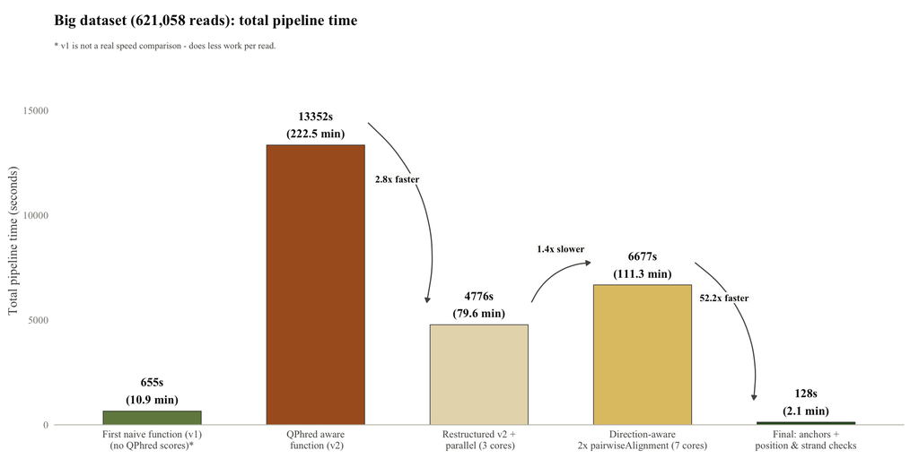

```r
# Plot for the big dataset
v1_naive_big <- read_tsv(file.path(speed_logs_big, "v1_old_naive_genotyper/very_first_timing_log.tsv"), show_col_types = FALSE)
v2_Qscores_big <- read_tsv(file.path(speed_logs_big, "v2_quality_scoring_before_restructuring/original_fixed_timing_log.tsv"), show_col_types = FALSE)
v4_parallel_4pwalign_big <- read_tsv(file.path(speed_logs_big, "v4_quality_scoring_parallel_4pwalign/restructured_timing_log_parallel.tsv"), show_col_types = FALSE)
v5_parallel_2pwalign_7cores_big <- read_tsv(file.path(speed_logs_big, "v5_quality_scoring_parallel_2pwalign_7cores/restructured_timing_log_parallel.tsv"), show_col_types = FALSE)
v6_final_big <- read_tsv(file.path(speed_logs_big, "v11_3anchors_agreementTRUE_strand_check/restructured_timing_log_parallel.tsv"), show_col_types = FALSE)

# these five names are used by the spiral chunk
v1_naive_pipeline_total_big <- filter(v1_naive_big, step == "TOTAL PIPELINE")$seconds
v2_Qscores_pipeline_total_big <- filter(v2_Qscores_big, step == "TOTAL PIPELINE")$seconds
v4_parallel_4pwalign_pipeline_total_big <- filter(v4_parallel_4pwalign_big, step == "TOTAL PIPELINE")$seconds
v5_pipeline_total_big <- filter(v5_parallel_2pwalign_7cores_big, step == "TOTAL PIPELINE")$seconds
v6_pipeline_total_big <- filter(v6_final_big, step == "TOTAL PIPELINE")$seconds

# number of reads in the big dataset
n_reads_total_big <- sum(as.integer(sub(paste0(locus_row_regex, ".*"), "\\2", grep(locus_row_regex, v4_parallel_4pwalign_big$step, value = TRUE))))

palette_big <- c(
  "First naive function (v1)\n(no QPhred scores)*" = "#72874E",
  "QPhred aware\n function (v2)" = "#AB5D26",
  "Restructured v2 +\n parallel (3 cores)" = "#E6DAB9",
  "Direction-aware\n2x pairwiseAlignment (7 cores)" = "#E1C473",
  "Final: anchors +\nposition & strand checks" = "#2C5724")

totals_big <- tibble(version = factor(names(palette_big), levels = names(palette_big)),
                     total_seconds = c(v1_naive_pipeline_total_big, v2_Qscores_pipeline_total_big, v4_parallel_4pwalign_pipeline_total_big,
                                       v5_pipeline_total_big, v6_pipeline_total_big)) %>%
  mutate(reads_per_sec = n_reads_total_big / total_seconds)

# arrows similar as before
plot_total_time_big <- plot_total_time_f(totals_big, palette_big, from_bar = c(2, 3, 4), to_bar = c(3, 4, 5),
                                         title = sprintf("Big dataset (%s reads): total pipeline time", format(n_reads_total_big, big.mark = ",")),
                                         show_minutes = TRUE)
print(plot_total_time_big)
```

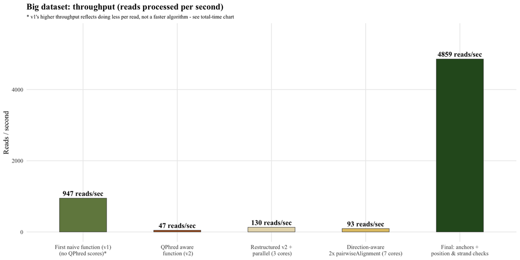

```r
ggsave(file.path(out_dir_speed_opt, "bigdataset_total_pipeline.png"), plot_total_time_big, width = 12, height = 6, dpi = 300, bg = "white")
ggsave(file.path(out_dir_speed_opt, "bigdataset_total_pipeline.pdf"), plot_total_time_big, width = 12, height = 6, device = cairo_pdf)

# reads processed per second
plot_reads_per_second_big <- ggplot(totals_big, aes(x = version, y = reads_per_sec, fill = version)) +
  geom_col(width = 0.5, colour = "grey25", linewidth = 0.3) +
  geom_text(aes(label = sprintf("%.0f reads/sec", reads_per_sec)), vjust = -0.5, fontface = "bold") +
  scale_fill_manual(values = palette_big, guide = "none") +
  expand_limits(y = max(totals_big$reads_per_sec) * 1.15) +
  labs(title = "Big dataset: throughput (reads processed per second)",
       subtitle = "* v1's higher throughput reflects doing less per read, not a faster algorithm - see total-time chart",
       x = NULL,
       y = "Reads / second") +
  theme_minimal(base_family = plot_font, base_size = 12) +
  theme(plot.title = element_text(face = "bold"), plot.subtitle = element_text(size = 9), panel.grid.minor = element_blank())

print(plot_reads_per_second_big)
```

```r
ggsave(file.path(out_dir_speed_opt, "bigdataset_throughput.png"), plot_reads_per_second_big, width = 12, height = 6, dpi = 300, bg = "white")
ggsave(file.path(out_dir_speed_opt, "bigdataset_throughput.pdf"), plot_reads_per_second_big, width = 12, height = 6, device = cairo_pdf)

# time of each part of the final run and banners
phase_df_big <- v6_final_big %>%
  filter(grepl("^Part [123] total", step)) %>%
  mutate(phase = substr(step, 1, 6), pct = 100 * seconds / v6_pipeline_total_big)

kable(transmute(totals_big, version = gsub("\n", " ", version), seconds = round(total_seconds), minutes = round(total_seconds / 60, 1),
                reads_per_sec = round(reads_per_sec), faster_than_v2 = round(v2_Qscores_pipeline_total_big / total_seconds, 1)))
```

| version | seconds | minutes | reads_per_sec | faster_than_v2 |
| --- | --- | --- | --- | --- |
| First naive function (v1) (no QPhred scores)* | 655 | 10.9 | 947 | 20.4 |
| QPhred aware function (v2) | 13352 | 222.5 | 47 | 1.0 |
| Restructured v2 + parallel (3 cores) | 4776 | 79.6 | 130 | 2.8 |
| Direction-aware 2x pairwiseAlignment (7 cores) | 6677 | 111.3 | 93 | 2.0 |
| Final: anchors + position & strand checks | 128 | 2.1 | 4859 | 104.5 |

```r
cat(sprintf("  v2 -> v4: %s | v5 -> final: %s | v2 -> final: %s\n",
            speed_label(v2_Qscores_pipeline_total_big, v4_parallel_4pwalign_pipeline_total_big),
            speed_label(v5_pipeline_total_big, v6_pipeline_total_big),
            speed_label(v2_Qscores_pipeline_total_big, v6_pipeline_total_big)))
```

```
  v2 -> v4: 2.8x faster | v5 -> final: 52.2x faster | v2 -> final: 104.5x faster
```

```r
cat(sprintf("  Phase breakdown (final run): %s\n",
            paste(sprintf("%s = %.1fs (%.1f%%)", phase_df_big$phase, phase_df_big$seconds, phase_df_big$pct), collapse = ", ")))
```

```
  Phase breakdown (final run): Part 1 = 87.5s (68.5%), Part 2 = 36.4s (28.5%), Part 3 = 3.2s (2.5%)
```

```r
cat(" * v1 is not an apples-to-apples speed comparison - see plot subtitles.\n")
```

```
 * v1 is not an apples-to-apples speed comparison - see plot subtitles.
```

## 13 Du Bois plots for speed optimization analysis and SNP read base quality

This chunk contains plots for SNP read base qaulity and speed optimization using Du Bois data visualization as refernce for the plot with changed colours. Code for this was built by Pat Schloss (Riffomonas), I just used my data (https://riffomonas.org/code_club/2025-02-17-panel-27).

```r
# Du Bois plate 27 style pies: quality of the read base on the SNP. First pie plot showing SNP read base quality of the correctly and wrongly called reads in HM pairs. Second plot shows SNP read base quality of the rarer allele in reads from HM (error or noise) and HT (actual real second allele just lower freq).

# Settings
out_dir_Dubois <- file.path(graphics_dir, "Dubois_plots")
dir.create(out_dir_Dubois, recursive = TRUE, showWarnings = FALSE)
pie_out_right_wrong <- file.path(out_dir_Dubois, sprintf("%sdataset_dubois_snp_quality_pie.png", dataset_name))
pie_out_rare_allele <- file.path(out_dir_Dubois, sprintf("%sdataset_dubois_minority_allele_quality_pie.png", dataset_name))

# Quality groups, q4 is best
pie_categories <- c("q4", "q3", "q2", "q1")
pie_fills <- c(q4 = "#A4B591FF", q3 = "#E1C473FF", q2 = "#C3722AFF", q1 = "#A12A19FF")
pie_legend <- tribble(
  ~x_dot, ~x_label, ~y, ~category, ~label,
  -0.90, -0.84, 0.12, "q4", "Q30 AND OVER",
  -0.90, -0.84, -0.12, "q3", "Q20 TO Q29",
   0.90, 0.84, 0.12, "q2", "Q10 TO Q19",
   0.90, 0.84, -0.12, "q1", "UNDER Q10"
) #593722FF, #834D24FF, #AB5D26FF, #C3722AFF, #E1C473FF, #E6DAB9FF, #A4B591FF, #55804DFF, #416C39FF, #2C5724FF

# Data preparation
pie_reference <- ref %>%
  filter(!is.na(genotype)) %>%
  transmute(barcode = sample,
            locus,
            ref_allele = substr(genotype, 1, 1), #separates genotype
            zygosity = ifelse(substr(genotype, 1, 1) == substr(genotype, 2, 2), "hom", "het")) # labels for genotypes

pie_reads <- read_tsv(asp_reads_path, col_select = c(barcode, locus, called_allele, snp_position_quality),
                      col_types = cols(barcode = "c", locus = "c", called_allele = "c", snp_position_quality = "d")) %>%
  filter(!is.na(called_allele)) %>% # counted reads only
  inner_join(pie_reference, by = c("barcode", "locus")) %>% # pairs with a ref genotype
  mutate(category = as.character(cut(snp_position_quality, c(-Inf, 9, 19, 29, Inf), #puts each one in a quality group
                                     labels = c("q1", "q2", "q3", "q4"))))

# The drawing function (same layout for both pies)
pie_draw <- function(reads, top_label, bottom_label, title, caption) { # It takes reads for one pie chart already labeled with top or bottom
  counts <- reads %>%
    count(half, category) %>% # Counts reads per half and quality category
    complete(half = c("top", "bottom"), category = pie_categories, fill = list(n = 0)) %>% # Adds missing combinations
    group_by(half) %>%
    mutate(percent = 100 * n / sum(n), half_n = sum(n)) %>% # Creates %
    ungroup()
print(kable(counts, digits = 1))

  slices <- counts %>%
    select(half, category, percent) %>%
    bind_rows(tibble(half = c("top", "bottom"), category = "blank", percent = 60)) %>% # Creates two invisible blank slices
    mutate(slice = factor(paste(half, category, sep = "_"), levels = c("top_blank", paste0("top_", rev(pie_categories)),
                                                                       "bottom_blank", paste0("bottom_", rev(pie_categories))))) %>%
    arrange(slice) %>%
    mutate(theta = 2 * pi * percent / sum(percent), # Eeach slice angle in radians
           final_theta = cumsum(theta) - first(theta) / 2, # Turns the pie back by half
           initial_theta = lag(final_theta, default = 0)) %>%
    filter(category != "blank", percent > 0) # Removes blanks

  # The outline of each slice: center, then along the arc, back to the center
  wedges <- slices %>%
      mutate(points = Map(function(from, to) {
      angles <- seq(from, to, length.out = 200) # Gives the function a starting and ending angle and 200 in between for a smooth arc
      tibble(x = c(0, cos(angles), 0), y = c(0, sin(angles), 0))
    }, initial_theta, final_theta)) %>%
    unnest(points)

  labels <- slices %>%
    mutate(mid = (initial_theta + final_theta) / 2,
           radius = ifelse(percent >= 10, 0.62, 0.86), # for small slices label is further out
           size = ifelse(percent >= 10, 11, 8),
           x = radius * cos(mid),
           y = radius * sin(mid),
           text = sprintf("%.0f%%", percent))

  n_top <- counts$half_n[counts$half == "top"][1]
  n_bottom <- counts$half_n[counts$half == "bottom"][1]

  ggplot(wedges, aes(x, y, group = slice, fill = category)) +
    geom_polygon(show.legend = FALSE, colour = "black", linewidth = 0.1) +
    geom_text(data = labels, aes(x, y, label = text, size = size / .pt), inherit.aes = FALSE, family = plot_font) +
    geom_point(data = pie_legend, aes(x_dot, y, fill = category), inherit.aes = FALSE,
               shape = 21, size = 7, stroke = 0.25, show.legend = FALSE) +
    geom_text(data = pie_legend, aes(x_label, y, label = label, hjust = ifelse(x_label < 0, 0, 1)), inherit.aes = FALSE,
              family = plot_font, size = 6.5 / .pt) +
    annotate("text", x = 0, y = c(1.1, -1.1), family = plot_font, size = 8 / .pt,
             label = c(sprintf(top_label, format(n_top, big.mark = ",")),
                       sprintf(bottom_label, format(n_bottom, big.mark = ",")))) +
    coord_equal(xlim = c(-1, 1), ylim = c(-1, 1), expand = FALSE, clip = "off") +
    scale_fill_manual(values = pie_fills) +
    scale_size_identity() +
    labs(title = title, caption = caption, x = NULL, y = NULL) +
    theme(plot.title = element_text(family = plot_font, size = 12, hjust = 0.5, margin = margin(t = 20, b = 35)),
          plot.caption = element_text(family = plot_font, size = 6, hjust = 0.5, margin = margin(t = 30)),
          axis.text = element_blank(),
          axis.ticks = element_blank(),
          panel.grid = element_blank(),
          panel.background = element_rect(fill = "white", colour = NA),
          plot.background = element_rect(fill = "white", colour = NA),
          plot.margin = margin(b = 30, l = 80, r = 80))
}


# 1. Pie plot for right vs wrong reads in HM pairs
pie_right_wrong_reads <- pie_reads %>%
  filter(zygosity == "hom", !is.na(category)) %>%
  mutate(half = ifelse(called_allele == ref_allele, "top", "bottom"))

pie_fig_right_wrong <- pie_draw(
  pie_right_wrong_reads,
  top_label = "CORRECTLY CALLED READS (%s).",
  bottom_label = "WRONGLY CALLED READS (%s).",
  title = "READ BASE QUALITY ON THE SNP.",
  caption = sprintf("%s DATASET; READS FROM SAMPLE-LOCUS PAIRS THAT ARE HOMOZYGOUS IN THE REFERENCE.", toupper(dataset_name)))
```

| half | category | n | percent | half_n |
| --- | --- | --- | --- | --- |
| bottom | q1 | 0 | 0.0 | 4009 |
| bottom | q2 | 2924 | 72.9 | 4009 |
| bottom | q3 | 605 | 15.1 | 4009 |
| bottom | q4 | 480 | 12.0 | 4009 |
| top | q1 | 0 | 0.0 | 453819 |
| top | q2 | 65412 | 14.4 | 453819 |
| top | q3 | 94892 | 20.9 | 453819 |
| top | q4 | 293515 | 64.7 | 453819 |

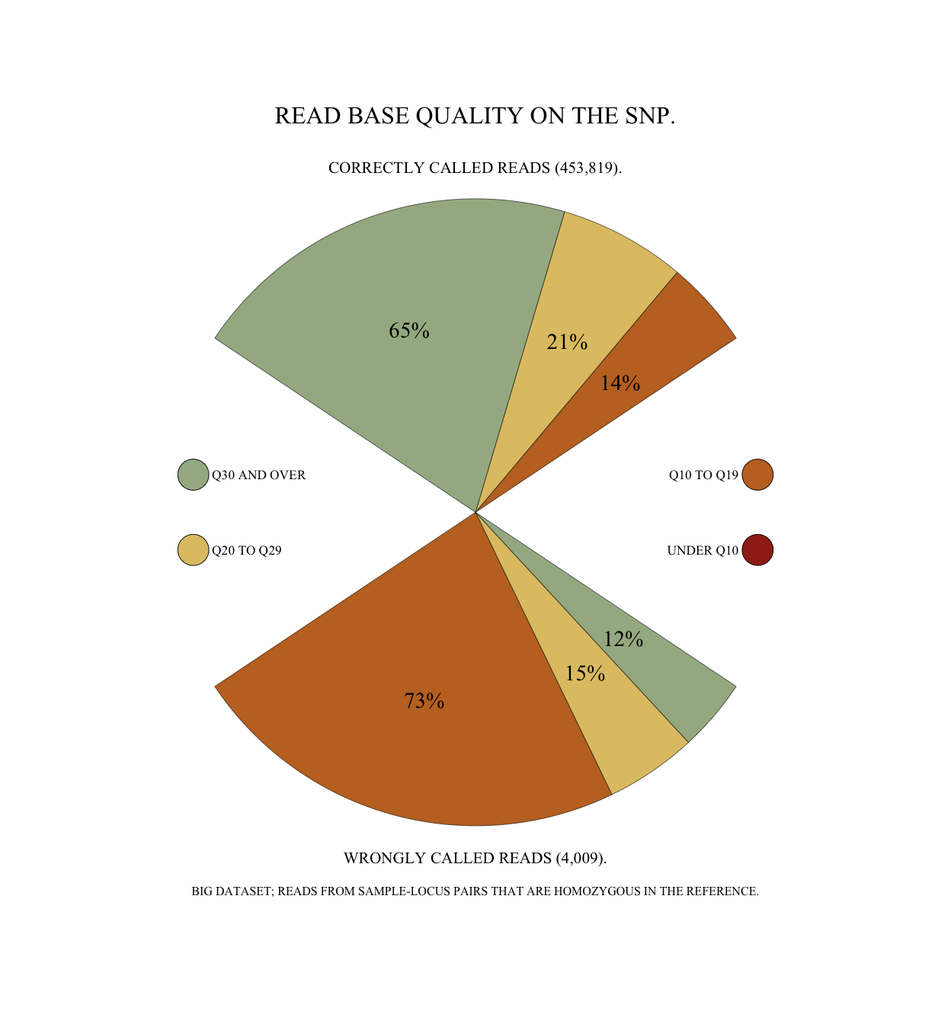

```r
print(pie_fig_right_wrong)
```

```r
ggsave(pie_out_right_wrong, pie_fig_right_wrong, width = 6.5, height = 7, dpi = 300)
ggsave(sub("\\.png$", ".pdf", pie_out_right_wrong), pie_fig_right_wrong, width = 6.5, height = 7, device = cairo_pdf)

# 2. Pie plot, reads of the rarer allele, HM (miscalls or noise) vs HT pairs
pie_rare_allele_reads <- pie_reads %>%
  add_count(barcode, locus, called_allele, name = "allele_n") %>%
  group_by(barcode, locus) %>%
  filter(called_allele != called_allele[which.max(allele_n)]) %>%
  ungroup() %>%
  filter(!is.na(category)) %>%
  mutate(half = ifelse(zygosity == "hom", "top", "bottom"))

pie_fig_rare_allele <- pie_draw(
  pie_rare_allele_reads,
  top_label = "RARER ALLELE IN HOMOZYGOTES: ERRORS (%s READS).",
  bottom_label = "RARER ALLELE IN HETEROZYGOTES: REAL SECOND ALLELE (%s READS).",
  title = "THE RARER ALLELE READ BASE\nQUALITY ON THE SNP.",
  caption = sprintf("%s DATASET; RARER ALLELE = THE ALLELE FEWER READS CALL IN THAT SAMPLE AND LOCUS.", toupper(dataset_name)))
```

| half | category | n | percent | half_n |
| --- | --- | --- | --- | --- |
| bottom | q1 | 0 | 0.0 | 31024 |
| bottom | q2 | 4560 | 14.7 | 31024 |
| bottom | q3 | 6592 | 21.2 | 31024 |
| bottom | q4 | 19872 | 64.1 | 31024 |
| top | q1 | 0 | 0.0 | 4007 |
| top | q2 | 2926 | 73.0 | 4007 |
| top | q3 | 605 | 15.1 | 4007 |
| top | q4 | 476 | 11.9 | 4007 |

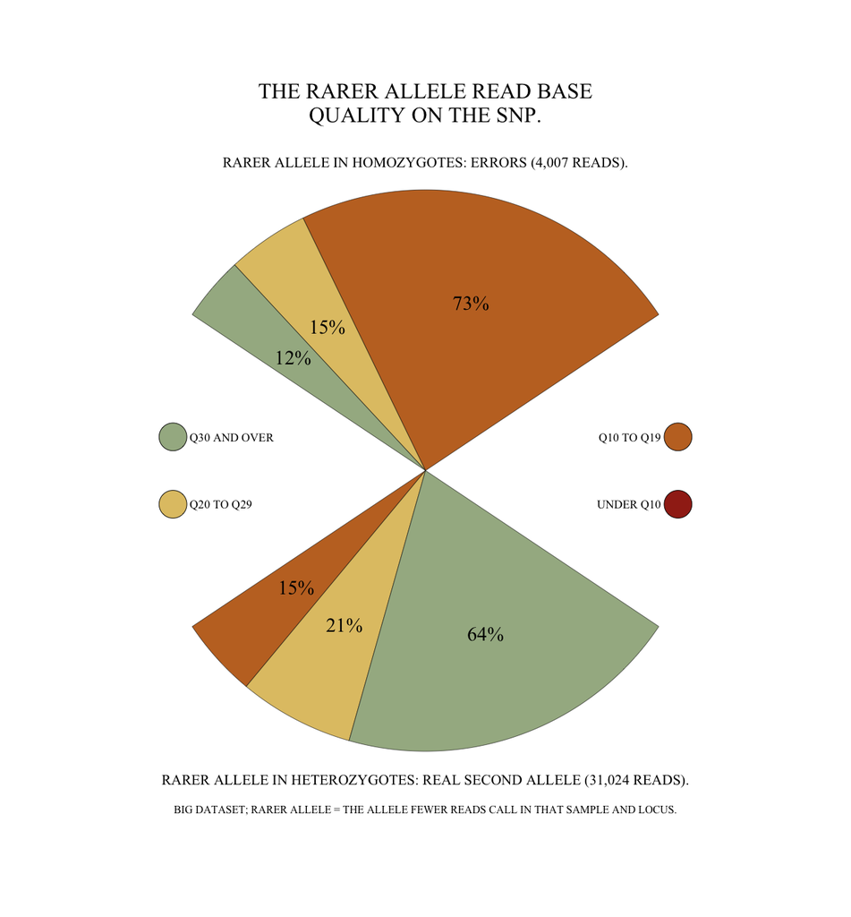

```r
print(pie_fig_rare_allele)
```

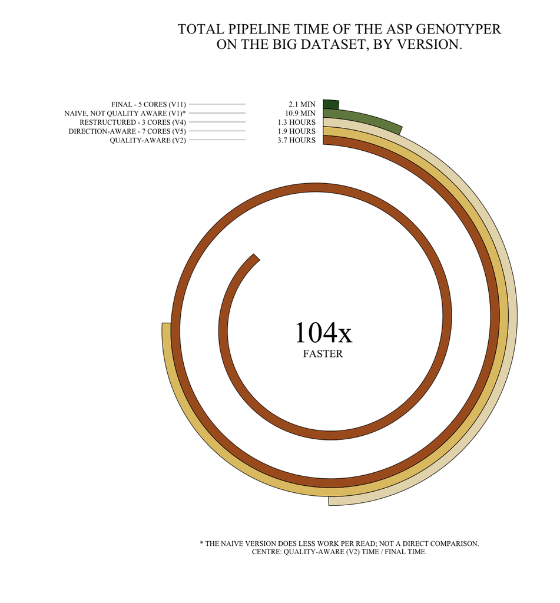

```r
ggsave(pie_out_rare_allele, pie_fig_rare_allele, width = 6.5, height = 7, dpi = 300)
ggsave(sub("\\.png$", ".pdf", pie_out_rare_allele), pie_fig_rare_allele, width = 6.5, height = 7, device = cairo_pdf)

# 3. Plot,Du Bois spiral (plate 25 style) for the big-dataset speed optimization. Each band one total pipeline time, lentgh proportional
spi_out_dir <- "Results/big/Graphics/Dubois_plots"
dir.create(spi_out_dir, recursive = TRUE, showWarnings = FALSE)

# total pipeline time per version in seconds
stopifnot(exists("v1_naive_pipeline_total_big"), exists("v2_Qscores_pipeline_total_big"),
          exists("v4_parallel_4pwalign_pipeline_total_big"), exists("v5_pipeline_total_big"),
          exists("v6_pipeline_total_big"))

spi_timings <- tribble(
  ~version, ~seconds,
  "NAIVE, NOT QUALITY AWARE (V1)*", v1_naive_pipeline_total_big,
  "QUALITY-AWARE (V2)", v2_Qscores_pipeline_total_big,
  "RESTRUCTURED - 3 CORES (V4)", v4_parallel_4pwalign_pipeline_total_big,
  "DIRECTION-AWARE - 7 CORES (V5)", v5_pipeline_total_big,
  "FINAL - 5 CORES (V11)", v6_pipeline_total_big) %>%
  arrange(seconds)

# centre number: quality-aware V2 time/final time (V1 not counted)
spi_speedup <- v2_Qscores_pipeline_total_big / v6_pipeline_total_big

spi_fills <- setNames(c("#2C5724FF", "#72874EFF", "#E6DAB9FF", "#E1C473FF", "#AB5D26FF"), spi_timings$version)
 #593722FF, #834D24FF, #AB5D26FF, #C3722AFF, #E1C473FF, #E6DAB9FF, #A4B591FF, #55804DFF, #416C39FF, #2C5724FF

spi_start_radius <- 15
spi_end_radius <- 9
spi_thickness <- 0.6
spi_min_length <- 0.35 # the smallest band would be almost invisible, minimum lentgth

# One row per version, position and label
spi_bands <- spi_timings %>%
  mutate(fraction = seconds / max(seconds), # the slowest version = 1 = the whole spiral
         offset = spi_thickness * (row_number() - 1), # each band sits one thickness further in
         label_y = spi_start_radius - offset - spi_thickness / 2,
         time_label = case_when(seconds >= 3600 ~ sprintf("%.1f HOURS", seconds / 3600),
                                seconds >= 60 ~ sprintf("%.1f MIN", seconds / 60),
                                TRUE ~ sprintf("%.0f SEC", seconds)),
         version = factor(version, levels = version))

# Spiral bands as polygons. Points along one spiral line, from the top (angle 9*pi/2) round to the lower left (angle 3*pi/4), with length = the distance travelled along the line so far
spi_spiral_line <- function(from_radius, to_radius) {
  radius <- seq(from_radius, to_radius, length.out = 2000)
  angle <- seq(9 * pi / 2, 3 * pi / 4, length.out = 2000)
  x <- radius * cos(angle)
  y <- radius * sin(angle)
  tibble(x = x, y = y, length = cumsum(c(0, sqrt(diff(x)^2 + diff(y)^2))))
}

# the full length of the outer edge of thevinnermost band (100 %)
spi_full_length <- with(tail(spi_bands, 1),
                        max(spi_spiral_line(spi_start_radius - offset, spi_end_radius - offset)$length))

# each band = its outer edge, cut to its share of the full length, then back along its inner edge
spi_polygons <- spi_bands %>%
  group_by(version) %>%
  reframe({
    outer <- spi_spiral_line(spi_start_radius - offset, spi_end_radius - offset)
    inner <- spi_spiral_line(spi_start_radius - offset - spi_thickness, spi_end_radius - offset - spi_thickness)
    keep <- outer$length <= max(fraction * spi_full_length, spi_min_length)
    tibble(x = c(outer$x[keep], rev(inner$x[keep])),
           y = c(outer$y[keep], rev(inner$y[keep])))
  })

# Plot
spi_fig <- ggplot(spi_polygons, aes(x, y, group = version, fill = version)) +
  geom_polygon(colour = "black", linewidth = 0.2, show.legend = FALSE) +
  geom_text(data = spi_bands, aes(x = -0.5, y = label_y, label = time_label), inherit.aes = FALSE,
            family = plot_font, size = 6.5 / .pt, hjust = 1) +
  geom_text(data = spi_bands, aes(x = -9.2, y = label_y, label = version), inherit.aes = FALSE,
            family = plot_font, size = 6 / .pt, hjust = 1) +
  annotate("segment", x = -9, xend = -5.2, y = spi_bands$label_y, yend = spi_bands$label_y, linewidth = 0.1) +
  annotate("text", x = 0, y = -0.6, label = sprintf("%.0fx", spi_speedup), family = plot_font, size = 25 / .pt) +
  annotate("text", x = 0, y = -2.0, label = "FASTER", family = plot_font, size = 9 / .pt) +
  coord_equal(expand = FALSE, clip = "off") +
  scale_fill_manual(values = spi_fills) +
  labs(title = "TOTAL PIPELINE TIME OF THE ASP GENOTYPER\nON THE BIG DATASET, BY VERSION.",
       caption = "* THE NAIVE VERSION DOES LESS WORK PER READ; NOT A DIRECT COMPARISON.\nCENTRE: QUALITY-AWARE (V2) TIME / FINAL TIME.",
       x = NULL, y = NULL) +
  theme(axis.text = element_blank(),
        axis.ticks = element_blank(),
        panel.grid = element_blank(),
        panel.background = element_rect(fill = "white", colour = NA),
        plot.background = element_rect(fill = "white", colour = NA),
        plot.title.position = "plot",
        plot.title = element_text(family = plot_font, size = 12, hjust = 0.5, margin = margin(t = 20, b = 40)),
        plot.caption.position = "plot",
        plot.caption = element_text(family = plot_font, size = 6, hjust = 0.5, margin = margin(t = 30)),
        plot.margin = margin(b = 40, l = 130, r = 30))

print(spi_fig)
```

```r
ggsave(file.path(spi_out_dir, "spiral_figure.png"), spi_fig, width = 6.5, height = 7, dpi = 300)
ggsave(file.path(spi_out_dir, "spiral_figure.pdf"), spi_fig, width = 6.5, height = 7, device = cairo_pdf)
```

## 14 BICF2G630340139 - Problematic locus analysis and diagnosis

Analysis and diagnosis of why this BICF2G630340139 locus fails at 13 different pairs and wrognly calls the HT genotpyes, where there should have been HM. A lot of correct T reads get removed by the position agreement rule because of primer hopping on T reads. T primer fits perfectly, but C primer hops depending on the SNP base read position quality. When quality is low it accepts a mismatch at SNP position and T primer correctly wins, but at higher SNP qualities the mismatch cost more, because higher qualities should be trusted more, when they mismatch they are penalized even more, that’s the overall rule with pairwiseAlignment function. At higher qualities its better for the C primer to take the gap penalty (first unchanged 8), which costs less and the SNP position changes to next base which is luckily C, so it only counts one gap penalty. T primer still wins, with high score margin, but position agreement rule cuts it out of voting, correctly. But the the problem is systematic and its purely settings based. Options for fixing this problem: make the indel gap penalty cost more (9), which works but this option also loses a lot more reads, which were correct but previously stayed just above the 0.65 threshold line. Changing the preassigned primer quality from 22L to 18L, which lowers the mismatch cost, theoretically lowers the ceilings of the highest possible mismatch penalty at higher qualities. The jist of both fixes is, if the gap penalty has to cost more than the mismatch penalty. Removing the anchor from just this one read doesn’t work, one could also try adding a relative margin filter in tandem with position agreement rule, since nearly all the T reads that get removed are high quality T reads.

```r
# Diagnosis analysis and plots for this problematic locus BICF2G630340139:
# Plot 1 (T read): why the C primer hops on a high-quality T read (the rule removes it)
# Plot 2 (C read): why the T primer never hops on a C read (the rule keeps it)
# Plot 3: % of T reads the rule removes under 7 different primer-quality/gap settings

stopifnot("run the setup chunk first (asp_functions.R)" = exists("score_reads_against_primers_2pwalign_v8") && exists("build_match_lookup"))

# Output path
hop_out_dir <- file.path(graphics_dir, "Problematic_Locus_Diagnosis")
dir.create(hop_out_dir, recursive = TRUE, showWarnings = FALSE)

# Settings for the original problem, reweritten here manually for visualization
# settings of the ORIGINAL problem (hop_ prefix, so they don't overwrite your current settings from setup)
hop_fastq_dir <- file.path("Data/Processed_data", dataset_name, "Demultiplexed_sequence_data/Identified_padded_sample_sequences")
hop_fastq_regex <- "_padded\\.fastq$"
hop_locus <- "BICF2G630340139"
hop_allele1 <- "T"
hop_allele2 <- "C"
hop_asp1 <- "CCTTCTTCCATATGCTAGGTGCTTT"
hop_asp2 <- "CCTTCTTCCATATGCTAGGTGCTTC"
hop_anchor <- "CCC"
hop_primer_quality <- 22L
hop_gap_opening <- 6
hop_gap_extension <- 2
hop_gap_cost <- hop_gap_opening + hop_gap_extension # price of an indel
hop_Q_low <- 10
hop_Q_high <- 35
hop_min_score_fraction <- 0.65
hop_q_cap <- 48 # plot 3: qualities above this are pooled
hop_min_reads <- 5 # plot 3: qualities with fewer T reads are not drawn
hop_snp_in_read <- 10 + nchar(hop_asp1) # read position of the allele base in the example reads
hop_window <- (hop_snp_in_read - 8):(hop_snp_in_read + 6) # read positions drawn in panel A

# 3. Plot, the 7 settings to compare in one line each
gap_grid <- tribble(
  ~label, ~gap_opening, ~primer_quality,
  "Q23, gap 8", 6, 23L,
  "Q22, gap 8 (original)", 6, 22L,
  "Q21, gap 8", 6, 21L,
  "Q20, gap 8", 6, 20L,
  "Q19, gap 8 (current)", 6, 19L,
  "Q18, gap 8", 6, 18L,
  "Q22, gap 9", 7, 22L)

# Colours
gap_style <- list(fills = c(read = "#e8e4dc", match = "#D3D8C5", mismatch = "#D99A85", gap = "#E1C473"),
                  ink = "#222222", red = error_colour, blue = "#476F84", gold = "#c9962a", grey = "grey45",
                  bg = "white",
                  settings = rev(c("#3D5941FF", "#778868FF", "#B5B991FF", "#F6EDBDFF", "#EDBB8AFF", "#DE8A5AFF", "#CA562CFF")))

# Plots theme
gap_theme_plot <- theme_minimal(base_family = plot_font, base_size = 9) +
  theme(plot.title = element_text(face = "bold", size = 10), plot.subtitle = element_text(size = 8, colour = "grey30"),
        panel.grid.minor = element_blank(), plot.background = element_rect(fill = gap_style$bg, colour = NA))
gap_theme_tiles <- theme_void(base_family = plot_font, base_size = 9) +
  theme(plot.title = element_text(face = "bold", size = 10), plot.subtitle = element_text(size = 8, colour = "grey30"),
        plot.background = element_rect(fill = gap_style$bg, colour = NA), plot.margin = margin(8, 8, 8, 8))

# Reads for the problematic locus from every .fastq file
problem_locus_files <- list.files(hop_fastq_dir, pattern = hop_fastq_regex, full.names = TRUE)

# Parsing of the .fastq files
one_read_parsing_f <- function(fastq_file) {
  fastq_lines <- readLines(fastq_file)
  headers <- fastq_lines[seq(1, length(fastq_lines), by = 4)]
  is_locus <- grepl(paste0('"experiment":"', hop_locus, '"'), headers, fixed = TRUE)
  tibble(direction = sub('.*"obimultiplex_direction":"([^"]*)".*', "\\1", headers[is_locus]),
         seq = fastq_lines[seq(2, length(fastq_lines), by = 4)][is_locus],
         qual = fastq_lines[seq(4, length(fastq_lines), by = 4)][is_locus])
}

problem_locus_reads <- bind_rows(lapply(problem_locus_files, one_read_parsing_f))
problem_locus_set <- DNAStringSet(problem_locus_reads$seq) # built once, used by every setting

# Scoring the reads
one_setting_scoring_f <- function(k) {
  setting <- gap_grid[k, ]
  result <- score_reads_against_primers_2pwalign_v8(problem_locus_set, problem_locus_reads$qual, problem_locus_reads$direction,
    hop_asp1, hop_asp2, hop_allele1, hop_allele2, hop_min_score_fraction,
    match_lookup = build_match_lookup(setting$primer_quality), primer_quality = setting$primer_quality, gap_opening = setting$gap_opening,
    gap_extension = hop_gap_extension, anchor = hop_anchor,
    input_type = "padded", # padded reads keep their orientation, so reverse reads need the rc primers
    threshold_type = "fraction") # the original min_score_fraction rule

  tibble(label = setting$label,
         called_allele_raw = result$called_allele_raw,
         snp_position_quality = result$snp_position_quality,
         snp_position_disagree = result$snp_position_disagree)
}

gap_scoring_results <- mclapply(seq_len(nrow(gap_grid)), one_setting_scoring_f, mc.cores = n_cores)
gap_failed <- vapply(gap_scoring_results, inherits, logical(1), "try-error") # a worker that crashed returns an error object instead of a tibble
if (any(gap_failed)) stop("scoring failed for ", sum(gap_failed), " settings, first error: ", gap_scoring_results[[which(gap_failed)[1]]])

all_reads_scores <- bind_rows(gap_scoring_results) %>%
  filter(!is.na(called_allele_raw), !is.na(snp_position_quality)) %>%
  mutate(label = factor(label, levels = gap_grid$label))

# Data prep
# Two example reads
hop_read_T <- paste0("ACGTAGGCTA", substr(hop_asp1, 1, nchar(hop_asp1) - 1), hop_allele1, "CCCC", "AGTCGTG")
hop_read_C <- paste0("ACGTAGGCTA", substr(hop_asp1, 1, nchar(hop_asp1) - 1), hop_allele2, "CCCC", "AGTCGTG")

# Aligns one read to the primer and returns aligned read and prienr with "-" for gaps, the starting position and score
align_one_read_f <- function(read, primer, Q, gap_open = hop_gap_opening) {
  a <- pairwiseAlignment(DNAString(read), DNAString(paste0(primer, hop_anchor)), type = "local-global",
                                  patternQuality = PhredQuality(strrep(intToUtf8(Q + 33), nchar(read))),
                                  subjectQuality = PhredQuality(intToUtf8(hop_primer_quality + 33)),
                                  gapOpening = gap_open, gapExtension = hop_gap_extension)

  list(read = as.character(pattern(a)), primer = as.character(subject(a)),
       start = start(pattern(a)), score = score(a))
}

# One tile per read base, turns one alignemnt into a table with one row per base
alignment_tiles_f <- function(al, primer_len, row) {
  r <- strsplit(al$read, "")[[1]]
  p <- strsplit(al$primer, "")[[1]]
  tibble(x = al$start - 1 + cumsum(r != "-"), base = p, read_base = r,
         primer_pos = ifelse(p == "-", NA, cumsum(p != "-")), row = row) %>%
    filter(r != "-") %>% # # filtering for no gaps
    mutate(status = case_when(base == "-" ~ "gap", base == read_base ~ "match", TRUE ~ "mismatch"),
           is_snp = !is.na(primer_pos) & primer_pos == primer_len)
}

# Points lsot by base quality
hop_match_lookup <- build_match_lookup(hop_primer_quality)
score_price_comparison <- tibble(Q = 0:45) %>%
  mutate(match = hop_match_lookup[Q + 1],
         mismatch_option = vapply(Q, mismatch_cost_f, numeric(1), hop_primer_quality), # base mismatch
         hop_C_read = match + hop_gap_cost) #

lowest_Q_to_hop <- score_price_comparison$Q[which(score_price_comparison$mismatch_option > hop_gap_cost)[1]]

# Panel C: reads removed by the rule per SNP-quality group, at the plots setting
quality_labels <- c("<10", "10-14", "15-19", "20-22", "23-25", "26-29", "30-34", "35-39", "40+")
all_reads_scores_removed <- all_reads_scores %>%
  filter(label == gap_grid$label[gap_grid$primer_quality == hop_primer_quality & gap_grid$gap_opening == hop_gap_opening][1]) %>%
  mutate(quality_bin = cut(snp_position_quality, c(-Inf, 9, 14, 19, 22, 25, 29, 34, 39, Inf), labels = quality_labels)) %>%
  group_by(called_allele_raw, quality_bin) %>%
  summarise(n = n(), removed = 100 * mean(snp_position_disagree), .groups = "drop") %>%
  mutate(xpos = as.integer(quality_bin))
kable(all_reads_scores_removed, digits = 1)
```

| called_allele_raw | quality_bin | n | removed | xpos |
| --- | --- | --- | --- | --- |
| C | <10 | 344 | 10.2 | 1 |
| C | 10-14 | 240 | 12.5 | 2 |
| C | 15-19 | 124 | 12.9 | 3 |
| C | 20-22 | 78 | 16.7 | 4 |
| C | 23-25 | 79 | 16.5 | 5 |
| C | 26-29 | 119 | 10.1 | 6 |
| C | 30-34 | 166 | 9.6 | 7 |
| C | 35-39 | 138 | 10.1 | 8 |
| C | 40+ | 178 | 2.8 | 9 |
| T | <10 | 782 | 7.5 | 1 |
| T | 10-14 | 608 | 12.3 | 2 |
| T | 15-19 | 496 | 15.7 | 3 |
| T | 20-22 | 284 | 21.8 | 4 |
| T | 23-25 | 326 | 79.8 | 5 |
| T | 26-29 | 638 | 95.1 | 6 |
| T | 30-34 | 1072 | 97.5 | 7 |
| T | 35-39 | 1088 | 98.5 | 8 |
| T | 40+ | 1274 | 99.2 | 9 |

```r
# panel C base, shared by plots 1 and 2
hop_last_pts <- slice_tail(all_reads_scores_removed, n = 1, by = called_allele_raw) # last point of each line, for the line labels
hop_panel_C <- ggplot(all_reads_scores_removed, aes(xpos, removed, colour = called_allele_raw, group = called_allele_raw)) +
  geom_line(linewidth = 0.8) +
  geom_point(size = 2.4) +
  geom_text(data = hop_last_pts, aes(label = paste(called_allele_raw, "reads")), hjust = -0.25, size = 3, show.legend = FALSE) +
  scale_x_continuous(breaks = seq_along(quality_labels), labels = quality_labels) +
  scale_y_continuous(limits = c(0, 100)) +
  coord_cartesian(clip = "off") +
  labs(subtitle = sprintf("%s: reads removed by the position disagreement rule by SNP base quality", hop_locus),
       x = "Phred quality of the SNP", y = "% of reads removed") +
  gap_theme_plot +
  theme(plot.margin = margin(5, 30, 5, 5))

# Plot 1: T read when C primer hops, it runs in local because the variables are shared, otherwise every single variable would need a different name
plot_T_read <- local({
  st <- gap_style
  win <- hop_window
  read <- hop_read_T

  al_T <- align_one_read_f(read, hop_asp1, hop_Q_high)
  al_C_low <- align_one_read_f(read, hop_asp2, hop_Q_low)
  al_C_high <- align_one_read_f(read, hop_asp2, hop_Q_high)
  C_high_mismatch_score <- align_one_read_f(read, hop_asp2, hop_Q_high, gap_open = 1000)$score # option not taken
  C_low_gap_score <- align_one_read_f(read, hop_asp1, hop_Q_low)$score - hop_gap_cost # option not taken

  rows <- c("Read (T allele)", "T primer + anchor", sprintf("C primer + anchor, SNP at Q%d", hop_Q_low),
            sprintf("C primer + anchor, SNP at Q%d", hop_Q_high))
  tiles <- bind_rows(tibble(x = seq_len(nchar(read)), base = strsplit(read, "")[[1]], row = rows[1], status = "read", is_snp = x == hop_snp_in_read),
                     alignment_tiles_f(al_T, nchar(hop_asp1), rows[2]),
                     alignment_tiles_f(al_C_low, nchar(hop_asp2), rows[3]),
                     alignment_tiles_f(al_C_high, nchar(hop_asp2), rows[4])) %>%
    mutate(y = match(row, rev(rows))) %>%
    filter(x %in% win)
  snp_at <- setNames(tiles$x[tiles$is_snp], tiles$row[tiles$is_snp])
  if (snp_at[[ rows[4]]] == snp_at[[ rows[2]]])
    warning("figure 1: the Q", hop_Q_high, " C-primer alignment did not hop with these settings")

  notes <- c("Two TT before the SNP position (T)",
             "Perfect fit",
             sprintf("Opt1: mismatch (%.1f) costs less than a gap (%.1f)", al_C_low$score, C_low_gap_score),
             sprintf("Opt2: gap (%.1f) costs less than a mismatch (%.1f)\nSNP position disagreement -> read removed",
                     al_C_high$score, C_high_mismatch_score))

  pA <- ggplot(tiles, aes(x, y)) +
    geom_tile(aes(fill = status), width = 0.92, height = 0.62, colour = NA) +
    geom_tile(data = filter(tiles, is_snp), width = 0.92, height = 0.62, fill = NA, colour = st$ink, linewidth = 0.9) +
    geom_text(aes(label = base), family = "mono", fontface = "bold", size = 4.2, colour = st$ink) +
    annotate("text", x = min(win) - 0.8, y = 4:1, label = rows, hjust = 1, size = 3, colour = st$ink) +
    annotate("text", x = max(win) + 0.8, y = 4:1, label = notes, hjust = 0, size = 2.7,
             colour = c(st$grey, st$grey, st$grey, st$red), lineheight = 0.9) +
    annotate("text", x = win, y = 4.45, label = win, size = 2.2, colour = st$grey) +
    annotate("text", x = max(win) - 3.5, y = 0.35, size = 2.6, colour = st$grey, label = "Boxed = aligned SNP position") +
    scale_fill_manual(values = st$fills, guide = "none") +
    scale_x_continuous(limits = c(min(win) - 9, max(win) + 12), expand = c(0, 0)) +
    scale_y_continuous(limits = c(0.2, 4.6)) +
    labs(title = "A On a T read C primer has two ways to align a read, on higher quality reads it takes the one with a gap",
         subtitle = sprintf("Real primers and %s anchor; read positions on top. Gap = %g + %g = %g points.",
                            hop_anchor, hop_gap_opening, hop_gap_extension, hop_gap_cost)) +
    gap_theme_tiles

  pB <- ggplot(filter(score_price_comparison, Q >= 3), aes(Q, mismatch_option)) +
    annotate("rect", xmin = lowest_Q_to_hop, xmax = 45, ymin = -Inf, ymax = Inf, fill = st$red, alpha = 0.07) +
    geom_hline(yintercept = hop_gap_cost, colour = st$gold, linewidth = 0.8) +
    geom_line(colour = st$ink, linewidth = 0.8) +
    geom_vline(xintercept = lowest_Q_to_hop, linetype = 2, colour = st$red) +
    annotate("text", x = 4, y = hop_gap_cost + 0.35, label = sprintf("Gap penalty = %g", hop_gap_cost),
             hjust = 0, size = 2.8, colour = "#9a7118") +
    annotate("text", x = 44, y = max(score_price_comparison$mismatch_option) - 0.6, label = "mismatch at the SNP", hjust = 1, size = 2.8) +
    annotate("text", x = lowest_Q_to_hop + 0.8, y = 2, label = sprintf("from Q%d the gap is cheaper\n-> the C primer hops", lowest_Q_to_hop),
             hjust = 0, size = 2.8, colour = st$red, lineheight = 0.9) +
    scale_x_continuous(breaks = seq(0, 45, 10)) +
    labs(title = "B  Which option is cheaper depends on read quality",
         subtitle = "Points lost by the C primer: mismatch option vs gap option",
         x = "Phred quality of the read bases",
         y = "Points lost") +
    gap_theme_plot

  pC <- hop_panel_C +
    annotate("rect", xmin = 4.5, xmax = 9.6, ymin = -Inf, ymax = Inf, fill = st$red, alpha = 0.07) + # quality range where the C primer hops
    scale_colour_manual(values = setNames(c(st$red, st$blue), c(hop_allele1, hop_allele2)), guide = "none") +
    labs(title = sprintf("C  Systematic error on the %s dataset", dataset_name))

  wrap_plots(pA, wrap_plots(pB, pC), ncol = 1, heights = c(1.1, 1)) &
    theme(plot.background = element_rect(fill = st$bg, colour = NA))
})


# Plot 2: C read, primer never hops
plot_C_read <- local({
  st <- gap_style
  snp <- hop_snp_in_read
  win <- hop_window
  read <- hop_read_C
  read_T <- hop_read_T
  n <- nchar(hop_asp1)

  al_C <- align_one_read_f(read, hop_asp2, hop_Q_high)
  al_T_low <- align_one_read_f(read, hop_asp1, hop_Q_low)
  al_T_high <- align_one_read_f(read, hop_asp1, hop_Q_high)
  # score of the hop the T primer would need: perfect fit, minus the match of the unpaired base, minus the gap
  hop_option_score <- function(Q) align_one_read_f(read_T, hop_asp1, Q)$score - hop_match_lookup[Q + 1] - hop_gap_cost
```

```r
  hop_tiles <- tibble(x = c((snp - n + 1):(snp - 3), NA, snp - 2, snp - 1, snp + 0:2),
                      base = strsplit(paste0(hop_asp1, hop_anchor), "")[[1]],
                      primer_pos = seq_len(n + nchar(hop_anchor)))
  unpaired <- tibble(x = snp - 2.5,
                     y = 1.52,
                     base = hop_tiles$base[is.na(hop_tiles$x)])

  rows <- c("Read (C allele)", "C primer + anchor", sprintf("T primer + anchor, SNP at Q%d", hop_Q_low),
            sprintf("T primer + anchor, SNP at Q%d", hop_Q_high), "The hop the T primer would need")
  read_bases <- strsplit(read, "")[[1]]
  tiles <- bind_rows(tibble(x = seq_len(nchar(read)), base = strsplit(read, "")[[1]], row = rows[1], status = "read", is_snp = x == hop_snp_in_read),
                     alignment_tiles_f(al_C, nchar(hop_asp2), rows[2]),
                     alignment_tiles_f(al_T_low, n, rows[3]),
                     alignment_tiles_f(al_T_high, n, rows[4]),
                     hop_tiles %>% filter(!is.na(x)) %>%
                       mutate(read_base = read_bases[x], row = rows[5],
                              status = ifelse(base == read_base, "match", "mismatch"),
                              is_snp = primer_pos == n)) %>%
    mutate(y = match(row, rev(rows))) %>%
    filter(x %in% win)
  snp_at <- setNames(tiles$x[tiles$is_snp], tiles$row[tiles$is_snp])
  if (any(snp_at[rows[2:4]] != snp)) warning("figure 2: a real alignment hopped with these settings")

  notes <- c("Two TT before the SNP position",
             "Perfect fit",
             sprintf("Opt1: mismatch (%.1f) costs less than a gap (%.1f)", al_T_low$score, hop_option_score(hop_Q_low)),
             sprintf("Opt1: mismatch (%.1f) still costs less than a gap (%.1f)", al_T_high$score, hop_option_score(hop_Q_high)),
             "The hop is never chosen,\nbecause a gap plus a lost match always costs more")

  pA <- ggplot(tiles, aes(x, y)) +
    geom_tile(aes(fill = status), width = 0.92, height = 0.62, colour = NA) +
    geom_tile(data = filter(tiles, is_snp), width = 0.92, height = 0.62, fill = NA, colour = st$ink, linewidth = 0.9) +
    geom_text(aes(label = base), family = "mono", fontface = "bold", size = 4.2, colour = st$ink) +
    geom_tile(data = unpaired, aes(x, y), width = 0.8, height = 0.34, fill = st$fills[["gap"]], inherit.aes = FALSE) +
    geom_text(data = unpaired, aes(x, y, label = base), family = "mono", fontface = "bold", size = 3.2,
              colour = st$ink, inherit.aes = FALSE) +
    annotate("segment", x = unpaired$x, xend = unpaired$x, y = unpaired$y - 0.17, yend = 1.31, colour = st$ink, linewidth = 0.4) +
    annotate("text", x = unpaired$x - 0.6, y = unpaired$y, label = "Gap", hjust = 1, size = 2.5, colour = "#9a7118") +
    annotate("segment", x = snp - 1, xend = snp, y = 0.58, yend = 0.58, colour = st$grey,
             arrow = arrow(length = unit(1.5, "mm"), ends = "both")) +
    annotate("text", x = min(win) - 0.8, y = 5:1, label = rows, hjust = 1, size = 3,
             colour = c(rep(st$ink, 4), st$grey)) +
    annotate("text", x = max(win) + 0.8, y = 5:1, label = notes, hjust = 0, size = 2.7,
             colour = c(st$grey, st$grey, st$blue, st$blue, st$grey), lineheight = 0.9) +
    annotate("text", x = win, y = 5.45, label = win, size = 2.2, colour = st$grey) +
    annotate("text", x = max(win) - 3.0, y = 0.2, size = 2.6, colour = st$grey, label = "Boxed = aligned SNP position") +
    scale_fill_manual(values = st$fills, guide = "none") +
    scale_x_continuous(limits = c(min(win) - 9, max(win) + 12), expand = c(0, 0)) +
    scale_y_continuous(limits = c(0.05, 5.6)) +
    labs(title = "A  On a C read the T primer never hops: the hop would cost more than the mismatch it avoids",
         subtitle = sprintf("Real primers and %s anchor; read positions on top. Gap = %g + %g = %g points.",
                            hop_anchor, hop_gap_opening, hop_gap_extension, hop_gap_cost)) +
    gap_theme_tiles

  price_long <- score_price_comparison %>% filter(Q >= 3) %>%
    select(Q, `mismatch (option 1)` = mismatch_option, `hop: gap + lost match` = hop_C_read) %>%
    pivot_longer(-Q, names_to = "option", values_to = "lost")
  pB <- ggplot(price_long, aes(Q, lost, colour = option)) +
    geom_hline(yintercept = hop_gap_cost, colour = "grey70", linetype = 2) +
    geom_line(linewidth = 0.8) +
    geom_text(data = filter(price_long, Q == max(Q)), aes(label = option), hjust = 1, vjust = -0.8,
              size = 2.8, show.legend = FALSE) +
    annotate("text", x = 4, y = hop_gap_cost - 0.35, hjust = 0, size = 2.5, colour = "grey50",
             label = sprintf("Gap penalty = %g", hop_gap_cost)) +
    annotate("text", x = 25, y = 3.2, hjust = 0, size = 2.8, colour = st$blue, lineheight = 0.9,
             label = "the hop is always the more expensive option") +
    scale_colour_manual(values = c(`mismatch (option 1)` = st$ink, `hop: gap + lost match` = st$gold), guide = "none") +
    scale_x_continuous(breaks = seq(0, 45, 10)) +
    scale_y_continuous(limits = c(0, max(price_long$lost) + 1)) +
    labs(title = "B  The two lines never cross",
         subtitle = "Points the T primer loses on a C read, compared with a perfect fit",
         x = "Phred quality of the read bases", y = "points lost") +
    gap_theme_plot

  pC <- hop_panel_C +
    scale_colour_manual(values = setNames(c("grey70", st$blue), c(hop_allele1, hop_allele2)), guide = "none") +
    labs(title = sprintf("C  The %s dataset: C reads stay hidden", dataset_name))

  wrap_plots(pA, wrap_plots(pB, pC), ncol = 1, heights = c(1.1, 1)) &
    theme(plot.background = element_rect(fill = st$bg, colour = NA))
})


# Plot 3: Percentage of T reads removed by different settings for primery Q and indels penalties
plot_setting_comparison <- local({
  st <- gap_style
  T_reads <- filter(all_reads_scores, called_allele_raw == hop_allele1)

  # legend labels per setting
  totals <- T_reads %>%
    group_by(label) %>%
    summarise(pct_removed = 100 * mean(snp_position_disagree), .groups = "drop") %>%
    mutate(legend = paste0(label, ": ", sprintf("%.1f", pct_removed), " % removed"))
print(kable(totals, digits = 1))
```

```r
  # % of T reads removed per setting and per SNP quality (qualities above the cap pooled)
  removed_by_quality <- T_reads %>%
    mutate(q = pmin(snp_position_quality, hop_q_cap)) %>%
    group_by(label, q) %>%
    summarise(n = n(), removed = 100 * mean(snp_position_disagree), .groups = "drop") %>%
    filter(n >= hop_min_reads) %>%
    left_join(select(totals, label, legend), by = "label") %>%
    mutate(legend = factor(legend, levels = totals$legend))

  x_breaks <- seq(0, hop_q_cap, by = 4)
  x_labels <- ifelse(x_breaks == hop_q_cap, paste0(hop_q_cap, "+"), x_breaks)

  ggplot(removed_by_quality, aes(q, removed, colour = legend, linetype = legend, group = legend)) +
    geom_line(linewidth = 1.1) +
    scale_colour_manual(values = setNames(st$settings, totals$legend), name = NULL) +
    scale_linetype_manual(values = setNames(c(rep("solid", 6), "22"), totals$legend), name = NULL) +
    scale_x_continuous(breaks = x_breaks, labels = x_labels) +
    scale_y_continuous(limits = c(0, 100)) +
    labs(title = "Lowering the preassigned primer quality stops the rule from removing good T reads",
         subtitle = sprintf("%s, %s dataset: %% of T reads removed by the position-agreement rule", hop_locus, dataset_name),
         x = "Phred quality of the SNP",
         y = "% of T reads removed") +
    gap_theme_plot +
    theme(legend.position = "inside",
          legend.position.inside = c(0.98, 0.52),
          legend.justification = c(1, 0.5),
          legend.background = element_rect(fill = "white", colour = "black", linewidth = 0.4),
          legend.text = element_text(size = 9),
          legend.key.width = unit(2, "lines"),
          plot.margin = margin(5, 15, 5, 5))
})
```

| label | pct_removed | legend |
| --- | --- | --- |
| Q23, gap 8 | 70.1 | Q23, gap 8: 70.1 % removed |
| Q22, gap 8 (original) | 68.8 | Q22, gap 8 (original): 68.8 % removed |
| Q21, gap 8 | 65.9 | Q21, gap 8: 65.9 % removed |
| Q20, gap 8 | 56.5 | Q20, gap 8: 56.5 % removed |
| Q19, gap 8 (current) | 9.8 | Q19, gap 8 (current): 9.8 % removed |
| Q18, gap 8 | 6.5 | Q18, gap 8: 6.5 % removed |
| Q22, gap 9 | 8.2 | Q22, gap 9: 8.2 % removed |

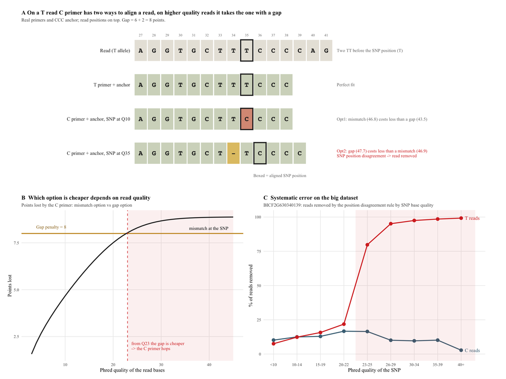

```r
print(plot_T_read)
```

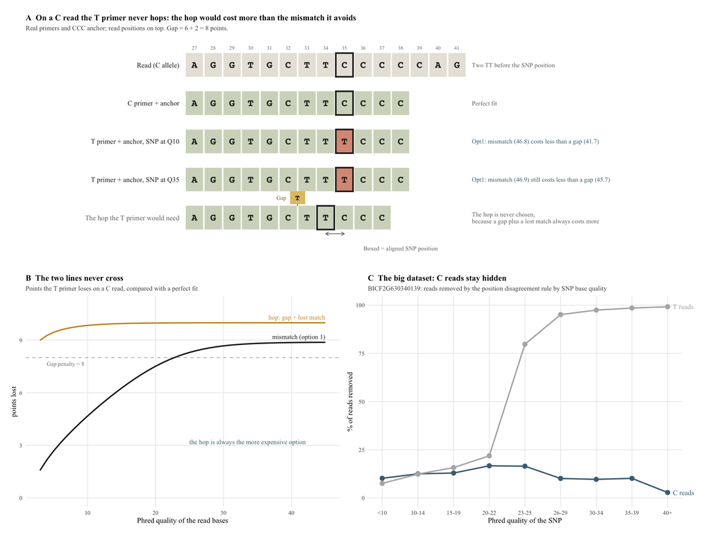

```r
ggsave(file.path(hop_out_dir, "alignment_hop_T_read.png"), plot_T_read, width = 12, height = 9, dpi = 300, bg = gap_style$bg)
ggsave(file.path(hop_out_dir, "alignment_hop_T_read.pdf"), plot_T_read, width = 12, height = 9, device = cairo_pdf)
print(plot_C_read)
```

```r
ggsave(file.path(hop_out_dir, "alignment_nohop_C_read.png"), plot_C_read, width = 12, height = 9, dpi = 300, bg = gap_style$bg)
ggsave(file.path(hop_out_dir, "alignment_nohop_C_read.pdf"), plot_C_read, width = 12, height = 9, device = cairo_pdf)
```

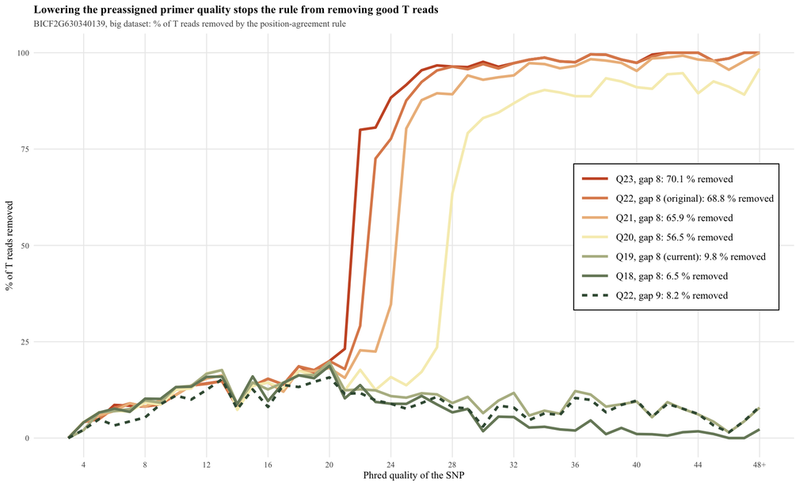

```r
print(plot_setting_comparison)
```

```r
ggsave(file.path(hop_out_dir, "primer_quality_settings.png"), plot_setting_comparison, width = 10, height = 6, dpi = 300, bg = gap_style$bg)
ggsave(file.path(hop_out_dir, "primer_quality_settings.pdf"), plot_setting_comparison, width = 10, height = 6, device = cairo_pdf)
```

## 15 Demultiplxeing and filtration process visualized - Sankey, Upset, Barplot

```r
# Input and output paths
out_dir_sankey <- file.path(graphics_dir, "Demultiplexing_and_Filtration_Visualization")
dir.create(out_dir_sankey, recursive = TRUE, showWarnings = FALSE)
raw_basecalled_dir <- file.path("Data/Raw_data", dataset_name) # Raw reads
counts_cache_file <- file.path(out_dir_sankey, "fastq_read_counts_all.rds") # cache for fastq counts
demultiplexed_dir <- file.path("Data/Processed_data", dataset_name, "Demultiplexed_sequence_data")
dorado_dir <- file.path(demultiplexed_dir, "Dorado_demultiplexed_by_sample")
obi_identified_dir <- file.path(demultiplexed_dir, "Identified_sample_sequences_Obi4")
obi_unidentified_dir <- file.path(demultiplexed_dir, "Unidentified_sample_sequences_Obi4")

dorado_file_pattern <- "^(barcode\\d+|unclassified)\\.fastq(\\.gz)?$"
recount_fastq <- FALSE # TRUE = counts the fastq files again

stopifnot("run the setup chunk first, panel is needed for the homopolymers" = exists("panel"))

# Reading the fastq files and returns read ID for each and position. Used for IDs in Obimultiplexing and further for Sankey and amplicon assosication
fastq_read_ids <- function(path) {
  fastq_lines <- readLines(path)
  sub(" .*$", "", substring(fastq_lines[seq(1, length(fastq_lines), by = 4)], 2))
}

# counts how many reads in the fastq files, returns a table with one row per read. Its used for Raw basecalled reads and Dorado files
count_fastq_records <- function(dir, pattern = "\\.(fastq|fq)(\\.gz)?$") {
  files <- list.files(dir, pattern = pattern, full.names = TRUE)
  stopifnot(length(files) > 0)
  tibble(file = basename(files),
         records = vapply(files, function(f) length(fastq_read_ids(f)), numeric(1), USE.NAMES = FALSE))
}

# Counts amplicons from ObiTools4 per file and checks where they come from
count_obi_amplicons <- function(dir, pattern) {
  files <- list.files(dir, pattern = pattern, full.names = TRUE)
  stopifnot(length(files) > 0)
  parent_reads <- lapply(files, function(f) sub("_sub.*$", "", fastq_read_ids(f)))
  bind_rows(tibble(file = basename(files),
                   original_read = vapply(parent_reads, function(p) length(unique(p)), numeric(1)),
                   amplicons = vapply(parent_reads, length, numeric(1))),
            tibble(file = "TOTAL", original_read = length(unique(unlist(parent_reads))), amplicons = sum(lengths(parent_reads))))
}

# This part processes the reads based based on TRUE or false and if the RDS file exist. It takes quite elong so its better if you just cache it after first count
fastq_counts <- if (file.exists(counts_cache_file) && !recount_fastq) readRDS(counts_cache_file) else { # cached counts or count now
  new_counts <- list(raw = count_fastq_records(raw_basecalled_dir),
                     dorado = count_fastq_records(dorado_dir, dorado_file_pattern) %>%
                       mutate(barcode = sub(dorado_file_pattern, "\\1", file)),
                     obi = count_obi_amplicons(obi_identified_dir, "_identified\\.fastq(\\.gz)?$"),
                     obi_unidentified = count_obi_amplicons(obi_unidentified_dir, "_unidentified\\.fastq(\\.gz)?$"))
  saveRDS(new_counts, counts_cache_file)
  new_counts
}

dorado_counts <- fastq_counts$dorado
obi_counts <- fastq_counts$obi

# Short summary of the reads.
dorado_summary <- dorado_counts %>%
  mutate(class = ifelse(barcode == "unclassified", "Unclassified (no barcode)", "Assigned to a barcode")) %>%
  group_by(class) %>%
  summarise(reads = sum(records), .groups = "drop") %>%
  mutate(percent = round(100 * reads / sum(reads), 2))
cat(sprintf("Raw basecalled reads: %s\n", comma(sum(fastq_counts$raw$records))))
```

```
Raw basecalled reads: 403,108
```

```r
kable(bind_rows(dorado_summary, tibble(class = "All passed reads", reads = sum(dorado_summary$reads), percent = 100)))
```

| class | reads | percent |
| --- | --- | --- |
| Assigned to a barcode | 196537 | 97.51 |
| Unclassified (no barcode) | 5017 | 2.49 |
| All passed reads | 201554 | 100.00 |

```r
kable(select(dorado_counts, barcode, records))
```

| barcode | records |
| --- | --- |
| barcode01 | 6401 |
| barcode02 | 8107 |
| barcode03 | 15149 |
| barcode04 | 5819 |
| barcode05 | 8785 |
| barcode06 | 9517 |
| barcode07 | 6449 |
| barcode08 | 9931 |
| barcode09 | 13574 |
| barcode10 | 7240 |
| barcode11 | 13792 |
| barcode12 | 6842 |
| barcode13 | 7305 |
| barcode14 | 7862 |
| barcode15 | 5486 |
| barcode16 | 6226 |
| barcode17 | 12758 |
| barcode18 | 5493 |
| barcode19 | 7711 |
| barcode20 | 5492 |
| barcode21 | 5020 |
| barcode22 | 9048 |
| barcode23 | 7873 |
| barcode24 | 4657 |
| unclassified | 5017 |

```r
kable(obi_counts)
```

| file | original_read | amplicons |
| --- | --- | --- |
| barcode01_identified.fastq | 6286 | 25098 |
| barcode02_identified.fastq | 7970 | 32069 |
| barcode03_identified.fastq | 14934 | 60577 |
| barcode04_identified.fastq | 5745 | 23132 |
| barcode05_identified.fastq | 8645 | 35216 |
| barcode06_identified.fastq | 9368 | 37792 |
| barcode07_identified.fastq | 6357 | 25213 |
| barcode08_identified.fastq | 9790 | 39265 |
| barcode09_identified.fastq | 13360 | 54326 |
| barcode10_identified.fastq | 7140 | 29166 |
| barcode11_identified.fastq | 13566 | 54866 |
| barcode12_identified.fastq | 6736 | 27191 |
| barcode13_identified.fastq | 7193 | 28891 |
| barcode14_identified.fastq | 7740 | 31145 |
| barcode15_identified.fastq | 5386 | 21908 |
| barcode16_identified.fastq | 6140 | 24662 |
| barcode17_identified.fastq | 12567 | 50880 |
| barcode18_identified.fastq | 5412 | 21429 |
| barcode19_identified.fastq | 7611 | 30579 |
| barcode20_identified.fastq | 5405 | 21771 |
| barcode21_identified.fastq | 4948 | 20223 |
| barcode22_identified.fastq | 8874 | 35077 |
| barcode23_identified.fastq | 7727 | 31255 |
| barcode24_identified.fastq | 4587 | 18086 |
| TOTAL | 193487 | 779817 |

```r
kable(fastq_counts$obi_unidentified)
```

| file | original_read | amplicons |
| --- | --- | --- |
| barcode01_unidentified.fastq | 253 | 258 |
| barcode02_unidentified.fastq | 267 | 271 |
| barcode03_unidentified.fastq | 509 | 516 |
| barcode04_unidentified.fastq | 177 | 178 |
| barcode05_unidentified.fastq | 335 | 338 |
| barcode06_unidentified.fastq | 321 | 322 |
| barcode07_unidentified.fastq | 219 | 225 |
| barcode08_unidentified.fastq | 327 | 336 |
| barcode09_unidentified.fastq | 508 | 513 |
| barcode10_unidentified.fastq | 240 | 242 |
| barcode11_unidentified.fastq | 475 | 480 |
| barcode12_unidentified.fastq | 220 | 225 |
| barcode13_unidentified.fastq | 265 | 270 |
| barcode14_unidentified.fastq | 243 | 244 |
| barcode15_unidentified.fastq | 198 | 201 |
| barcode16_unidentified.fastq | 204 | 207 |
| barcode17_unidentified.fastq | 430 | 439 |
| barcode18_unidentified.fastq | 198 | 199 |
| barcode19_unidentified.fastq | 244 | 248 |
| barcode20_unidentified.fastq | 179 | 180 |
| barcode21_unidentified.fastq | 175 | 177 |
| barcode22_unidentified.fastq | 347 | 348 |
| barcode23_unidentified.fastq | 301 | 307 |
| barcode24_unidentified.fastq | 146 | 147 |
| TOTAL | 6781 | 6871 |

```r
# Label setup for Sankey plot, names for outcome of reads
label_primer_match <- "Primer match found" # step1 raw call
label_poor_alignment <- "Poor alignment" # step 1 below score threshold
label_tie <- "No allele signal" # step 1 both primers scored the same
sankey_used_label <- "Used for genotyping" # step 2, called
flag_labels <- c(snp_low_quality = "Low-quality SNP base", #filters
                      snp_position_disagree = "Position disagreement rule",
                      snp_missing = "SNP base missing",
                      too_many_mismatches = "Too many mismatches",
                      snp_mismatch_flag = "SNP base contradicts call")
label_several <- "Several problems" # failed more than one SNP check
label_flagging <- "Flagging filters" # for a bar plot where all filters are merged for clearer results
label_low_quality <- flag_labels[["snp_low_quality"]]

# Reads table, gives each read three new columns based on the final outcome per read
final_reads <- read_tsv(asp_reads_path, show_col_types = FALSE, col_types = cols(called_allele = "c", called_allele_raw = "c")) %>%
  mutate(failed_checks = rowSums(pick(all_of(names(flag_labels)))), # how many SNP checks a read failed
         step1 = case_when(tie_flag ~ label_tie, below_threshold_flag ~ label_poor_alignment, TRUE ~ label_primer_match),
         fate = case_when(tie_flag ~ label_tie,
                          below_threshold_flag ~ label_poor_alignment,
                          !is.na(called_allele) ~ sankey_used_label,
                          failed_checks >= 2 ~ label_several,
                          snp_low_quality ~ flag_labels[["snp_low_quality"]],
                          snp_position_disagree ~ flag_labels[["snp_position_disagree"]],
                          snp_missing ~ flag_labels[["snp_missing"]],
                          too_many_mismatches ~ flag_labels[["too_many_mismatches"]],
                          snp_mismatch_flag ~ flag_labels[["snp_mismatch_flag"]]),
         short = ifelse(fate %in% c(sankey_used_label, label_low_quality, label_tie, label_poor_alignment), fate, label_flagging))
stopifnot(all(c("winning_indel_events", "winning_nmismatch", "read_id", "locus", "barcode") %in% names(final_reads)), # short version for the barplot
          !any(is.na(final_reads$fate)))


# Colours
outcome_order <- c(sankey_used_label, unname(flag_labels), label_several, label_tie, label_poor_alignment)
outcome_colours <- setNames(c(correct_colour, # passed reads
                           "#D9B44A", # Low-quality SNP base
                           "#7F919B", # position disagreement rule
                           "#A8939E", # SNP base missing
                           "#56666B", # Too many mismatches
                           "#93A797", # SNP base contradicts call
                           "#A8957C", # several problems
                           "#A6453A", # No allele signal
                           "#C97B3D"), # Poor alignment
                         outcome_order)

# bar plot categories (left to right) and colours
bar_order <- c(sankey_used_label, label_low_quality, label_flagging, label_tie, label_poor_alignment)
bar_colours <- setNames(c(outcome_colours[[sankey_used_label]], outcome_colours[[label_low_quality]], outcome_colours[["Position disagreement rule"]],
                          outcome_colours[[label_tie]], outcome_colours[[label_poor_alignment]]), bar_order)

sankey_theme <- theme_minimal(base_family = plot_font, base_size = 10) +
  theme(plot.title = element_text(face = "bold", size = 12), plot.title.position = "plot",
        plot.subtitle = element_text(colour = "#52514e"), panel.grid.minor = element_blank())

#First plot is Sankey
# front counts (original reads)
basecalled_reads <- sum(dorado_counts$records) # sum of Dorado files
no_barcode_reads <- sum(dorado_counts$records[dorado_counts$barcode == "unclassified"]) # Sum of Dorado unclassififed
assigned_reads <- basecalled_reads - no_barcode_reads #reads assigned to a sample
amplicon_found_reads <- n_distinct(sub("_sub.*$", "", final_reads$read_id))
no_amplicon_reads <- assigned_reads - amplicon_found_reads # no amplicons found

# Used for the middle fanned look in Sankey. amplicons per read, from the reads table (amplicons of one nanopore read share its id). Each group becomes one strand in the fan
amplicons_per_read <- final_reads %>%
  mutate(read_sharedid = sub("_sub.*$", "", read_id)) %>%
  count(read_sharedid, name = "amplicons_in_read") %>%
mutate(amplicon_group = pmin(amplicons_in_read, 13)) %>% # controls how many fans are there (poossible also  >= 8 so its not that crammed)
  group_by(amplicon_group) %>%
  summarise(reads = n(), amplicons = sum(amplicons_in_read), .groups = "drop")

# counts (amplicons)
total_amplicons <- nrow(final_reads)
sankey_pass_label <- "Passes all SNP checks"
sankey_not_used_label <- "Not used"
step1_nodes <- c(label_primer_match, label_poor_alignment, label_tie)
reject_nodes <- intersect(c(unname(flag_labels), label_several), unique(final_reads$fate))
step1_counts <- setNames(as.numeric(table(final_reads$step1)[step1_nodes]), step1_nodes) #number of amplicons in step 1
reject_counts <- setNames(as.numeric(table(final_reads$fate)[reject_nodes]), reject_nodes) # amplicon per snp check for step 2
used_count <- sum(final_reads$fate == sankey_used_label) # two outcome bars
not_used_count <- total_amplicons - used_count

# every column must add up (guards the percentages printed on the figure)
stopifnot(amplicon_found_reads <= assigned_reads, # an ObiTools run can't find amplicons in more reads than Dorado assigned
          assigned_reads + no_barcode_reads == basecalled_reads,
          no_amplicon_reads >= 0,
          sum(amplicons_per_read$amplicons) == total_amplicons,
          sum(step1_counts) == total_amplicons,
          used_count + sum(reject_counts) == step1_counts[[label_primer_match]],
          used_count + not_used_count == total_amplicons)

# Layout settings
node_gap <- 0.05 * total_amplicons # vertical gap between nodes (in reads)
node_width <- 0.04 # node width (x units)
sankey_column_x <- c(0, 1.15, 2.3, 3.55, 4.6, 5.65, 7.0) # column positions
```

```r
# colours: one green for everything that continues or is used
correct_colour_nodes <- c("Basecalled reads", "Assigned to a sample", "Amplicon found", "Amplicons",
                      label_primer_match, sankey_pass_label, sankey_used_label)
sankey_strand_colours <- setNames(rep(correct_colour, nrow(amplicons_per_read)), paste0("strand_", amplicons_per_read$amplicon_group)) # fan strands
sankey_all_colours <- c(outcome_colours[setdiff(names(outcome_colours), correct_colour_nodes)], #gives every bar and strand its colour
                      setNames(rep(correct_colour, length(correct_colour_nodes)), correct_colour_nodes),
                      "No barcode" = "#B98B7E",
                      "No amplicon found" = "#D9A877",
                      setNames("#C9946A", sankey_not_used_label),
                      sankey_strand_colours)

# nodes or bars, places several bars into one column, centered on given y
sankey_stack_nodes_f <- function(names, n, x, centre) {
  total_height <- sum(n) + node_gap * (length(n) - 1)
  ymin <- centre - total_height / 2 + c(0, cumsum(n + node_gap)[-length(n)])
  tibble(node = names, x = x, n = n, ymin = ymin, ymax = ymin + n)
}

sankey_centre <- total_amplicons / 2

# Columns 4-6 amplicons, step 1 and step2. Its centred on the middle of the amplicon bar
col_amplicons <- tibble(node = "Amplicons", x = sankey_column_x[4], n = total_amplicons, ymin = 0, ymax = total_amplicons)
col_step1 <- sankey_stack_nodes_f(step1_nodes, step1_counts, sankey_column_x[5], sankey_centre)
col_step2 <- sankey_stack_nodes_f(c(sankey_pass_label, reject_nodes, label_poor_alignment, label_tie), # step 1 losses carried through (unlabelled)
                                  c(used_count, reject_counts, step1_counts[[label_poor_alignment]], step1_counts[[label_tie]]),
                                  sankey_column_x[6], sankey_centre)

# Obitools4 column 3: kept reads centred on the amplicon bar, so the fan opens symmetrically
col_obi <- sankey_stack_nodes_f(c("Amplicon found", "No amplicon found"), c(amplicon_found_reads, no_amplicon_reads), sankey_column_x[3],
                                sankey_centre + (no_amplicon_reads + node_gap) / 2)
# Dorado column2, "Assigned to a sample" starts level with "Amplicon found"
col_dorado <- sankey_stack_nodes_f(c("Assigned to a sample", "No barcode"), c(assigned_reads, no_barcode_reads), sankey_column_x[2],
                                   col_obi$ymin[1] + (assigned_reads + no_barcode_reads + node_gap) / 2)
# Column 1, all basecalled reads, starting level with "Assigned to a sample"
col_basecalled <- tibble(node = "Basecalled reads", x = sankey_column_x[1], n = basecalled_reads,
                         ymin = col_dorado$ymin[1], ymax = ymin + n)

# Outcome last column, "Used" level with "Passes all SNP checks", "Not used".
rejects_middle <- (min(col_step2$ymin[-1]) + max(col_step2$ymax)) / 2
col_outcome <- tibble(node = c(sankey_used_label, sankey_not_used_label), x = sankey_column_x[7], n = c(used_count, not_used_count),
                      ymin = c(col_step2$ymin[1], rejects_middle - not_used_count / 2), ymax = ymin + n)

sankey_nodes <- bind_rows(col_basecalled, col_dorado, col_obi, col_amplicons, col_step1, col_step2, col_outcome) %>% # full table of bars, left to right
  mutate(carried = x == sankey_column_x[6] & node %in% c(label_poor_alignment, label_tie),
         base = ifelse(x < sankey_column_x[4], basecalled_reads, total_amplicons),
         pct = 100 * n / base,
         label = case_when(
           x %in% c(sankey_column_x[1], sankey_column_x[4]) ~ sprintf("%s\nn = %s", node, comma(n)), # start of each unit: counts
           x == sankey_column_x[7] ~ sprintf("%s\nn = %s (%.1f %%)", node, comma(n), pct), # outcome: counts and %
           x < sankey_column_x[4] ~ sprintf("%s\n%.1f %%", node, pct), # front: two lines (narrow columns)
           TRUE ~ sprintf("%s  %.1f %%", node, pct)))

# flows (ns = width at the source, nd = width at the destination, they differ only in the fan)
sankey_flows <- bind_rows(
  tibble(src = "Basecalled reads", sx = sankey_column_x[1], dst = c("Assigned to a sample", "No barcode"), dx = sankey_column_x[2],
         ns = c(assigned_reads, no_barcode_reads)),
  tibble(src = "Assigned to a sample", sx = sankey_column_x[2], dst = c("Amplicon found", "No amplicon found"), dx = sankey_column_x[3],
         ns = c(amplicon_found_reads, no_amplicon_reads)),
  tibble(src = "Amplicon found", sx = sankey_column_x[3], dst = "Amplicons", dx = sankey_column_x[4],
         ns = amplicons_per_read$reads, nd = amplicons_per_read$amplicons, strand = names(sankey_strand_colours)), # the fan
  tibble(src = "Amplicons", sx = sankey_column_x[4], dst = step1_nodes, dx = sankey_column_x[5], ns = step1_counts),
  tibble(src = label_primer_match, sx = sankey_column_x[5], dst = c(sankey_pass_label, reject_nodes), dx = sankey_column_x[6],
         ns = c(used_count, reject_counts)),
  tibble(src = c(label_poor_alignment, label_tie), sx = sankey_column_x[5], dst = c(label_poor_alignment, label_tie),
         dx = sankey_column_x[6], ns = step1_counts[c(label_poor_alignment, label_tie)]),
  tibble(src = sankey_pass_label, sx = sankey_column_x[6], dst = sankey_used_label, dx = sankey_column_x[7], ns = used_count),
  tibble(src = c(reject_nodes, label_poor_alignment, label_tie), sx = sankey_column_x[6], dst = sankey_not_used_label,
         dx = sankey_column_x[7], ns = c(reject_counts, step1_counts[c(label_poor_alignment, label_tie)]))) %>%
  mutate(nd = ifelse(is.na(nd), ns, nd), flow_order = row_number()) %>%
  left_join(select(sankey_nodes, src = node, sx = x, sy = ymin), by = c("src", "sx")) %>%
  left_join(select(sankey_nodes, dst = node, dx = x, dy = ymin), by = c("dst", "dx")) %>%
  group_by(src, sx) %>% arrange(dy, flow_order, .by_group = TRUE) %>% mutate(s0 = sy + cumsum(ns) - ns) %>% ungroup() %>%
  group_by(dst, dx) %>% arrange(sy, flow_order, .by_group = TRUE) %>% mutate(d0 = dy + cumsum(nd) - nd) %>% ungroup() %>%
  mutate(flow = row_number(),
         colour_key = case_when(!is.na(strand) ~ strand, # fan strands
                                dx == sankey_column_x[7] | src == dst ~ src,
                                TRUE ~ dst))
```

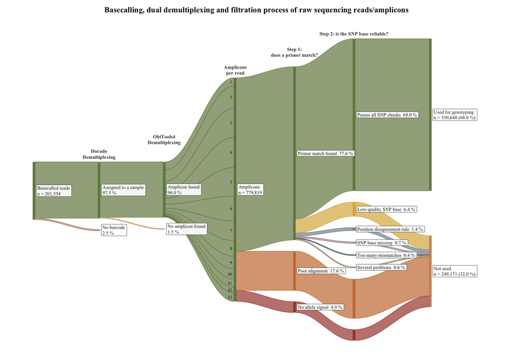

```r
# every flow as one smooth band: top and bottom edge follow an S-curve from the source bar to the destination bar
curve_steps <- seq(0, 1, length.out = 80)
curve_shape <- (1 - cos(pi * curve_steps)) / 2 # smooth S-curve from 0 to 1
sankey_flow_shapes <- bind_rows(lapply(seq_len(nrow(sankey_flows)), function(i) {
  f <- sankey_flows[i, ]
  x <- f$sx + node_width + (f$dx - f$sx - node_width) * curve_steps
  top <- f$s0 + (f$d0 - f$s0) * curve_shape
  bottom <- (f$s0 + f$ns) + ((f$d0 + f$nd) - (f$s0 + f$ns)) * curve_shape
  tibble(flow = f$flow, fill = sankey_all_colours[[f$colour_key]], is_strand = !is.na(f$strand), x = c(x, rev(x)), y = c(top, rev(bottom)))
}))

sankey_strand_labels <- filter(sankey_flows, !is.na(strand)) %>% # amplicons per read, at the wide end of the fan
  mutate(y = d0 + nd / 2, label = sub("strand_", "", strand))

# column titles just above the top bar of each column
sankey_column_top <- function(x) min(sankey_nodes$ymin[sankey_nodes$x == x])
sankey_column_titles <- tibble(x = c(sankey_column_x[c(2, 3, 5, 6)] + node_width / 2, (sankey_column_x[3] + sankey_column_x[4] + 1) / 2 + 0.15),
                               y = sapply(sankey_column_x[c(2, 3, 5, 6, 4)], sankey_column_top) - node_gap * c(0.3, 1.6, 0.9, 0.3, 0.3),
                               label = c("Dorado\nDemultiplexing", "ObiTools4\nDemultiplexing", "Step 1:\ndoes a primer match?",
                                         "Step 2: is the SNP base reliable?", "Amplicons\nper read"))

p_sankey <- ggplot() +
   geom_polygon(data = sankey_flow_shapes, aes(x, y, group = flow, fill = fill, colour = fill), alpha = 0.7, linewidth = 0.3) +
  geom_polygon(data = filter(sankey_flow_shapes, is_strand), aes(x, y, group = flow), fill = NA, colour = correct_colour, linewidth = 0.3) + # fan strands outlined
  geom_rect(data = sankey_nodes, aes(xmin = x, xmax = x + node_width, ymin = ymin, ymax = ymax, fill = sankey_all_colours[node])) + # the bars
  geom_label(data = filter(sankey_nodes, !carried), aes(x = x + node_width + 0.02, y = (ymin + ymax) / 2, label = label),
             hjust = 0, size = 2.8, lineheight = 0.95, colour = "grey10", fill = "white", alpha = 0.9, linewidth = 0.2, label.r = unit(0.12, "lines")) +
  geom_text(data = sankey_strand_labels, aes(x = sankey_column_x[4] - 0.03, y = y, label = label), hjust = 1, size = 2.6, colour = "#3b3a36") +
  geom_text(data = sankey_strand_labels, aes(x = sankey_column_x[4] - 0.03, y = y, label = label), hjust = 1, size = 2.3, colour = "#3b3a36") +
  geom_text(data = sankey_column_titles, aes(x, y, label = label), vjust = 0, fontface = "bold", size = 2.9, colour = "#3b3a36", lineheight = 0.95) +
  scale_fill_identity() +
  scale_colour_identity() +
  scale_y_reverse() +
  coord_cartesian(xlim = c(-0.05, 7.95), clip = "off") +
  labs(title = "Basecalling, dual demultiplexing and filtration process of raw sequencing reads/amplicons") +
  theme_void(base_family = plot_font, base_size = 10) +
  theme(plot.title = element_text(face = "bold", size = 13, hjust = 0.5, margin = margin(b = 10)), plot.margin = margin(12, 12, 12, 12))

print(p_sankey)
```

```r
ggsave(file.path(out_dir_sankey, "read_sankey.png"), p_sankey, width = 11.69, height = 8.27, dpi = 300, bg = "white")
ggsave(file.path(out_dir_sankey, "read_sankey.pdf"), p_sankey, width = 11.69, height = 8.27, device = cairo_pdf)


# 2. Plot, outcome of reads per locus and statisctics

# calucaltes homopolymers per locus, rle() and run rep() write each "attggggc" into 1 2 4 1
hp_run_lengths_f <- function(sequence) {
  runs <- rle(strsplit(sequence, "")[[1]])
  rep(runs$lengths, runs$lengths)
}

# per locus, the worst case over its two ASP primers (+ anchor, as the read sees it)
locus_homopolymers <- bind_rows(lapply(seq_len(nrow(panel)), function(i) {
  anchor <- toupper(ifelse(is.na(panel$anchor[i]), "", panel$anchor[i]))
  bind_rows(lapply(toupper(c(panel$asp1_seq[i], panel$asp2_seq[i])), function(asp) {
    snp <- nchar(asp) # position of the SNP base
    run_at <- hp_run_lengths_f(paste0(asp, anchor))
    tibble(locus = panel$locus[i], primer_len = snp,
           hp_len_3p = max(run_at[intersect(snp + (-1:1), seq_along(run_at))]),  # homopolymer at snp
           hp_len_primer = max(run_at[seq_len(min(snp + 1, length(run_at)))])) # longest run anywhere
  }))
})) %>%
  summarise(primer_len = max(primer_len), hp_len_3p = max(hp_len_3p), hp_len_primer = max(hp_len_primer), .by = locus)

# Data prep, per locus indels, mismatches, fate shares
# indels and mismatches are counted on raw-call reads only, on poor alignments the indel count is the failure
locus_summary <- final_reads %>%
  group_by(locus) %>%
  summarise(n_reads = n(),
            n_raw = sum(!is.na(called_allele_raw)),
            indel_raw = mean(winning_indel_events[!is.na(called_allele_raw)], na.rm = TRUE),
            mm_raw = mean(winning_nmismatch[!is.na(called_allele_raw)], na.rm = TRUE),
            used = mean(!is.na(called_allele)),
            poor = mean(below_threshold_flag),
            tie = mean(tie_flag),
            .groups = "drop") %>%
  left_join(locus_homopolymers, by = "locus") %>%
  mutate(indel_per_base = indel_raw / primer_len)
stopifnot("loci in the reads table missing from panel" = !anyNA(locus_summary$primer_len))

kable(arrange(locus_summary, indel_raw) %>% select(locus, n_reads, indel_raw, mm_raw, used, poor, tie, primer_len), digits = 3,
      col.names = c("Locus", "Reads", "Indel rate", "Mismatch rate", "Used", "Poor alignment", "Tie", "Primer length"))
```

| Locus | Reads | Indel rate | Mismatch rate | Used | Poor alignment | Tie | Primer length |
| --- | --- | --- | --- | --- | --- | --- | --- |
| BICF2S23758182 | 31916 | 0.084 | 0.262 | 0.812 | 0.056 | 0.016 | 8 |
| BICF2P1262794 | 27013 | 0.091 | 0.211 | 0.784 | 0.042 | 0.017 | 7 |
| BICF2S22912279 | 8923 | 0.099 | 0.297 | 0.711 | 0.139 | 0.019 | 15 |
| BICF2S2305942 | 32752 | 0.099 | 0.215 | 0.796 | 0.079 | 0.035 | 14 |
| BICF2G630126293 | 21008 | 0.126 | 0.304 | 0.713 | 0.136 | 0.037 | 15 |
| BICF2P223300 | 18032 | 0.137 | 0.234 | 0.710 | 0.108 | 0.092 | 15 |
| BICF2P1165732 | 49663 | 0.151 | 0.274 | 0.726 | 0.132 | 0.040 | 14 |
| BICF2P57528 | 19481 | 0.151 | 0.234 | 0.781 | 0.119 | 0.011 | 14 |
| BICF2P400484 | 10844 | 0.162 | 0.225 | 0.736 | 0.116 | 0.030 | 14 |
| BICF2P239653 | 8844 | 0.163 | 0.397 | 0.682 | 0.203 | 0.029 | 19 |
| BICF2P363248 | 14678 | 0.163 | 0.195 | 0.754 | 0.146 | 0.020 | 14 |
| BICF2S23626182 | 59768 | 0.166 | 0.255 | 0.673 | 0.186 | 0.058 | 15 |
| BICF2S23219794 | 10708 | 0.167 | 0.235 | 0.704 | 0.110 | 0.052 | 16 |
| BICF2P1060759 | 15659 | 0.170 | 0.295 | 0.658 | 0.171 | 0.052 | 13 |
| BICF2P878735 | 8079 | 0.186 | 0.308 | 0.718 | 0.183 | 0.013 | 17 |
| BICF2G630320565 | 33377 | 0.186 | 0.319 | 0.671 | 0.178 | 0.051 | 17 |
| BICF2G630340139 | 9130 | 0.188 | 0.365 | 0.481 | 0.336 | 0.125 | 21 |
| BICF2P866415 | 16229 | 0.188 | 0.416 | 0.678 | 0.133 | 0.048 | 21 |
| BICF2P153324 | 7016 | 0.190 | 0.198 | 0.707 | 0.122 | 0.074 | 16 |
| BICF2G630165989 | 52339 | 0.191 | 0.338 | 0.697 | 0.209 | 0.017 | 14 |
| BICF2P285168 | 11066 | 0.200 | 0.313 | 0.630 | 0.180 | 0.102 | 20 |
| BICF2S23033793 | 19261 | 0.208 | 0.305 | 0.654 | 0.148 | 0.124 | 19 |
| BICF2S23225775 | 12320 | 0.219 | 0.278 | 0.667 | 0.225 | 0.017 | 17 |
| BICF2G630128194 | 24052 | 0.220 | 0.363 | 0.674 | 0.186 | 0.036 | 20 |
| BICF2S23526960 | 46161 | 0.227 | 0.362 | 0.666 | 0.217 | 0.037 | 19 |
| TIGRP2P116705_rs8955982 | 23604 | 0.227 | 0.298 | 0.432 | 0.206 | 0.279 | 18 |
| BICF2P1138616 | 14669 | 0.231 | 0.388 | 0.644 | 0.217 | 0.022 | 20 |
| BICF2P1448058 | 33871 | 0.236 | 0.310 | 0.548 | 0.307 | 0.046 | 19 |
| TIGRP2P247920_rs8757526 | 37697 | 0.241 | 0.377 | 0.663 | 0.220 | 0.032 | 21 |
| BICF2G630276750 | 9005 | 0.242 | 0.378 | 0.616 | 0.258 | 0.037 | 19 |
| BICF2G630409723 | 44529 | 0.242 | 0.335 | 0.644 | 0.249 | 0.037 | 17 |
| BICF2G630703836 | 35934 | 0.246 | 0.387 | 0.674 | 0.183 | 0.053 | 21 |
| BICF2G630580879 | 12191 | 0.297 | 0.568 | 0.617 | 0.251 | 0.036 | 25 |

```r
kable(count(filter(final_reads, !is.na(called_allele_raw)), winning_indel_events))# indels per passing read
```

| winning_indel_events | n |
| --- | --- |
| 0 | 495209 |
| 1 | 109622 |

```r
# Statistic tests, Spearman correlations across loci (Holm-adjusted over all tests)
correlation_pairs <- tribble(
  ~x, ~y,
  "hp_len_3p", "indel_raw",
  "hp_len_primer", "indel_raw",
  "hp_len_primer", "indel_per_base",
  "primer_len", "indel_raw",
  "indel_raw", "used",
  "indel_raw", "poor",
  "mm_raw", "used",
  "hp_len_3p", "tie",
  "hp_len_primer", "tie",
  "hp_len_3p", "used",
  "hp_len_primer", "used")

correlations <- bind_rows(Map(function(x, y) {
  test <- suppressWarnings(cor.test(locus_summary[[x]], locus_summary[[y]], method = "spearman", exact = FALSE)) # ties: no exact p
  tibble(x = x, y = y, n = sum(complete.cases(locus_summary[[x]], locus_summary[[y]])),
         rho = unname(test$estimate), p = test$p.value)}, correlation_pairs$x, correlation_pairs$y)) %>%
  mutate(p_holm = p.adjust(p, "holm"))

kable(correlations, digits = 3, col.names = c("x", "y", "Loci", "Spearman rho", "p", "p (Holm)"))
```

| x | y | Loci | Spearman rho | p | p (Holm) |
| --- | --- | --- | --- | --- | --- |
| hp_len_3p | indel_raw | 33 | -0.075 | 0.677 | 1.000 |
| hp_len_primer | indel_raw | 33 | 0.204 | 0.256 | 0.895 |
| hp_len_primer | indel_per_base | 33 | -0.031 | 0.863 | 1.000 |
| primer_len | indel_raw | 33 | 0.764 | 0.000 | 0.000 |
| indel_raw | used | 33 | -0.803 | 0.000 | 0.000 |
| indel_raw | poor | 33 | 0.792 | 0.000 | 0.000 |
| mm_raw | used | 33 | -0.630 | 0.000 | 0.001 |
| hp_len_3p | tie | 33 | 0.486 | 0.004 | 0.029 |
| hp_len_primer | tie | 33 | 0.275 | 0.121 | 0.604 |
| hp_len_3p | used | 33 | -0.218 | 0.224 | 0.895 |
| hp_len_primer | used | 33 | -0.327 | 0.063 | 0.378 |

```r
write_tsv(correlations, file.path(out_dir_sankey, "locus_spearman_correlations.tsv"))
write_tsv(locus_summary, file.path(out_dir_sankey, "locus_indel_homopolymer_summary.tsv"))

spearman_label <- function(x_name, y_name) { # "Spearman rho = -0.83, Holm p < 0.001, n = 33"
  result <- filter(correlations, x == x_name, y == y_name)
  stopifnot(nrow(result) == 1)
  p_text <- if (result$p_holm < 0.001) "< 0.001" else paste("=", format(signif(result$p_holm, 2)))
  sprintf("Spearman \u03c1 = %.2f, Holm p %s, n = %d", result$rho, p_text, result$n)
}

# Indel groups and plot data
indel_group_breaks <- quantile(locus_summary$indel_raw, c(1/3, 2/3))
indel_group_names <- c("Low indel rate", "Medium indel rate", "High indel rate") # top to bottom
indel_group_colours <- setNames(c("#E1C473", "#C3722A", "#834D24"), indel_group_names)
homopolymer_legend <- "Homopolymer \u22655 nt in primer" # diamond show homopolymers
locus_label_colour <- "grey10"
banner_fill <- "grey88"
banner_text_colour <- "grey15"
legend_gap <- unit(14, "pt") # one gap for every legend entry
row_padding <- expansion(add = 0.5)
short_locus_name <- function(locus) sub("_rs\\d+$", "", locus) # shortens TIGRP2P116705_rs8955982 to TIGRP2P116705, spacing issues

# one row per locus, indel group, diamond, row label in order and the bar-text shares
locus_info <- final_reads %>%
  summarise(bar_used = mean(short == sankey_used_label), bar_poor = mean(short == label_poor_alignment), .by = locus) %>% # % written on the bars
  left_join(locus_summary, by = "locus") %>%
  mutate(indel_group = cut(indel_raw, c(-Inf, indel_group_breaks, Inf), labels = indel_group_names),
         has_homopolymer = hp_len_primer >= 5,
         point_shape = ifelse(has_homopolymer, 18, 16), # diamond or circle
         label = formatC(short_locus_name(locus), width = max(nchar(short_locus_name(locus))), flag = "-"))

locus_info$label <- factor(locus_info$label, levels = arrange(locus_info, bar_used, locus)$label) # rows sorted by share used, lowest at the bottom

indel_group_headers <- final_reads %>% # banner text per group (read-weighted % used)
  left_join(select(locus_info, locus, indel_group), by = "locus") %>%
  summarise(used = mean(!is.na(called_allele)), .by = indel_group) %>%
  left_join(summarise(locus_info, lowest = min(indel_raw), highest = max(indel_raw), .by = indel_group), by = "indel_group") %>%
  arrange(indel_group) %>%
  mutate(header = sprintf("%s\n%.2f\u2013%.2f indels/read \u00b7 %s used", indel_group, lowest, highest, percent(used, accuracy = 1)))
kable(select(indel_group_headers, -header), digits = 3)
```

| indel_group | used | lowest | highest |
| --- | --- | --- | --- |
| Low indel rate | 0.755 | 0.084 | 0.163 |
| Medium indel rate | 0.670 | 0.166 | 0.208 |
| High indel rate | 0.627 | 0.219 | 0.297 |

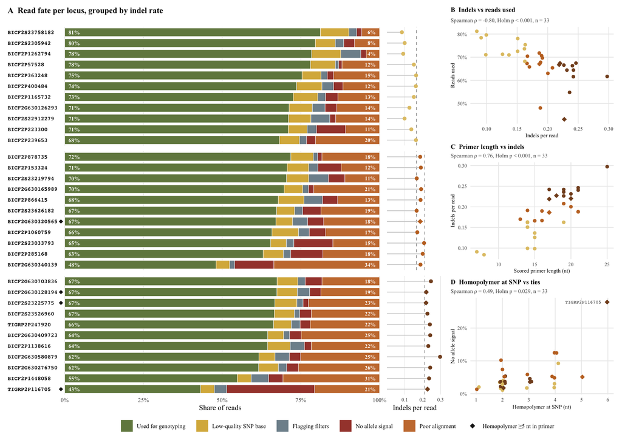

```r
# share of each bar category per locus, with the locus's row label and group
locus_bars <- final_reads %>%
  count(locus, short) %>%
  complete(locus, short = bar_order, fill = list(n = 0)) %>%
  mutate(share = n / sum(n), .by = locus) %>%
  left_join(select(locus_info, locus, label, indel_group), by = "locus") %>%
  mutate(short = factor(short, levels = rev(bar_order))) # rev: Used left, Poor right

indel_group_facets <- facet_grid(indel_group ~ ., scales = "free_y", space = "free_y")
facet_theme <- theme(strip.text = element_blank(), strip.background = element_blank(),
                          panel.spacing.y = unit(8, "pt"))

## Panels
# group banner text, placed at the middle locus of each group
banner_labels <- locus_info %>%
  arrange(bar_used, locus) %>%
  slice(ceiling(n() / 2), .by = indel_group) %>%
  left_join(select(indel_group_headers, indel_group, header), by = "indel_group")

p_banner <- ggplot(locus_info, aes(x = 1, y = label)) +
  geom_tile(fill = banner_fill, width = 1, height = 1) +
  geom_text(data = banner_labels, aes(label = header),
            angle = 90, size = 2.5, fontface = "bold", lineheight = 0.95, colour = banner_text_colour) +
  indel_group_facets +
  scale_x_continuous(expand = c(0, 0)) +
  scale_y_discrete(expand = row_padding) +
  theme_void(base_family = plot_font) +
  facet_theme

# Plot A: read outcome bars
p_bars <- ggplot(locus_bars, aes(x = share, y = label, fill = short)) +
  geom_col(width = 0.78, colour = "white", linewidth = 0.25) +
  geom_text(data = locus_info, aes(x = 0.012, y = label, label = percent(bar_used, accuracy = 1)),
            inherit.aes = FALSE, hjust = 0, colour = "white", size = 2.7, fontface = "bold") +
  geom_text(data = filter(locus_info, bar_poor >= 0.035), aes(x = 0.988, y = label, label = percent(bar_poor, accuracy = 1)),
            inherit.aes = FALSE, hjust = 1, colour = "white", size = 2.6, fontface = "bold") +
  geom_point(data = filter(locus_info, has_homopolymer), aes(x = -0.012, y = label, shape = homopolymer_legend),
             inherit.aes = FALSE, size = 2.4, colour = locus_label_colour) +
  coord_cartesian(clip = "off") +
  indel_group_facets +
  scale_y_discrete(expand = row_padding) +
  scale_x_continuous(labels = percent, breaks = seq(0, 1, 0.25), expand = c(0, 0)) +
  scale_fill_manual(values = bar_colours, breaks = bar_order, name = NULL) +
  scale_shape_manual(values = setNames(18, homopolymer_legend), name = NULL) +
  guides(fill = guide_legend(nrow = 1, order = 1),
         shape = guide_legend(order = 2, override.aes = list(alpha = 1, size = 3, colour = locus_label_colour))) +
  labs(title = "A  Read fate per locus, grouped by indel rate", x = "Share of reads", y = NULL) +
  sankey_theme +
  facet_theme +
  theme(axis.text.y = element_text(family = "mono", face = "bold", size = 7.5, colour = locus_label_colour, margin = margin(r = 12)),
        panel.grid.major.y = element_blank(),
        plot.title = element_text(face = "bold", size = 11, hjust = 0),
        plot.title.position = "plot")

# indels per read (part of A): dashed group boundaries and grid lines drawn per group
indel_group_boundaries <- tibble(indel_group = factor(indel_group_names[c(1, 2, 2, 3)], levels = indel_group_names),
                                      x = unname(indel_group_breaks[c(1, 1, 2, 2)])) # low: upper bound, medium: both, high: lower bound
indel_grid_lines <- tibble(indel_group = factor(c(indel_group_names, indel_group_names[3]), levels = indel_group_names),
                                x = c(0.1, 0.1, 0.1, 0.3))
indel_axis_max <- ceiling(max(locus_info$indel_raw) * 10) / 10

p_indels <- ggplot(locus_info, aes(x = indel_raw, y = label)) +
  geom_vline(data = indel_grid_lines, aes(xintercept = x), colour = "grey90", linewidth = 0.3) +
  geom_vline(data = indel_group_boundaries, aes(xintercept = x), linetype = "dashed", colour = "grey60", linewidth = 0.4) +
  geom_segment(aes(x = 0, xend = indel_raw, yend = label), colour = "grey82", linewidth = 0.5) +
geom_point(aes(colour = indel_group, shape = point_shape, size = ifelse(has_homopolymer, 3.0, 2.2))) +
  indel_group_facets +
  scale_y_discrete(expand = row_padding) +
  scale_colour_manual(values = indel_group_colours, guide = "none") +
  scale_shape_identity() +
  scale_size_identity() +
  scale_x_continuous(limits = c(0, indel_axis_max), breaks = seq(0.1, indel_axis_max, 0.1),
                     labels = label_number(accuracy = 0.1), expand = expansion(mult = c(0, 0.04))) +
  labs(x = "Indels per read", y = NULL) +
  sankey_theme +
  facet_theme +
  theme(axis.text.y = element_blank(),
        axis.text.x = element_text(size = 7),
        panel.grid.major.y = element_blank(),
        panel.grid.major.x = element_blank(), # replaced by the per-group grid lines
        panel.grid.minor.x = element_blank())

# Plots B-D: statistics, same colours and shapes as the indel dots
stats_theme <- sankey_theme +
  theme(plot.title = element_text(face = "bold", size = 9, hjust = 0),
        plot.subtitle = element_text(size = 7.5, colour = "grey35", hjust = 0),
        axis.title = element_text(size = 7.5),
        axis.text = element_text(size = 7),
        plot.margin = margin(4, 6, 4, 6))
stats_point_layers <- list(scale_colour_manual(values = indel_group_colours, guide = "none"),
                                scale_shape_identity(), scale_size_identity(), stats_theme)

p_stats_used <- ggplot(locus_info, aes(indel_raw, used)) +
  geom_point(aes(colour = indel_group, shape = point_shape, size = ifelse(has_homopolymer, 2.8, 2.0))) +
  scale_y_continuous(labels = percent) +
  labs(title = "B  Indels vs reads used", subtitle = spearman_label("indel_raw", "used"),
       x = "Indels per read", y = "Reads used") +
  stats_point_layers

p_stats_length <- ggplot(locus_info, aes(primer_len, indel_raw)) +
  geom_point(aes(colour = indel_group, shape = point_shape, size = ifelse(has_homopolymer, 2.8, 2.0))) +
  labs(title = "C  Primer length vs indels", subtitle = spearman_label("primer_len", "indel_raw"),
       x = "Scored primer length (nt)", y = "Indels per read") +
  stats_point_layers

p_stats_tie <- ggplot(locus_info, aes(hp_len_3p, tie)) +
  geom_point(aes(colour = indel_group, shape = point_shape, size = ifelse(has_homopolymer, 2.8, 2.0)),
             position = position_jitter(width = 0.12, height = 0, seed = 1)) +
  geom_text(data = filter(locus_info, tie > 0.2), aes(label = short_locus_name(locus)),
            size = 2.2, hjust = 1, nudge_x = -0.25, colour = "grey30", family = "mono") +
  scale_x_continuous(breaks = seq(1, max(locus_info$hp_len_3p))) +
  scale_y_continuous(labels = percent) +
  labs(title = "D  Homopolymer at SNP vs ties", subtitle = spearman_label("hp_len_3p", "tie"),
       x = "Homopolymer at SNP (nt)", y = "No allele signal") +
  stats_point_layers

p_locus_indel <- wrap_plots(# p_banner, # grey group banners left out
                                            p_bars, p_indels,
                                            wrap_plots(p_stats_used, p_stats_length, p_stats_tie, ncol = 1),
                                            nrow = 1, widths = c(8, 1.4, 3.6), guides = "collect") &
  theme(legend.position = "bottom",
        legend.box = "horizontal",
        legend.margin = margin(0, 0, 0, 0),
        legend.spacing.x = legend_gap,
        legend.key.spacing.x = legend_gap)

print(p_locus_indel)
```

```r
ggsave(file.path(out_dir_sankey, "read_by_locus_indel_groups.png"), p_locus_indel, width = 11.69, height = 8.27, dpi = 300, bg = "white")
ggsave(file.path(out_dir_sankey, "read_by_locus_indel_groups.pdf"), p_locus_indel, width = 11.69, height = 8.27, device = cairo_pdf)
```

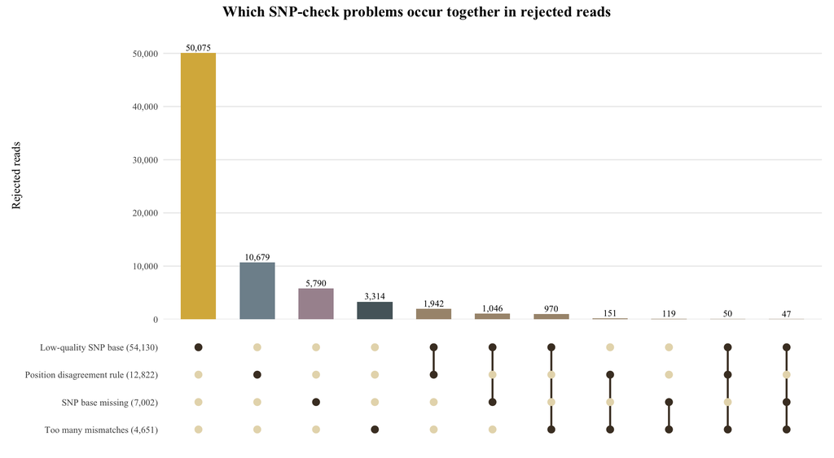

```r
### 3. Plot UpSet shows which porblems appear together
rejected_flags <- final_reads %>%
  filter(step1 == label_primer_match, fate != sankey_used_label) %>% # matched reads rejected in step 2
  select(all_of(names(flag_labels))) %>%
  rename_with(~ flag_labels[.x])
problem_totals <- sort(colSums(rejected_flags), decreasing = TRUE)
problems <- names(problem_totals)[problem_totals > 0] # problems that never occur are left out

# true or false one row per exact combination of problems, most frequent first
problem_combinations <- rejected_flags %>%
  count(across(all_of(problems)), sort = TRUE) %>%
  mutate(combination = apply(pick(all_of(problems)), 1, function(row) paste(problems[row], collapse = " + ")), # bar name, e.g. "A + B"
         n_problems = rowSums(pick(all_of(problems))),
         fill_colour = ifelse(n_problems == 1, outcome_colours[combination], outcome_colours[[label_several]]),
         combination = factor(combination, levels = combination))
stopifnot(sum(problem_combinations$n) == nrow(rejected_flags), !anyNA(problem_combinations$fill_colour))

# row labels with the total per problem
problem_labels <- setNames(sprintf("%s (%s)", problems, comma(problem_totals[problems])), problems)

# dot matrix: which problems each combination contains based on true or false columns
problem_matrix <- problem_combinations %>%
  select(combination, all_of(problems)) %>%
  pivot_longer(-combination, names_to = "problem", values_to = "member") %>%
  mutate(problem = factor(problem, levels = rev(problems)))

p_upset_bars <- ggplot(problem_combinations, aes(x = combination, y = n, fill = fill_colour)) +
  geom_col(width = 0.6) +
  geom_text(aes(label = comma(n)), vjust = -0.4, size = 2.8) +
  scale_fill_identity() +
  scale_y_continuous(labels = comma, expand = expansion(mult = c(0, 0.08))) +
  labs(x = NULL, y = "Rejected reads") +
  sankey_theme +
  theme(axis.text.x = element_blank(), panel.grid.major.x = element_blank())

p_upset_matrix <- ggplot(problem_matrix, aes(x = combination, y = problem)) +
  geom_line(data = filter(problem_matrix, member), aes(group = combination), linewidth = 0.8, colour = "#4A3B2C") +
  geom_point(aes(colour = member), size = 2.6) +
  scale_colour_manual(values = c(`TRUE` = "#4A3B2C", `FALSE` = "#E6DAB9"), guide = "none") +
  scale_y_discrete(labels = problem_labels) +
  labs(x = NULL, y = NULL) +
  sankey_theme +
  theme(axis.text.x = element_blank(), panel.grid = element_blank())

p_upset <- wrap_plots(p_upset_bars, p_upset_matrix, ncol = 1, heights = c(3, 1.2)) +
  plot_annotation(title = "Which SNP-check problems occur together in rejected reads",
                  theme = theme(plot.title = element_text(face = "bold", size = 13, hjust = 0.5)))

print(p_upset)
```

```r
ggsave(file.path(out_dir_sankey, "read_problems_upset.png"), p_upset, width = 10, height = 5.5, dpi = 300, bg = "white")
ggsave(file.path(out_dir_sankey, "read_problems_upset.pdf"), p_upset, width = 10, height = 5.5, device = cairo_pdf)
```

**Settings used for this run**

| Setting | Value |
| --- | --- |
| run_date | 2026-10-31 16:25 |
| dataset_name | big |
| n_barcodes | 24 |
| primer_panel_path | Data/Supporting_data/Primer_panels/12864_2021_7761_MOESM12_ESM_filtered.xlsx |
| reference_path | Data/Supporting_data/Genome_reference_data/snps_500bp_sequences.fa |
| HT_min_frequence | 0.2 |
| min_snp_quality | 10 |
| n_cores | 4 |
| input_type | unpadded |
| use_anchors | TRUE |
| anchor_length | 3 |
| probe_type | asp_primers |
| threshold_type | errors |
| min_score_fraction | 0.65 |
| error_rate | 0.08 |
| ngsfilter_path | Data/Supporting_data/NGSfilter_file/ngsfilter.csv |
| primer_quality | 19 |
| gap_opening | 6 |
| gap_extension | 2 |
| min_errors | 1 |
| max_mismatches | 2 |
| prior_type | ancestry |
| prior_het_share | 0.15 |
| prior_population | FreqWOLF_all |
| prior_floor | 0.001 |
| ancestry_prior_shape | 1 |
| phi_hom_structure | shared |
| run_basic_plots | TRUE |
| run_filtration_parameters | TRUE |
| run_speedopt_diagnosis | TRUE |
| run_filtration_vis | TRUE |